# AIGC 标识治理项目：实验复现与结论总览

### 6.5 2026 新生成器持续学习、三域路由与证据衰减

#### 6.5.1 为什么继续扩充数据

上一节已经证明：在 Community Forensics 域内表现很好的模型，面对 NTIRE 2026 等新分布会出现严重误报。这一轮继续加入 [**AIGenImages2026**](https://huggingface.co/datasets/pthan12/AIGenImages2026)，目的不是简单增加样本数，而是补入 2025 年前后的 19 类较新生成器，并用成对真实图检验时间迁移能力。该数据集对应的[持续适配研究](https://arxiv.org/abs/2605.02567)也明确把新生成器分布漂移和灾难性遗忘作为核心问题。

数据集卡报告 5,439 张生成图。本项目固定下载修订版 `073e1924d9d0d85ac97a53b07947b6ac95ce241c` 后，对压缩包逐文件审计，本地可用清单为 **10,876 张**，其中生成图 **5,438 张**、真实对照图 **5,438 张**。报告中的统计以可复核的本地 manifest 为准，并保留版本差异说明。

这批数据只进入“是否为 AI 生成图”的二分类实验。它带有生成器模型标签，但没有“从文心一言、通义千问、即梦 AI、智谱 GLM-Image 网页端原生下载”的可靠平台链路标签，因此**不能直接替代四平台归因训练集**。

```python
import json
audit = json.loads((ROOT / "outputs/reports/aigenimages2026_manifest_v1/audit.json").read_text(encoding="utf-8"))
for key in ["rows", "generated_rows", "real_rows", "generator_count", "explicit_validation_pairs", "missing_path_count"]:
    print(f"{key}: {audit[key]}")
print("revision: 073e1924d9d0d85ac97a53b07947b6ac95ce241c")
```

[output not shown]

#### 6.5.2 数据血缘、无泄漏切分与配对控制

官方训练池先按标签分层切成 90% 适配训练集和 10% 内部验证集。官方 `val` 中 559 组真实图与生成图配对样本只在所有模型、阈值和路由策略确定后使用一次。这样可以区分“在新数据上拟合得好”与“对未参与决策的数据仍然有效”。

清单还记录图像路径、真实或生成标签、生成器、提示词、配对 ID、相似度、来源日期、格式和文件大小。没有缺失路径、重复样本 ID 或未登记文件。

```python
protocol = pd.DataFrame([
    {"数据区": "内部适配训练集", "真实图": 4391, "生成图": 4391, "总量": 8782, "是否参与拟合": "是", "作用": "训练 AIGen 专家"},
    {"数据区": "内部适配验证集", "真实图": 488, "生成图": 488, "总量": 976, "是否参与拟合": "否", "作用": "模型选择与阈值校准"},
    {"数据区": "官方独立验证集", "真实图": 559, "生成图": 559, "总量": 1118, "是否参与拟合": "否", "作用": "一次性外部评估"},
])
protocol
```

| 数据区 | 真实图 | 生成图 | 总量 | 是否参与拟合 | 作用 |
| --- | --- | --- | --- | --- | --- |
| 内部适配训练集 | 4391 | 4391 | 8782 | 是 | 训练 AIGen 专家 |
| 内部适配验证集 | 488 | 488 | 976 | 否 | 模型选择与阈值校准 |
| 官方独立验证集 | 559 | 559 | 1118 | 否 | 一次性外部评估 |

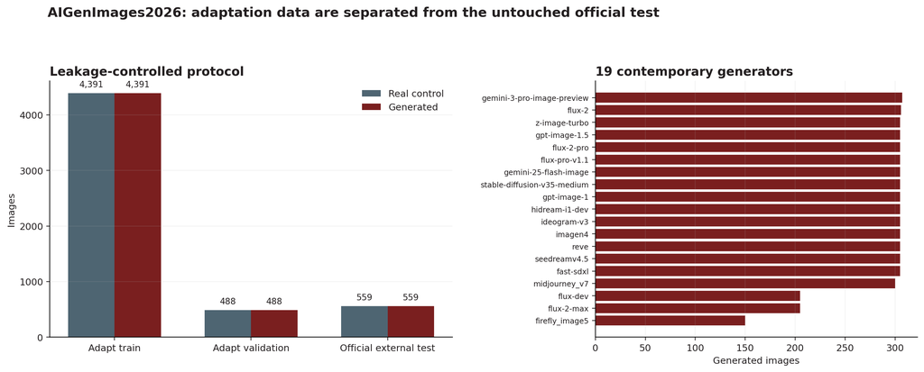

```python
from IPython.display import Image, display
display(Image(filename='outputs/figures/continual_detection_v1/aigenimages2026_protocol.png', width=1100))
```

#### 6.5.3 从单一分类器升级为三域专家系统

本轮没有把所有数据直接混在一起重训一个分类器，而是保留三个用途不同的专家：

1. **Community 源域专家**：保持原有未见生成器测试优势，防止新域适配造成灾难性遗忘。
2. **NTIRE 适配专家**：针对 NTIRE 标准域和困难域的误报问题。
3. **AIGen2026 专家**：在 8,782 张内部训练样本上训练 CLIP 线性探针，在 976 张内部验证样本上选择正则化、类别权重和保守阈值；最终模型为 `aigen_clip_c0.001_targetw8`，阈值为 0.875。

路由器使用 64 维文件与基础视觉特征判断样本更接近哪个采集域，再调用对应专家。候选包括 ExtraTrees 与 HistGradientBoosting，最终选择 `three_domain_hgb`。路由特征只能解释“采集域和导出链差异”，不能被解释为真实性证明。

```python
router = pd.read_csv(ROOT / "outputs/tables/three_domain_router_candidates_v1.csv")
router[["model_id", "selected", "valid_balanced_accuracy", "valid_source_recall", "valid_ntire_recall", "valid_aigen_recall", "valid_source_special_misroute"]].round(4)
```

| model_id | selected | valid_balanced_accuracy | valid_source_recall | valid_ntire_recall | valid_aigen_recall | valid_source_special_misroute |
| --- | --- | --- | --- | --- | --- | --- |
| three_domain_extra_trees_leaf1 | False | 0.9184 | 0.9838 | 0.934 | 0.8375 | 0.0162 |
| three_domain_extra_trees_leaf3 | False | 0.9112 | 0.9825 | 0.920 | 0.8312 | 0.0175 |
| three_domain_hgb | True | 0.9383 | 0.9775 | 0.955 | 0.8825 | 0.0225 |

```python
routes = pd.read_csv(ROOT / "outputs/tables/three_domain_route_candidates_v1.csv")
routes[["method_id", "selected", "validation_min_balanced_accuracy", "validation_average_balanced_accuracy", "validation_max_real_fpr", "selection_score"]].round(4)
```

| method_id | selected | validation_min_balanced_accuracy | validation_average_balanced_accuracy | validation_max_real_fpr | selection_score |
| --- | --- | --- | --- | --- | --- |
| base_only | False | 0.5195 | 0.6750 | 0.9590 | -0.1020 |
| ntire_only | False | 0.7110 | 0.7212 | 0.2418 | 0.8298 |
| aigen_only | False | 0.5180 | 0.6802 | 0.0800 | 0.7781 |
| three_domain_hard_route | True | 0.7040 | 0.8498 | 0.0880 | 1.0409 |

#### 6.5.4 标准判定结果：扩容有效，但没有通吃所有分布

三域路由在 AIGenImages2026 官方独立测试上的平衡准确率为 **0.8309**，真实图误报率为 **0.0948**，优于直接使用旧源域专家；在 Community 未见生成器测试上仍保持 **0.9856** 的平衡准确率和 **0.0044** 的真实图误报率。与此同时，NTIRE 标准域平衡准确率为 **0.6881**，SafeIMG 单类生成图召回率只有 **0.3775**。这说明新增专家缓解了部分域偏移，但“未知数据究竟属于哪个域”仍然是核心难题。

逐生成器结果也并不均匀：`gpt-image-1` 召回率为 1.000，而 `hidream-i1-dev` 只有约 0.419。总平均数不能替代按生成器拆分的误差审计。

```python
metrics = pd.read_csv(ROOT / "outputs/tables/three_domain_moe_scope_metrics_v1.csv")
metrics[metrics["eval_scope"].isin([
    "community_generator_holdout_test", "ntire_standard_adapt_test", "ntire_hard_external_test",
    "aigen2026_official_external_test", "qwen_unseen_generator_test", "safeimg_external_test",
])][["method_id", "eval_scope", "n", "balanced_accuracy", "recall_generated", "real_false_positive_rate", "roc_auc"]].round(4)
```

| 方法 | 测试范围 | 样本数 | 平衡准确率 | 生成图召回率 | 真实图误报率 | ROC AUC |
| --- | --- | --- | --- | --- | --- | --- |
| Community 源域专家 | NTIRE 标准独立测试 | 7000 | 0.5161 | 0.9671 | 0.9349 | 0.6223 |
| NTIRE 适配专家 | NTIRE 标准独立测试 | 7000 | 0.6986 | 0.4943 | 0.0971 | 0.8259 |
| AIGen2026 专家 | NTIRE 标准独立测试 | 7000 | 0.5231 | 0.1237 | 0.0774 | 0.5793 |
| 三域硬路由 | NTIRE 标准独立测试 | 7000 | 0.6881 | 0.4694 | 0.0931 | 0.8115 |
| Community 源域专家 | NTIRE 困难独立测试 | 2500 | 0.5164 | 0.9632 | 0.9304 | 0.5871 |
| NTIRE 适配专家 | NTIRE 困难独立测试 | 2500 | 0.6344 | 0.4200 | 0.1512 | 0.7195 |
| AIGen2026 专家 | NTIRE 困难独立测试 | 2500 | 0.5224 | 0.1136 | 0.0688 | 0.5747 |
| 三域硬路由 | NTIRE 困难独立测试 | 2500 | 0.6232 | 0.3872 | 0.1408 | 0.6985 |
| Community 源域专家 | Community 未见生成器 | 1433 | 0.9706 | 0.9756 | 0.0344 | 0.9950 |
| NTIRE 适配专家 | Community 未见生成器 | 1433 | 0.7488 | 0.5009 | 0.0033 | 0.9535 |
| AIGen2026 专家 | Community 未见生成器 | 1433 | 0.6700 | 0.3433 | 0.0033 | 0.9623 |
| 三域硬路由 | Community 未见生成器 | 1433 | 0.9856 | 0.9756 | 0.0044 | 0.9979 |
| Community 源域专家 | Qwen 未见版本，仅生成图 | 4000 | NaN | 0.9975 | NaN | NaN |
| NTIRE 适配专家 | Qwen 未见版本，仅生成图 | 4000 | NaN | 0.8390 | NaN | NaN |
| AIGen2026 专家 | Qwen 未见版本，仅生成图 | 4000 | NaN | 0.7890 | NaN | NaN |
| 三域硬路由 | Qwen 未见版本，仅生成图 | 4000 | NaN | 0.9398 | NaN | NaN |
| Community 源域专家 | SafeIMG 外部集，仅生成图 | 1131 | NaN | 0.9956 | NaN | NaN |
| NTIRE 适配专家 | SafeIMG 外部集，仅生成图 | 1131 | NaN | 0.5411 | NaN | NaN |
| AIGen2026 专家 | SafeIMG 外部集，仅生成图 | 1131 | NaN | 0.3775 | NaN | NaN |
| 三域硬路由 | SafeIMG 外部集，仅生成图 | 1131 | NaN | 0.3775 | NaN | NaN |
| Community 源域专家 | AIGen2026 官方独立测试 | 1118 | 0.5385 | 1.0000 | 0.9231 | 0.9106 |
| NTIRE 适配专家 | AIGen2026 官方独立测试 | 1118 | 0.8283 | 0.7871 | 0.1306 | 0.9127 |
| AIGen2026 专家 | AIGen2026 官方独立测试 | 1118 | 0.7952 | 0.6726 | 0.0823 | 0.9005 |
| 三域硬路由 | AIGen2026 官方独立测试 | 1118 | 0.8309 | 0.7567 | 0.0948 | 0.9105 |

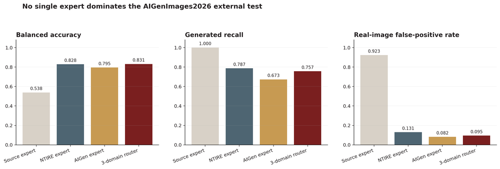

```python
from IPython.display import Image, display
display(Image(filename='outputs/figures/continual_detection_v1/aigen_expert_comparison.png', width=1100))
```

```python
per_generator = pd.read_csv(ROOT / "outputs/tables/aigen2026_per_generator_metrics_v1.csv")
per_generator.sort_values("recall_generated").round(4)
```

| 生成器 | 官方测试样本数 | 生成图召回率 |
| --- | --- | --- |
| hidream-i1-dev | 31 | 0.4194 |
| flux-pro-v1.1 | 31 | 0.4516 |
| stable-diffusion-v35-medium | 31 | 0.6129 |
| fast-sdxl | 31 | 0.6452 |
| flux-dev | 23 | 0.6522 |
| midjourney_v7 | 31 | 0.7097 |
| gemini-3-pro-image-preview | 31 | 0.7097 |
| seedreamv4.5 | 31 | 0.7419 |
| imagen4 | 31 | 0.7419 |
| z-image-turbo | 31 | 0.7419 |
| reve | 31 | 0.8065 |
| flux-2-pro | 31 | 0.8387 |
| flux-2 | 31 | 0.8387 |
| ideogram-v3 | 31 | 0.8710 |
| gemini-25-flash-image | 31 | 0.8710 |
| flux-2-max | 23 | 0.9130 |
| firefly_image5 | 17 | 0.9412 |
| gpt-image-1.5 | 31 | 0.9677 |
| gpt-image-1 | 31 | 1.0000 |

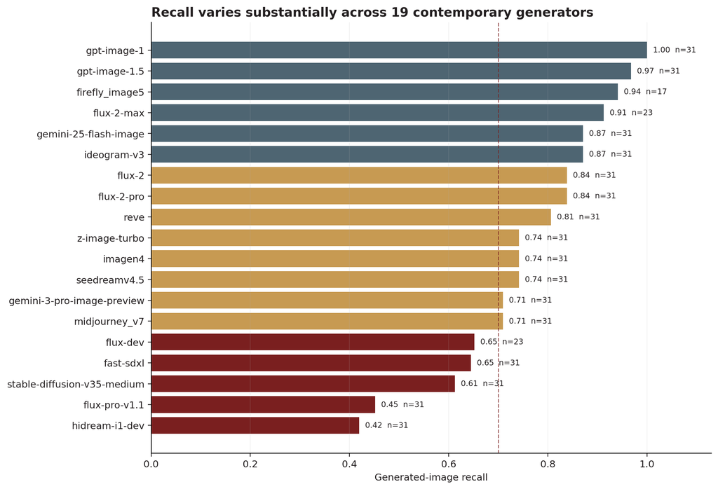

```python
from IPython.display import Image, display
display(Image(filename='outputs/figures/continual_detection_v1/aigen_per_generator_recall.png', width=1100))
```

#### 6.5.5 拒判和人工复核：把覆盖率纳入模型目标

网页不应强迫模型对每张图都给出肯定结论。本轮在内部验证集上选择类别概率边距 `0.275` 作为自动判定门槛，低边距样本进入人工复核，不使用官方独立测试调参。

在 AIGenImages2026 官方独立测试上，自动覆盖率为 **75.13%**，自动部分平衡准确率提高到 **0.8946**，真实图误报率降到 **0.0403**；在 NTIRE 标准域上，自动覆盖率为 **63.94%**，真实图误报率从 **0.0931** 降到 **0.0324**。这不是“删除难样本后虚报准确率”，而是明确报告自动判定与人工复核的任务分工。

```python
selective = pd.read_csv(ROOT / "outputs/tables/three_domain_moe_selective_metrics_v1.csv")
selective[(selective["method_id"] == "three_domain_hard_route_validation_selected") & selective["eval_scope"].isin([
    "community_generator_holdout_test", "ntire_standard_adapt_test", "ntire_hard_external_test", "aigen2026_official_external_test",
])][["eval_scope", "n", "auto_count", "review_count", "auto_coverage", "auto_balanced_accuracy", "auto_recall_generated", "auto_real_false_positive_rate", "auto_roc_auc"]].round(4)
```

| 测试范围 | 总样本 | 自动判定 | 转人工复核 | 自动覆盖率 | 自动部分平衡准确率 | 自动部分生成图召回率 | 自动部分真实图误报率 | 自动部分 ROC AUC |
| --- | --- | --- | --- | --- | --- | --- | --- | --- |
| NTIRE 标准独立测试 | 7000 | 4476 | 2524 | 0.6394 | 0.7023 | 0.4371 | 0.0324 | 0.8178 |
| NTIRE 困难独立测试 | 2500 | 1578 | 922 | 0.6312 | 0.6298 | 0.3227 | 0.0631 | 0.6979 |
| Community 未见生成器 | 1433 | 1389 | 44 | 0.9693 | 0.9942 | 0.9884 | 0.0000 | 0.9984 |
| AIGen2026 官方独立测试 | 1118 | 840 | 278 | 0.7513 | 0.8946 | 0.8295 | 0.0403 | 0.9326 |

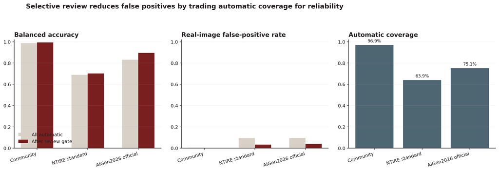

```python
from IPython.display import Image, display
display(Image(filename='outputs/figures/continual_detection_v1/selective_review_tradeoff.png', width=1100))
```

#### 6.5.6 文件层留痕为何很强，又为何不能被滥用

对 AIGenImages2026 的原生文件做消融后，文件加视觉的 64 维 HGB 在官方独立测试上达到 **0.9812** 的平衡准确率，文件元数据 13 维版本也达到 **0.9803**，而只保留 51 维基础视觉统计量时只有 **0.5259**。置换重要度最高的是长宽比、原始宽度、信息键数量和文件大小。

这组高分主要说明真实图和生成图的**采集或导出流程可分**，不能直接解释为模型看懂了画面中的生成痕迹。使用同一个模型和同一个阈值，对官方测试图统一转成 JPEG Q90 后，平衡准确率降到 **0.7379**、真实图误报率升到 **0.4025**；模拟截图式 PNG 后，平衡准确率为 **0.7764**、真实图误报率为 **0.4454**。因此文件层必须作为原生文件证据分支，与内容模型并列，而不是替代内容模型。

```python
ablation = pd.read_csv(ROOT / "outputs/tables/aigen_file_expert_feature_ablation_v1.csv")
ablation[["feature_mode", "feature_count", "official_test_balanced_accuracy", "official_test_recall_generated", "official_test_real_false_positive_rate", "official_test_roc_auc"]].round(4)
```

| 特征版本 | 特征数 | 平衡准确率 | 生成图召回率 | 真实图误报率 | ROC AUC |
| --- | --- | --- | --- | --- | --- |
| full_file_plus_visual | 64 | 0.9812 | 0.9982 | 0.0358 | 0.9948 |
| file_metadata_only | 13 | 0.9803 | 0.9982 | 0.0376 | 0.9945 |
| visual_statistics_only | 51 | 0.5259 | 0.0626 | 0.0107 | 0.7250 |

```python
robustness = pd.read_csv(ROOT / "outputs/tables/aigen_file_expert_robustness_v1.csv")
robustness[["condition", "n", "balanced_accuracy", "recall_generated", "real_false_positive_rate", "roc_auc", "expected_calibration_error_10bin"]].round(4)
```

| 文件条件 | 样本数 | 平衡准确率 | 生成图召回率 | 真实图误报率 | ROC AUC | 校准误差 ECE |
| --- | --- | --- | --- | --- | --- | --- |
| original_native_files | 1118 | 0.9812 | 0.9982 | 0.0358 | 0.9948 | 0.0301 |
| jpeg_q90 | 1118 | 0.7379 | 0.8784 | 0.4025 | 0.9026 | 0.2747 |
| png_screenshot_like | 1118 | 0.7764 | 0.9982 | 0.4454 | 0.9483 | 0.2242 |

```python
importance = pd.read_csv(ROOT / "outputs/tables/aigen_file_expert_importance_v1.csv")
importance.head(12).round(6)
```

| 排名 | 字段 | 置换重要度均值 | 置换重要度标准差 |
| --- | --- | --- | --- |
| 1 | aspect_ratio | 0.199411 | 0.006659 |
| 2 | orig_width | 0.061988 | 0.005249 |
| 3 | info_key_count | 0.058402 | 0.005541 |
| 4 | file_size_kb | 0.042392 | 0.004284 |
| 5 | megapixels | 0.005251 | 0.001807 |
| 6 | is_png | 0.000768 | 0.000444 |
| 7 | gray_p90 | 0.000000 | 0.000000 |
| 8 | edge_mean | 0.000000 | 0.000000 |
| 9 | edge_std | 0.000000 | 0.000000 |
| 10 | laplacian_var | 0.000000 | 0.000000 |
| 11 | high_freq_ratio | 0.000000 | 0.000000 |
| 12 | gray_p10 | 0.000000 | 0.000000 |

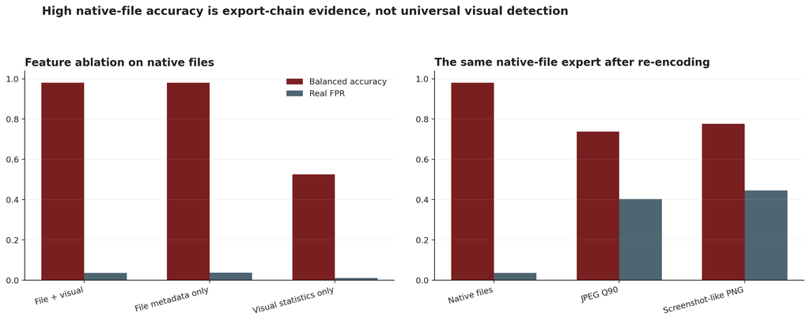

```python
from IPython.display import Image, display
display(Image(filename='outputs/figures/continual_detection_v1/file_evidence_ablation_and_robustness.png', width=1100))
```

#### 6.5.7 负结果和未采用策略

本项目保留未采用实验，是为了避免只展示最优数字。下表中的四项都改变了后续设计：语义嵌入不适合单独做采集域路由；专家分歧不一定意味着剩余自动样本更可靠；简单视觉统计量不足以识别现代生成器；原生文件专家不能直接迁移到截图。

```python
negative_results = pd.read_csv(ROOT / "outputs/tables/continual_detection_negative_results_v1.csv")
negative_results
```

| 实验 | 观察 | 处置 | 原因 |
| --- | --- | --- | --- |
| 仅用 CLIP 嵌入做域路由 | 验证集平衡准确率约 0.820，源域误路由率约 0.141 | 未采用，改用 64 维文件与基础视觉特征路由 | 语义内容不足以稳定识别采集域 |
| 遇到专家分歧就转人工 | SafeIMG 剩余自动样本召回率提高，但覆盖率仅约 0.133 | 仅保留为诊断，不作为网页默认规则 | AIGen 与 NTIRE 的筛选后真实图误报率反而变差 |
| 视觉统计特征单独检测 AIGen2026 | 官方测试平衡准确率 0.526，生成图召回率 0.063 | 不作为独立检测器 | 简单统计量无法表示当代生成器的内容伪影 |
| 原生文件专家直接用于截图和转码图 | 真实图误报率升至 0.403 和 0.445 | 只标记为原生导出证据路径 | 重编码重写格式、尺寸、文件大小和信息区字段 |

#### 6.5.8 还能从哪些方向识别 AI 图像

当前系统已经覆盖文件留痕、CLIP 和 DINOv2 内容表征、域路由、开放集门控和人工复核，但仍缺少对生成机制本身的多种独立证据。下一轮不应只换一个更大的分类器，而应并行验证邻域像素关系、扩散重建误差、频域伪影、多模态解释、来源凭证和开放集持续学习。

这些方法必须使用相同的数据协议评估：按生成器留出、按数据集外测、按时间留出，并对 JPEG、缩放、裁剪、截图和社交平台重编码分别报告性能。只有在不同路径的证据相互独立且经过校准后，后融合才可能真正提高稳健性。

参考方向包括：[CVPR 2024 的 NPR](https://openaccess.thecvf.com/content/CVPR2024/html/Tan_Rethinking_the_Up-Sampling_Operations_in_CNN-based_Generative_Network_for_Generalizable_CVPR_2024_paper.html)、[CVPR 2024 的 FatFormer](https://openaccess.thecvf.com/content/CVPR2024/html/Liu_Forgery-aware_Adaptive_Transformer_for_Generalizable_Synthetic_Image_Detection_CVPR_2024_paper.html)、[ICCV 2023 的 DIRE](https://openaccess.thecvf.com/content/ICCV2023/html/Wang_DIRE_for_Diffusion-Generated_Image_Detection_ICCV_2023_paper.html)、[ICCV 2025 的 AIGI-Holmes](https://openaccess.thecvf.com/content/ICCV2025/html/Zhou_AIGI-Holmes_Towards_Explainable_and_Generalizable_AI-Generated_Image_Detection_via_Multimodal_ICCV_2025_paper.html)，以及内容凭证和鲁棒水印验证。它们目前是**下一阶段研究方案**，不是已完成结果。

```python
future_methods = pd.read_csv(ROOT / "outputs/tables/continual_detection_future_methods_v1.csv")
future_methods
```

| 方向 | 核心信号 | 计划实验 | 价值 | 风险 |
| --- | --- | --- | --- | --- |
| 邻域像素关系 NPR | 卷积生成网络上采样造成的局部像素依赖 | 加入无元数据残差分支，与 CLIP 和 DINOv2 做后融合 | 减少对语义内容与 EXIF 的依赖 | 对非 CNN 与后处理图像需重新验证 |
| 扩散重建误差 DIRE | 真实图与扩散图在预训练扩散模型重建误差上的差异 | 在官方独立测试和截图压力集上提取重建残差 | 提供生成机制层证据 | 计算开销高，依赖重建模型匹配度 |
| 频率感知 Transformer | 空间域与频域异常联合建模 | 复现 FatFormer 类分支并做未见生成器测试 | 覆盖纹理和频谱伪影 | 数据域偏差仍可能被模型学习 |
| 多模态可解释检测 | 视觉证据、文字解释与定位区域联合输出 | 参考 AIGI-Holmes 增加证据定位和自然语言解释 | 便于人工复核和治理沟通 | 解释可能合理但不忠实，必须做忠实度评估 |
| 来源凭证与水印验证 | C2PA 签名、内容凭证、鲁棒水印与平台声明 | 把存在性和验签结果作为独立证据，不与分类概率混写 | 从事后猜测转向可验证来源链 | 缺失凭证不等于伪造，截图后信号可能丢失 |
| 开放集与持续学习 | 路由置信度、专家分歧、时间外测试与未知域检测 | 按月份建立冻结盲测集，复核样本进入版本化再训练队列 | 应对生成模型快速迭代 | 必须防止测试集回流和灾难性遗忘 |

#### 6.5.9 面向真实落地的下一代证据系统

最终平台应从“上传一张图，输出一个概率”升级为七层证据系统。不同证据必须分栏呈现，并给出适用条件、阈值版本和失效风险。没有来源凭证不能推断为 AI，文件留痕消失也不能推断为真实，单个分类器概率更不能单独承担定责功能。

```python
future_architecture = pd.read_csv(ROOT / "outputs/tables/continual_detection_future_architecture_v1.csv")
future_architecture
```

| 层级 | 模块 | 输入 | 输出 | 定位 |
| --- | --- | --- | --- | --- |
| 1 | 来源凭证核验 | C2PA、签名、水印、平台声明 | 可验证、缺失或验签失败 | 高可信显式证据 |
| 2 | 原生文件取证 | 格式、尺寸、EXIF、info_keys、编码特征 | 导出链一致性与来源线索 | 原生文件优先 |
| 3 | 稳健内容检测 | CLIP、DINOv2、NPR、频域、DIRE | 多个独立内容分数 | 截图和转码后的主路径 |
| 4 | 域识别与专家路由 | 文件条件、内容域、路由置信度 | 专家选择或未知域 | 避免单模型覆盖所有域 |
| 5 | 校准与拒判 | 概率、边距、专家分歧、OOD 分数 | 自动判定或人工复核 | 控制误报与覆盖率 |
| 6 | 解释与证据报告 | 字段、模型贡献、转换敏感性 | 可核验报告与限制说明 | 服务治理而非单独定责 |
| 7 | 持续评估 | 新生成器、时间外样本、复核反馈 | 版本化模型卡和回归报告 | 形成长期实验室能力 |

#### 6.5.10 复现命令与产物

```
python scripts/231_download_aigenimages2026_v1.py
python scripts/233_prepare_aigenimages2026_v1.py
python scripts/220_extract_clip_binary_embeddings_v1.py --manifest data/processed/experiment_tables/aigenimages2026_manifest_v1.csv --out-dir outputs/features/clip_aigenimages2026_v1 --index-path outputs/tables/clip_aigenimages2026_manifest_v1.csv
python scripts/218_extract_modern_detection_features_v1.py --manifest data/processed/experiment_tables/aigenimages2026_manifest_v1.csv --output data/processed/features/aigenimages2026_enhanced_meta_features_v1.csv --include-all
python scripts/235_train_three_domain_moe_v1.py
python scripts/236_train_aigen_file_expert_v1.py
python scripts/237_build_continual_detection_figures_v1.py
python scripts/238_update_notebook_continual_detection_v1.py
```

核心模型、预测和摘要位于 `outputs/reports/three_domain_moe_v1/` 与 `outputs/reports/aigen_file_expert_v1/`，结构化指标位于 `outputs/tables/three_domain_*_v1.csv`、`outputs/tables/aigen2026_*_v1.csv` 和 `outputs/tables/aigen_file_expert_*_v1.csv`。

#### 6.5.11 NPR 低层痕迹实验：从零样本到第二意见通道

前一节提出要从生成机制方向补充证据，本节将其真正落实为可复现实验。NPR（Neighboring Pixel Relationships）不读取 EXIF、PNG 信息键或平台名称，而是先对相邻像素的上采样关系做残差变换，再由轻量卷积骨干提取低层生成痕迹。该方向来自 [CVPR 2024 论文](https://openaccess.thecvf.com/content/CVPR2024/html/Tan_Rethinking_the_Up-Sampling_Operations_in_CNN-based_Generative_Network_for_Generalizable_CVPR_2024_paper.html)，代码与权重取自[作者公开仓库](https://github.com/chuangchuangtan/NPR-DeepfakeDetection)。

本节回答四个问题：官方权重能否直接迁移；只重训决策头能否改善跨域性能；NPR 能否补足现有模型对未知生成器的漏检；经过 JPEG、缩放和重编码后，低层痕迹还能保留多少。实验固定上游提交 `781ced3f7ca2cdc69ec9dd4ef27e8d0b3c07752a`，主权重 SHA-256 为 `3939297e9399e0b992f87211610769d87d899de50d56da0204d6cbda2d483a53`。

##### 6.5.11.1 数据协议与无泄漏边界

沿用 Community、Legacy、NTIRE 与 AIGenImages2026 的既有协议。训练集用于拟合新决策头，验证集用于选择样本权重、正则强度、分类阈值和复核策略；18,206 张原始图测试集与 2,236 张重编码压力集均不参与任何参数选择。四个数据区共处理 **47,167 个图像输入**，冻结骨干输出 512 维向量并做 L2 归一化。

```python
import json
import pandas as pd

npr_embedding_meta = json.loads((ROOT / "outputs/features/npr_official_embeddings_v1/metadata.json").read_text(encoding="utf-8"))
npr_official_summary = json.loads((ROOT / "outputs/reports/official_npr_v1/summary.json").read_text(encoding="utf-8"))
npr_transfer_summary = json.loads((ROOT / "outputs/reports/npr_transfer_head_v1/summary.json").read_text(encoding="utf-8"))
npr_review_summary = json.loads((ROOT / "outputs/reports/npr_transfer_review_guard_v1/summary.json").read_text(encoding="utf-8"))
npr_transfer_metrics_raw = pd.read_csv(ROOT / "outputs/tables/npr_transfer_test_scope_metrics_v1.csv")
npr_stress_raw = pd.read_csv(ROOT / "outputs/tables/npr_transfer_stress_scope_metrics_v1.csv")
npr_review_policies_raw = pd.read_csv(ROOT / "outputs/tables/npr_transfer_review_selected_policies_v1.csv")
npr_review_test_raw = pd.read_csv(ROOT / "outputs/tables/npr_transfer_review_test_metrics_v1.csv")
npr_head_candidates_raw = pd.read_csv(ROOT / "outputs/tables/npr_transfer_head_validation_candidates_v1.csv")

_npr_split_rows = {item["split"]: item["rows"] for item in npr_embedding_meta["outputs"]}
npr_protocol_v1 = pd.DataFrame([
    {"数据区": "迁移训练集", "样本数": _npr_split_rows["train"], "用途": "拟合新线性头", "参与选模": "是"},
    {"数据区": "内部验证集", "样本数": _npr_split_rows["valid"], "用途": "正则、权重、阈值与复核策略选择", "参与选模": "是"},
    {"数据区": "原始图独立测试集", "样本数": _npr_split_rows["test"], "用途": "一次性外测", "参与选模": "否"},
    {"数据区": "重编码压力集", "样本数": _npr_split_rows["stress"], "用途": "JPEG 与缩放传播鲁棒性", "参与选模": "否"},
])

_npr_official_metrics = pd.DataFrame(npr_official_summary["test_scope_metrics"])
official_npr_zero_shot_metrics = _npr_official_metrics[
    _npr_official_metrics["policy_id"].eq("validation_selected_global_threshold")
    & _npr_official_metrics["eval_scope"].isin([
        "community_generator_holdout_test", "ntire_standard_adapt_test",
        "ntire_hard_external_test", "aigen2026_official_external_test",
        "qwen_unseen_generator_test", "safeimg_external_test",
    ])
][["eval_scope", "n", "balanced_accuracy", "recall_generated", "real_false_positive_rate", "roc_auc"]].round(4)

_npr_selected_head = npr_transfer_summary["selected_head"]
npr_transfer_candidate_audit = pd.DataFrame([
    {"检查项": "冻结表征维度", "结果": npr_embedding_meta["dimension"], "说明": "NPR 骨干全局平均池化后 L2 归一化"},
    {"检查项": "头模型候选数", "结果": int(npr_head_candidates_raw[["weight_strategy", "regularization_c"]].drop_duplicates().shape[0]), "说明": "3 种权重方案 × 4 个 C"},
    {"检查项": "阈值候选数", "结果": int(npr_head_candidates_raw["threshold"].nunique()), "说明": "仅用验证集搜索"},
    {"检查项": "最终样本权重", "结果": _npr_selected_head["weight_strategy"], "说明": "域与类别双平衡"},
    {"检查项": "最终正则强度 C", "结果": _npr_selected_head["regularization_c"], "说明": "逻辑回归"},
    {"检查项": "最终阈值", "结果": _npr_selected_head["threshold"], "说明": "测试集未参与选择"},
])

_npr_method_names = {
    "three_domain_baseline": "现有三域模型",
    "validation_selected_npr_transfer_head": "NPR 冻结骨干+迁移头",
    "validation_selected_baseline_npr_head_fusion": "验证集选择的概率融合",
}
_npr_scope_names = {
    "community_generator_holdout_test": "Community 未见生成器",
    "ntire_standard_adapt_test": "NTIRE 标准测试",
    "ntire_hard_external_test": "NTIRE 困难外测",
    "aigen2026_official_external_test": "AIGenImages2026 官方外测",
    "qwen_unseen_generator_test": "Qwen 未见生成器",
    "safeimg_external_test": "SafeIMG 外部生成集",
}
def _npr_metric_view(scopes):
    view = npr_transfer_metrics_raw[npr_transfer_metrics_raw["eval_scope"].isin(scopes)].copy()
    view["方法"] = view["method_id"].map(_npr_method_names)
    view["测试范围"] = view["eval_scope"].map(_npr_scope_names)
    return view[["方法", "测试范围", "n", "balanced_accuracy", "recall_generated", "real_false_positive_rate", "roc_auc"]].rename(columns={
        "n": "样本数", "balanced_accuracy": "平衡准确率", "recall_generated": "生成图召回率",
        "real_false_positive_rate": "真实图误报率", "roc_auc": "ROC AUC",
    }).round(4)

npr_transfer_cross_domain_metrics = _npr_metric_view([
    "community_generator_holdout_test", "ntire_standard_adapt_test",
    "ntire_hard_external_test", "aigen2026_official_external_test",
])
npr_unknown_generator_metrics = _npr_metric_view(["qwen_unseen_generator_test", "safeimg_external_test"])

_npr_stress_columns = ["eval_scope", "n", "balanced_accuracy", "recall_generated", "real_false_positive_rate", "roc_auc"]
_npr_stress_rename = {
    "eval_scope": "压力条件", "n": "样本数", "balanced_accuracy": "平衡准确率",
    "recall_generated": "生成图召回率", "real_false_positive_rate": "真实图误报率", "roc_auc": "ROC AUC",
}
_npr_original = npr_transfer_metrics_raw[
    npr_transfer_metrics_raw["method_id"].eq("validation_selected_npr_transfer_head")
    & npr_transfer_metrics_raw["eval_scope"].eq("aigen2026_official_external_test")
][_npr_stress_columns].rename(columns=_npr_stress_rename).round(4)
npr_reencoding_stress_metrics = pd.concat([
    _npr_original,
    npr_stress_raw[_npr_stress_columns].rename(columns=_npr_stress_rename).round(4),
], ignore_index=True)

npr_review_guard_validation_policies = npr_review_policies_raw[[
    "real_review_cap", "threshold", "max_real_incremental_review_rate",
    "total_generated_false_negative_rescue_rate", "incremental_review_count",
]].rename(columns={
    "real_review_cap": "验证集真实图复核上限", "threshold": "NPR 复核阈值",
    "max_real_incremental_review_rate": "实际最高新增真实图复核率",
    "total_generated_false_negative_rescue_rate": "验证集漏检转复核率", "incremental_review_count": "新增复核数",
}).round(4)
_npr_review_names = {
    "community_generator_holdout_test": "Community", "aigen2026_official_external_test": "AIGen2026",
    "ntire_standard_adapt_test": "NTIRE 标准", "ntire_hard_external_test": "NTIRE 困难",
    "qwen_unseen_generator_test": "Qwen", "safeimg_external_test": "SafeIMG",
}
_npr_review_selected = npr_review_test_raw[
    npr_review_test_raw["policy_id"].eq("npr_transfer_review_cap_03pct")
    & npr_review_test_raw["eval_scope"].isin(_npr_review_names)
].copy()
_npr_review_selected["测试范围"] = _npr_review_selected["eval_scope"].map(_npr_review_names)
npr_review_guard_test_metrics = _npr_review_selected[[
    "测试范围", "incremental_review_rate", "real_incremental_review_rate",
    "generated_false_negative_review_rate", "auto_coverage", "auto_balanced_accuracy",
]].rename(columns={
    "incremental_review_rate": "新增复核率", "real_incremental_review_rate": "真实图新增复核率",
    "generated_false_negative_review_rate": "漏检转复核率", "auto_coverage": "剩余自动覆盖率",
    "auto_balanced_accuracy": "自动部分平衡准确率",
}).round(4)

npr_reproduction_commands = "\n".join([
    "# PyTorch 2.9.1 environment: extract official NPR frozen embeddings",
    "/Library/Frameworks/Python.framework/Versions/3.12/bin/python3 scripts/241_extract_npr_embeddings_v1.py",
    "/Library/Frameworks/Python.framework/Versions/3.12/bin/python3 scripts/241_extract_npr_embeddings_v1.py --splits stress",
    "# Project environment: train the transfer head and evaluate the review guard",
    "./.venv/bin/python scripts/242_train_npr_transfer_head_v1.py",
    "./.venv/bin/python scripts/243_evaluate_npr_transfer_review_guard_v1.py",
    "./.venv/bin/python scripts/244_build_npr_transfer_figures_v1.py",
])
npr_protocol_v1
```

| 数据区 | 样本数 | 用途 | 参与选模 |
| --- | --- | --- | --- |
| 迁移训练集 | 22292 | 拟合新线性头 | 是 |
| 内部验证集 | 4433 | 正则、权重、阈值与复核策略选择 | 是 |
| 原始图独立测试集 | 18206 | 一次性外测 | 否 |
| 重编码压力集 | 2236 | JPEG 与缩放传播鲁棒性 | 否 |

##### 6.5.11.2 官方 NPR 零样本迁移不是即插即用

先在四个验证域上选择官方检查点与统一阈值，再一次性评估测试集。官方 NPR 在 SafeIMG 上表现出较高召回，但在 Community、Legacy 和 NTIRE 上存在严重域偏移：部分范围的 ROC AUC 接近或低于随机水平，真实图误报率最高接近一半。结论不是“NPR 无效”，而是原论文训练分布、输出尺度和本项目图像链路不同，不能直接把官方分数当作通用概率。

```python
official_npr_zero_shot_metrics
```

| eval_scope | n | balanced_accuracy | recall_generated | real_false_positive_rate | roc_auc |
| --- | --- | --- | --- | --- | --- |
| aigen2026_official_external_test | 1118 | 0.6834 | 0.7639 | 0.3971 | 0.7486 |
| community_generator_holdout_test | 1433 | 0.6551 | 0.7636 | 0.4533 | 0.7195 |
| ntire_hard_external_test | 2500 | 0.4872 | 0.1200 | 0.1456 | 0.4890 |
| ntire_standard_adapt_test | 7000 | 0.4717 | 0.0874 | 0.1440 | 0.4130 |
| qwen_unseen_generator_test | 4000 | NaN | 0.6645 | NaN | NaN |
| safeimg_external_test | 1131 | NaN | 0.8718 | NaN | NaN |

##### 6.5.11.3 冻结骨干迁移：只学习新的透明决策边界

选模分数为 `最差域平衡准确率 + 0.50×平均平衡准确率 - 0.35×最高真实图误报率 - 0.10×域间标准差`。最终选择域与类别双平衡、`C=1.0`、阈值 `0.585`。该目标明确惩罚最差域和真实图误报，不允许大数据域的高分掩盖小域失败。

```python
npr_transfer_candidate_audit
```

| 检查项 | 结果 | 说明 |
| --- | --- | --- |
| 冻结表征维度 | 512 | NPR 骨干全局平均池化后 L2 归一化 |
| 头模型候选数 | 12 | 3 种权重方案 × 4 个 C |
| 阈值候选数 | 182 | 仅用验证集搜索 |
| 最终样本权重 | domain_class_balanced | 域与类别双平衡 |
| 最终正则强度 C | 1.0 | 逻辑回归 |
| 最终阈值 | 0.585 | 测试集未参与选择 |

```python
npr_transfer_cross_domain_metrics
```

| 方法 | 测试范围 | 样本数 | 平衡准确率 | 生成图召回率 | 真实图误报率 | ROC AUC |
| --- | --- | --- | --- | --- | --- | --- |
| 现有三域模型 | AIGenImages2026 官方外测 | 1118 | 0.8309 | 0.7567 | 0.0948 | 0.9105 |
| 现有三域模型 | Community 未见生成器 | 1433 | 0.9856 | 0.9756 | 0.0044 | 0.9979 |
| 现有三域模型 | NTIRE 困难外测 | 2500 | 0.6232 | 0.3872 | 0.1408 | 0.6985 |
| 现有三域模型 | NTIRE 标准测试 | 7000 | 0.6881 | 0.4694 | 0.0931 | 0.8115 |
| NPR 冻结骨干+迁移头 | AIGenImages2026 官方外测 | 1118 | 0.7236 | 0.7728 | 0.3256 | 0.7968 |
| NPR 冻结骨干+迁移头 | Community 未见生成器 | 1433 | 0.8949 | 0.8687 | 0.0789 | 0.9650 |
| NPR 冻结骨干+迁移头 | NTIRE 困难外测 | 2500 | 0.5304 | 0.2944 | 0.2336 | 0.5415 |
| NPR 冻结骨干+迁移头 | NTIRE 标准测试 | 7000 | 0.5701 | 0.3686 | 0.2283 | 0.6190 |
| 验证集选择的概率融合 | AIGenImages2026 官方外测 | 1118 | 0.7979 | 0.6261 | 0.0304 | 0.9190 |
| 验证集选择的概率融合 | Community 未见生成器 | 1433 | 0.9812 | 0.9625 | 0.0000 | 0.9987 |
| 验证集选择的概率融合 | NTIRE 困难外测 | 2500 | 0.5656 | 0.1736 | 0.0424 | 0.6988 |
| 验证集选择的概率融合 | NTIRE 标准测试 | 7000 | 0.5999 | 0.2243 | 0.0246 | 0.8148 |

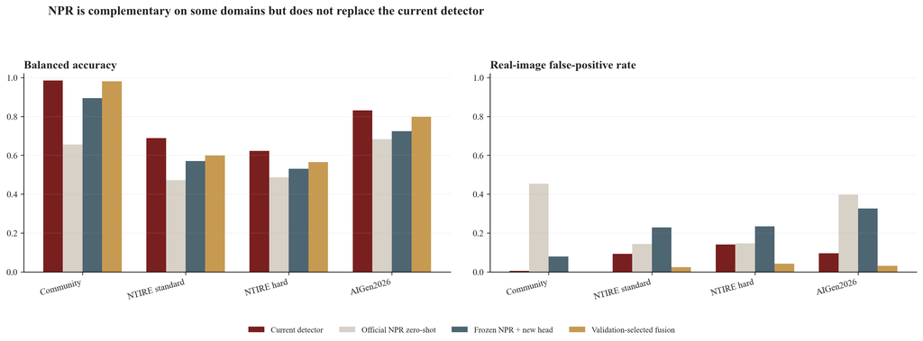

```python
from IPython.display import Image, display
display(Image(filename='outputs/figures/npr_transfer_v1/npr_cross_domain_comparison.png', width=1150))
```

##### 6.5.11.4 未知生成器揭示了互补价值，也否定了简单融合

SafeIMG 只有生成图，不能计算真实图误报率，因此这里只讨论召回而不宣称完整准确率。现有三域模型在 SafeIMG 上召回率为 0.3775；官方 NPR 零样本为 0.8718；重新训练的 NPR 迁移头为 0.8647。相反，验证集选择的概率融合只有 0.1671。这个反常结果说明两个模型的分数并不处于同一校准空间，线性混合会把互补信号抵消。NPR 的正确角色应是独立证据或分歧告警，而不是无条件平均概率。

```python
npr_unknown_generator_metrics
```

| 方法 | 测试范围 | 样本数 | 平衡准确率 | 生成图召回率 | 真实图误报率 | ROC AUC |
| --- | --- | --- | --- | --- | --- | --- |
| 现有三域模型 | Qwen 未见生成器 | 4000 | NaN | 0.9398 | NaN | NaN |
| 现有三域模型 | SafeIMG 外部生成集 | 1131 | NaN | 0.3775 | NaN | NaN |
| NPR 冻结骨干+迁移头 | Qwen 未见生成器 | 4000 | NaN | 0.7435 | NaN | NaN |
| NPR 冻结骨干+迁移头 | SafeIMG 外部生成集 | 1131 | NaN | 0.8647 | NaN | NaN |
| 验证集选择的概率融合 | Qwen 未见生成器 | 4000 | NaN | 0.8700 | NaN | NaN |
| 验证集选择的概率融合 | SafeIMG 外部生成集 | 1131 | NaN | 0.1671 | NaN | NaN |

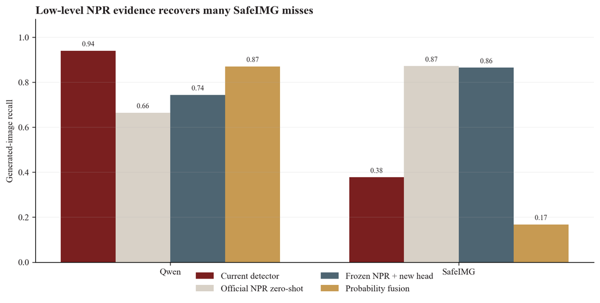

```python
from IPython.display import Image, display
display(Image(filename='outputs/figures/npr_transfer_v1/npr_unknown_generator_recall.png', width=980))
```

##### 6.5.11.5 传播压力测试：低层痕迹同样会衰减

迁移头与阈值在原图测试后保持冻结。AIGenImages2026 原始文件上的平衡准确率为 0.7236；JPEG Q90 后降到 0.5680；先缩放到 75% 再以 JPEG85 编码后为 0.5564。生成图召回率从 0.7728 分别降到 0.3560 和 0.2952。这说明 NPR 比文件元数据更接近图像内容，但仍不是不可破坏的稳定水印；插值和有损编码会改写邻域像素关系。

```python
npr_reencoding_stress_metrics
```

| 压力条件 | 样本数 | 平衡准确率 | 生成图召回率 | 真实图误报率 | ROC AUC |
| --- | --- | --- | --- | --- | --- |
| aigen2026_official_external_test | 1118 | 0.7236 | 0.7728 | 0.3256 | 0.7968 |
| aigen2026_jpeg_q90_stress_test | 1118 | 0.5680 | 0.3560 | 0.2200 | 0.6362 |
| aigen2026_resize75_jpeg85_stress_test | 1118 | 0.5564 | 0.2952 | 0.1825 | 0.6132 |

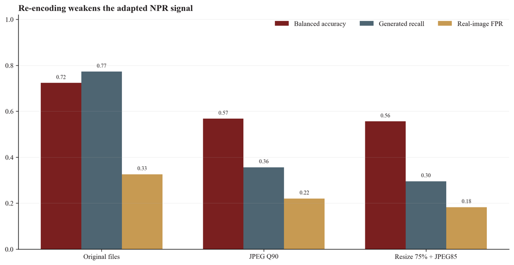

```python
from IPython.display import Image, display
display(Image(filename='outputs/figures/npr_transfer_v1/npr_reencoding_stress.png', width=1000))
```

##### 6.5.11.6 第二意见复核通道：不自动改判，只增加可审计的复核建议

为利用 SafeIMG 上的互补信号，同时避免 NPR 直接误伤真实图，本研究设计“分歧转复核”策略：只有当现有模型判为真实、样本尚未进入原复核队列，并且 NPR 概率超过阈值时，才新增人工复核。阈值仍只在四个验证域选择，并分别限制任一验证域真实图新增复核率不超过 1%、3% 或 5%。

3% 档最终阈值为 0.8343；验证集中实际最高真实图新增复核率为 2.6%，总体挽回 3.70% 的现有模型未复核漏检。该比例在常规域不高，但在 SafeIMG 独立生成集上可将 53.96% 的剩余漏检送入复核，证明它是有价值的异常告警信号。同时，SafeIMG 的剩余自动覆盖率仅 28.82%，且缺少配对真实图，因此不能把这一结果转成线上自动定责规则。

```python
npr_review_guard_validation_policies
```

| 验证集真实图复核上限 | NPR 复核阈值 | 实际最高新增真实图复核率 | 验证集漏检转复核率 | 新增复核数 |
| --- | --- | --- | --- | --- |
| 0.01 | 0.9291 | 0.008 | 0.0074 | 6.0 |
| 0.03 | 0.8343 | 0.026 | 0.0370 | 31.0 |
| 0.05 | 0.7107 | 0.048 | 0.0593 | 83.0 |

```python
npr_review_guard_test_metrics
```

| 测试范围 | 新增复核率 | 真实图新增复核率 | 漏检转复核率 | 剩余自动覆盖率 | 自动部分平衡准确率 |
| --- | --- | --- | --- | --- | --- |
| AIGen2026 | 0.0510 | 0.0716 | 0.2537 | 0.7004 | 0.9114 |
| Community | 0.0042 | 0.0056 | 0.1667 | 0.9651 | 0.9952 |
| NTIRE 困难 | 0.0252 | 0.0320 | 0.0491 | 0.6060 | 0.6339 |
| NTIRE 标准 | 0.0319 | 0.0383 | 0.0896 | 0.6076 | 0.7131 |
| Qwen | 0.0035 | NaN | 0.2333 | 0.8720 | NaN |
| SafeIMG | 0.1866 | NaN | 0.5396 | 0.2882 | NaN |

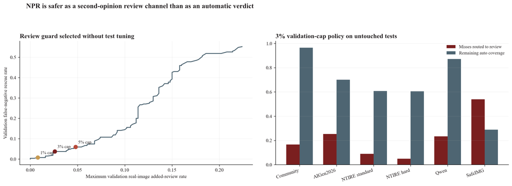

```python
from IPython.display import Image, display
display(Image(filename='outputs/figures/npr_transfer_v1/npr_review_guard_tradeoff.png', width=1150))
```

##### 6.5.11.7 研究结论、部署边界与后续方向

1. NPR 提供了与 CLIP 语义特征、视觉统计和文件元数据不同的低层证据，SafeIMG 结果证明这种互补性真实存在。
2. 冻结骨干后重训逻辑回归头可以修正部分阈值与数据域偏移，但不能解决所有跨域差异。
3. 简单概率融合不是多证据系统；当模型校准和域适用性不同，融合可能同时降低已知域准确率和未知域召回。
4. 当前最佳用途是“第二意见转复核”，而不是替换主模型或直接自动改判。
5. JPEG 和缩放会削弱 NPR 信号，未来应加入重编码增强，并进一步验证频域模型、扩散重建误差和来源凭证。
6. 作者仓库当前快照没有明确 `LICENSE` 文件。代码和权重仅保留为研究复现实验，未打包进公开网站，也未改变线上主模型。

因此，本轮的实质进展不是把网页数字做得更高，而是新增了一条独立技术路线，量化了它能补足什么、会在哪些条件下失效，并把可用价值收敛为有边界的治理策略。

```python
print(npr_reproduction_commands)
```

```
# PyTorch 2.9.1 environment: extract official NPR frozen embeddings
/Library/Frameworks/Python.framework/Versions/3.12/bin/python3 scripts/241_extract_npr_embeddings_v1.py
/Library/Frameworks/Python.framework/Versions/3.12/bin/python3 scripts/241_extract_npr_embeddings_v1.py --splits stress
# Project environment: train the transfer head and evaluate the review guard
./.venv/bin/python scripts/242_train_npr_transfer_head_v1.py
./.venv/bin/python scripts/243_evaluate_npr_transfer_review_guard_v1.py
./.venv/bin/python scripts/244_build_npr_transfer_figures_v1.py
```

## 7. 开放场景、阈值策略与治理队列

真实治理场景不能只追求单一 accuracy。原因是误报会影响正常用户，漏报会放过风险图片，而部分图片本身证据不足。因此项目进一步做了开放场景和三态治理策略：

- `generated`：高置信 AI 生成。
- `real`：高置信真实图。
- `uncertain_review`：证据不足，进入人工复核。

关键结论：

- 严格策略下 generated recall 会下降，但能把大量边界样本放入复核队列，降低误判风险。
- 对课程项目而言，这一点比单纯追求一个最高 accuracy 更有治理意义：系统要服务的是证据链和处置流程，而不是只给一个绝对判断。

```python
explain_csv_fields("outputs/tables/open_set_method_comparison_v1.csv")
print("\n结果表：开放场景方法比较")
show_csv("outputs/tables/open_set_method_comparison_v1.csv", n=20)
```

```
字段说明：outputs/tables/open_set_method_comparison_v1.csv

结果表：开放场景方法比较
```

|  | field | meaning |
| --- | --- | --- |
| 0 | method | 开放场景或治理策略名称。 |
| 1 | n_rows | 该方法评估的样本行数。 |
| 2 | generated_recall | AI 生成图被正确识别为 generated 的比例。 |
| 3 | real_recall | 真实图被正确识别为 real 的比例，用于衡量误伤控制能力。 |
| 4 | true_generated_pred_generated | 真实 generated 且预测为 generated 的数量。 |
| 5 | true_real_pred_real | 真实 real 且预测为 real 的数量。 |
| 6 | true_real_pred_generated | 真实 real 但被误报为 generated 的数量。 |

|  | method | n_rows | generated_recall | real_recall | true_generated_pred_generated | true_real_pred_real | true_real_pred_generated |
| --- | --- | --- | --- | --- | --- | --- | --- |
| 0 | rf_enhanced | 147 | 1.0 | 0.0 | 126 | 0 | 21 |
| 1 | rf_enhanced_meta | 141 | 1.0 | 0.0 | 120 | 0 | 21 |
| 2 | metadata_guardrail | 147 | 1.0 | 1.0 | 126 | 21 | 0 |
| 3 | hybrid_guardrail_rf_enhanced | 147 | 1.0 | 1.0 | 126 | 21 | 0 |

**结果说明：** 这张表比较不同开放场景方法在生成图召回和真实图保护之间的权衡。`generated_recall` 高表示抓得多，`real_recall` 高表示误伤少；`true_real_pred_generated` 是最需要控制的误报数量。

```python
explain_csv_fields("outputs/tables/operating_profile_frontier_v1.csv")
print("\n结果表：治理运行档位与阈值前沿")
show_csv("outputs/tables/operating_profile_frontier_v1.csv", n=20)
```

```
字段说明：outputs/tables/operating_profile_frontier_v1.csv

结果表：治理运行档位与阈值前沿
```

|  | field | meaning |
| --- | --- | --- |
| 0 | profile_name | 网页阈值画像中的中文策略名称，用于区分运营低误伤、均衡复核和高风险售后复核。 |
| 1 | allowed_real_false_alarms | 该治理档位允许的真实图片误报数量上限。 |
| 2 | note | 备注字段；在治理档位表中解释阈值策略，在校验表中说明特殊口径或数据来源。 |
| 3 | threshold_rf_enhanced | 增强特征随机森林的 generated 判定阈值。 |
| 4 | threshold_rf_enhanced_meta | 增强特征加元数据模型的 generated 判定阈值。 |
| 5 | generated_flagged_count | 被系统标记为 generated 风险的生成图数量。 |
| 6 | real_flagged_count | 被系统误标为 generated 风险的真实图数量。 |
| 7 | generated_recall | AI 生成图被正确识别为 generated 的比例。 |
| 8 | propagated_real_safe_non_generated_rate | 传播后的真实图未被误伤为 generated 的比例。 |
| 9 | generated_precision_within_flagged | 被标记样本中真实 generated 的比例，反映标记结果纯度。 |
| 10 | propagated_flagged_coverage | 传播样本中被系统标记覆盖的比例。 |
| 11 | propagated_uncertain_rate | 传播样本进入 uncertain_review 的比例。 |
| 12 | overall_auto_decision_rate | 系统可自动给出明确结论的比例。 |
| 13 | overall_review_load_rate | 需要人工复核的比例。 |

|  | profile_name | allowed_real_false_alarms | note | threshold_rf_enhanced | threshold_rf_enhanced_meta | generated_flagged_count | real_flagged_count | generated_recall | propagated_real_safe_non_generated_rate | generated_precision_within_flagged | propagated_flagged_coverage | propagated_uncertain_rate | overall_auto_decision_rate | overall_review_load_rate |
| --- | --- | --- | --- | --- | --- | --- | --- | --- | --- | --- | --- | --- | --- | --- |
| 0 | strict | 0 | 传播后零误报，最保守 | 0.850 | 0.971 | 9 | 0 | 0.047368 | 1.000000 | 1.000000 | 0.030508 | 0.969492 | 0.352941 | 0.647059 |
| 1 | guarded | 1 | 允许极少量误报，换取略高提示率 | 0.901 | 0.964 | 20 | 1 | 0.105263 | 0.990476 | 0.952381 | 0.071186 | 0.928814 | 0.380090 | 0.619910 |
| 2 | limited | 2 | 允许很小误报预算，观察边际增益 | 0.850 | 0.964 | 20 | 2 | 0.105263 | 0.980952 | 0.909091 | 0.074576 | 0.925424 | 0.382353 | 0.617647 |
| 3 | extended | 5 | 进一步放宽误报预算，评估是否值得 | 0.850 | 0.964 | 20 | 2 | 0.105263 | 0.980952 | 0.909091 | 0.074576 | 0.925424 | 0.382353 | 0.617647 |

**结果说明：** 这张表把模型指标转成治理策略。`threshold_*` 是模型判定阈值；`overall_auto_decision_rate` 表示系统能自动处理多少样本；`overall_review_load_rate` 表示人工复核压力。严格档位通常误报更少，但复核负担更高。

```python
markdown_excerpt("outputs/reports/governance_playbook_v1.md", max_chars=2200)
```

治理原型操作手册

一、建议的默认工作流

1. 原始文件先走文件层护栏，直接输出 `real` 或 `generated`。

2. 传播后文件默认使用 `strict` profile，只做零误报约束下的高置信 `generated` 提示。

3. 对其余 `uncertain` 样本，进入风险优先级复核队列，而不是随机人工抽查。

二、默认 Profile

| 指标 | 数值 |
| --- | --- |
| profile_name | strict |
| allowed_real_false_alarms | 0 |
| generated_recall | 0.0474 |
| generated_precision_within_flagged | 1.0000 |
| overall_auto_decision_rate | 0.3529 |
| overall_review_load_rate | 0.6471 |

三、可选放宽 Profile

| 指标 | 数值 |
| --- | --- |
| profile_name | guarded |
| allowed_real_false_alarms | 1 |
| generated_recall | 0.1053 |
| generated_precision_within_flagged | 0.9524 |
| overall_auto_decision_rate | 0.3801 |
| overall_review_load_rate | 0.6199 |

四、人工复核优先级

| Top-K | generated占比 | generated召回 |
| --- | --- | --- |
| 10 | 0.8000 | 0.0442 |
| 20 | 0.6500 | 0.0718 |
| 30 | 0.6333 | 0.1050 |
| 50 | 0.5800 | 0.1602 |
| 100 | 0.6200 | 0.3425 |
| 150 | 0.6733 | 0.5580 |
| 286 | 0.6329 | 1.0000 |

五、操作建议

1. 若目标是课程研究中的最稳妥治理口径，优先使用 `strict` profile。

2. 若希望做小规模平台实验或产品原型演示，可以补充展示 `guarded` profile 作为可选放宽方案，但必须明确其误报代价。

3. 无论采用哪一档 profile，传播后 `uncertain` 队列都应被视为必要组成部分，而不是异常残留。

**结果说明：** 治理手册不是模型训练结果，而是把前面的实验结论转成操作规则。它说明哪些场景可以自动标记，哪些场景需要复核，以及为什么不能只依赖单一概率阈值。

## 8. 两阶段模型：AI 识别 + 平台来源归因

用户展示网页背后的模型不是单一分类器，而是两阶段结构：

1. 第一阶段判断图片是否更像 AI 生成图。
2. 第二阶段只在生成图路径上判断更像哪个已采样平台：文心一言、通义千问、即梦AI、智谱 GLM-Image。

为什么可以判断平台：

- 平台导出路径不同：网页端下载、API 返回、截图保存、HTML 页面资源链接会留下不同文件链路特征。
- 文件层元数据不同：EXIF、PNG info keys、创建/修改时间字段、透明通道、色彩空间、图像尺寸等并不完全一致。
- 输出规格不同：例如尺寸、宽高比、压缩方式、PNG/JPEG 保存习惯和是否有 URL 线索。
- 视觉统计不同：颜色分布、边缘密度、纹理频域等增强特征能捕捉部分生成器和平台输出风格。

需要强调的边界：

- 平台归因不是“识别公司水印”的绝对证据，而是在已采样平台集合内做相似性判断。
- 如果用户截图、二次压缩或平台主动清洗元数据，文件层证据会变弱，模型应输出较低置信或进入复核。
- PLT03/PLT05 样本量仍小，因此平台归因更适合用于课程展示和风险提示，不宜表述为司法级鉴定。

### 8.1 平台归因透明化：模型到底看了哪些字段

平台归因不能表述成“模型自动知道图片来自哪个平台”。本项目采用的是透明的特征工程流程：先从图片文件中抽取可解释字段，再让模型学习这些字段在已采样平台集合中的差异。

具体来说，平台归因模型输入由三类字段组成：

- **文件层字段**：原始宽高、宽高比、文件大小、PNG/JPEG/WebP 格式、透明通道、EXIF 是否存在、PNG info 字段数量等。
- **视觉统计字段**：RGB 均值和标准差、颜色直方图、灰度分布、饱和度、通道相关性等。
- **纹理与频域字段**：边缘强度、拉普拉斯方差、高频能量比例、FFT 分段能量等。

因此，平台归因的含义是：**在已采样平台集合内，判断该图片的文件层与视觉统计特征更接近哪个平台的已知样本分布**。它不是读取隐藏水印，也不是访问平台后台，更不是司法级溯源。

```python
import sys
scripts_path = str(ROOT / "scripts")
if scripts_path not in sys.path:
    sys.path.insert(0, scripts_path)
from _image_feature_utils import compute_image_features, feature_names

def describe_attribution_feature(name: str):
    if name in FIELD_EXPLANATIONS:
        base = FIELD_EXPLANATIONS[name]
    elif name.startswith("hist_"):
        _, channel, bin_id = name.split("_")
        idx = int(bin_id)
        lo = idx / 8
        hi = (idx + 1) / 8
        base = f"{channel.upper()} 通道颜色直方图第 {idx} 桶，占比区间约为 [{lo:.3f}, {hi:.3f})。"
    elif name.startswith("fft_band_"):
        idx = int(name.split("_")[-1])
        base = f"频域能量第 {idx} 个半径分段占比；低编号更偏低频结构，高编号更偏高频纹理。"
    else:
        base = "平台归因输入特征。"

    if name in {"orig_width", "orig_height", "aspect_ratio", "megapixels"}:
        group = "文件尺寸/输出规格"
        role = "反映平台导出图片尺寸和比例习惯，是平台来源差异的直接线索之一。"
    elif name in {"file_size_kb", "file_size_log", "has_alpha", "band_count", "is_png", "is_jpeg", "is_webp", "exif_present", "info_key_count"}:
        group = "文件格式/元数据"
        role = "反映平台导出格式、压缩和元数据保留方式；这些字段最容易受到截图或重存影响。"
    elif name.startswith("hist_") or name in {"mean_r", "mean_g", "mean_b", "std_r", "std_g", "std_b", "brightness_mean"}:
        group = "颜色统计"
        role = "反映图像整体色彩分布，可辅助区分平台输出风格，但单独不能构成平台证据。"
    elif name.startswith("fft_") or name == "high_freq_ratio":
        group = "频域特征"
        role = "反映纹理频率、压缩和生成痕迹差异，是视觉统计层面的弱证据。"
    elif name in {"edge_mean", "edge_std", "laplacian_var"}:
        group = "边缘/纹理"
        role = "反映边缘密度、锐度和细节波动，可辅助判断不同生成/导出链路。"
    elif name.startswith("gray_") or name.startswith("saturation_") or name.startswith("channel_corr_"):
        group = "灰度/饱和度/通道关系"
        role = "反映亮度分布、色彩鲜艳度和通道耦合关系，是视觉统计层面的辅助线索。"
    else:
        group = "基础处理字段"
        role = "作为模型输入的一部分，需结合其他字段共同解释。"

    return group, base, role

attribution_features = feature_names("enhanced_meta")
feature_doc_rows = []
for feature in attribution_features:
    group, meaning, role = describe_attribution_feature(feature)
    feature_doc_rows.append({
        "feature": feature,
        "feature_group": group,
        "meaning": meaning,
        "attribution_role": role,
    })

print("字段说明：平台归因模型全部输入特征")
explain_named_fields(["feature", "feature_group", "meaning", "attribution_role"])
print("\n结果表：64 个 enhanced_meta 输入特征逐项解释")
if pd is not None:
    display(pd.DataFrame(feature_doc_rows))
else:
    for row in feature_doc_rows:
        print(row)
print("平台归因输入特征数：", len(feature_doc_rows))
```

```
字段说明：平台归因模型全部输入特征

结果表：64 个 enhanced_meta 输入特征逐项解释
平台归因输入特征数： 64
```

|  | field | meaning |
| --- | --- | --- |
| 0 | feature | 模型特征名称。 |
| 1 | feature_group | 平台归因特征分组，例如颜色统计、纹理边缘、频域、文件元数据。 |
| 2 | meaning | 项目内部派生字段：用于追溯、聚合或展示，含义可结合字段名和所属表理解。 |
| 3 | attribution_role | 该字段在平台归因中的解释作用。 |

|  | feature | feature_group | meaning | attribution_role |
| --- | --- | --- | --- | --- |
| 0 | width | 基础处理字段 | 图片宽度，单位像素。 | 作为模型输入的一部分，需结合其他字段共同解释。 |
| 1 | height | 基础处理字段 | 图片高度，单位像素。 | 作为模型输入的一部分，需结合其他字段共同解释。 |
| 2 | mean_r | 颜色统计 | 图像缩放到统一尺寸后，红色通道像素均值。 | 反映图像整体色彩分布，可辅助区分平台输出风格，但单独不能构成平台证据。 |
| 3 | mean_g | 颜色统计 | 图像缩放到统一尺寸后，绿色通道像素均值。 | 反映图像整体色彩分布，可辅助区分平台输出风格，但单独不能构成平台证据。 |
| 4 | mean_b | 颜色统计 | 图像缩放到统一尺寸后，蓝色通道像素均值。 | 反映图像整体色彩分布，可辅助区分平台输出风格，但单独不能构成平台证据。 |
| 5 | std_r | 颜色统计 | 红色通道像素标准差，反映该通道的明暗波动。 | 反映图像整体色彩分布，可辅助区分平台输出风格，但单独不能构成平台证据。 |
| 6 | std_g | 颜色统计 | 绿色通道像素标准差，反映该通道的明暗波动。 | 反映图像整体色彩分布，可辅助区分平台输出风格，但单独不能构成平台证据。 |
| 7 | std_b | 颜色统计 | 蓝色通道像素标准差，反映该通道的明暗波动。 | 反映图像整体色彩分布，可辅助区分平台输出风格，但单独不能构成平台证据。 |
| 8 | brightness_mean | 颜色统计 | RGB 三通道整体亮度均值。 | 反映图像整体色彩分布，可辅助区分平台输出风格，但单独不能构成平台证据。 |
| 9 | hist_r_0 | 颜色统计 | R 通道颜色直方图第 0 桶，占比区间约为 [0.000, 0.125)。 | 反映图像整体色彩分布，可辅助区分平台输出风格，但单独不能构成平台证据。 |
| 10 | hist_r_1 | 颜色统计 | R 通道颜色直方图第 1 桶，占比区间约为 [0.125, 0.250)。 | 反映图像整体色彩分布，可辅助区分平台输出风格，但单独不能构成平台证据。 |
| 11 | hist_r_2 | 颜色统计 | R 通道颜色直方图第 2 桶，占比区间约为 [0.250, 0.375)。 | 反映图像整体色彩分布，可辅助区分平台输出风格，但单独不能构成平台证据。 |
| 12 | hist_r_3 | 颜色统计 | R 通道颜色直方图第 3 桶，占比区间约为 [0.375, 0.500)。 | 反映图像整体色彩分布，可辅助区分平台输出风格，但单独不能构成平台证据。 |
| 13 | hist_r_4 | 颜色统计 | R 通道颜色直方图第 4 桶，占比区间约为 [0.500, 0.625)。 | 反映图像整体色彩分布，可辅助区分平台输出风格，但单独不能构成平台证据。 |
| 14 | hist_r_5 | 颜色统计 | R 通道颜色直方图第 5 桶，占比区间约为 [0.625, 0.750)。 | 反映图像整体色彩分布，可辅助区分平台输出风格，但单独不能构成平台证据。 |
| 15 | hist_r_6 | 颜色统计 | R 通道颜色直方图第 6 桶，占比区间约为 [0.750, 0.875)。 | 反映图像整体色彩分布，可辅助区分平台输出风格，但单独不能构成平台证据。 |
| 16 | hist_r_7 | 颜色统计 | R 通道颜色直方图第 7 桶，占比区间约为 [0.875, 1.000)。 | 反映图像整体色彩分布，可辅助区分平台输出风格，但单独不能构成平台证据。 |
| 17 | hist_g_0 | 颜色统计 | G 通道颜色直方图第 0 桶，占比区间约为 [0.000, 0.125)。 | 反映图像整体色彩分布，可辅助区分平台输出风格，但单独不能构成平台证据。 |
| 18 | hist_g_1 | 颜色统计 | G 通道颜色直方图第 1 桶，占比区间约为 [0.125, 0.250)。 | 反映图像整体色彩分布，可辅助区分平台输出风格，但单独不能构成平台证据。 |
| 19 | hist_g_2 | 颜色统计 | G 通道颜色直方图第 2 桶，占比区间约为 [0.250, 0.375)。 | 反映图像整体色彩分布，可辅助区分平台输出风格，但单独不能构成平台证据。 |
| 20 | hist_g_3 | 颜色统计 | G 通道颜色直方图第 3 桶，占比区间约为 [0.375, 0.500)。 | 反映图像整体色彩分布，可辅助区分平台输出风格，但单独不能构成平台证据。 |
| 21 | hist_g_4 | 颜色统计 | G 通道颜色直方图第 4 桶，占比区间约为 [0.500, 0.625)。 | 反映图像整体色彩分布，可辅助区分平台输出风格，但单独不能构成平台证据。 |
| 22 | hist_g_5 | 颜色统计 | G 通道颜色直方图第 5 桶，占比区间约为 [0.625, 0.750)。 | 反映图像整体色彩分布，可辅助区分平台输出风格，但单独不能构成平台证据。 |
| 23 | hist_g_6 | 颜色统计 | G 通道颜色直方图第 6 桶，占比区间约为 [0.750, 0.875)。 | 反映图像整体色彩分布，可辅助区分平台输出风格，但单独不能构成平台证据。 |
| 24 | hist_g_7 | 颜色统计 | G 通道颜色直方图第 7 桶，占比区间约为 [0.875, 1.000)。 | 反映图像整体色彩分布，可辅助区分平台输出风格，但单独不能构成平台证据。 |
| 25 | hist_b_0 | 颜色统计 | B 通道颜色直方图第 0 桶，占比区间约为 [0.000, 0.125)。 | 反映图像整体色彩分布，可辅助区分平台输出风格，但单独不能构成平台证据。 |
| 26 | hist_b_1 | 颜色统计 | B 通道颜色直方图第 1 桶，占比区间约为 [0.125, 0.250)。 | 反映图像整体色彩分布，可辅助区分平台输出风格，但单独不能构成平台证据。 |
| 27 | hist_b_2 | 颜色统计 | B 通道颜色直方图第 2 桶，占比区间约为 [0.250, 0.375)。 | 反映图像整体色彩分布，可辅助区分平台输出风格，但单独不能构成平台证据。 |
| 28 | hist_b_3 | 颜色统计 | B 通道颜色直方图第 3 桶，占比区间约为 [0.375, 0.500)。 | 反映图像整体色彩分布，可辅助区分平台输出风格，但单独不能构成平台证据。 |
| 29 | hist_b_4 | 颜色统计 | B 通道颜色直方图第 4 桶，占比区间约为 [0.500, 0.625)。 | 反映图像整体色彩分布，可辅助区分平台输出风格，但单独不能构成平台证据。 |
| 30 | hist_b_5 | 颜色统计 | B 通道颜色直方图第 5 桶，占比区间约为 [0.625, 0.750)。 | 反映图像整体色彩分布，可辅助区分平台输出风格，但单独不能构成平台证据。 |
| 31 | hist_b_6 | 颜色统计 | B 通道颜色直方图第 6 桶，占比区间约为 [0.750, 0.875)。 | 反映图像整体色彩分布，可辅助区分平台输出风格，但单独不能构成平台证据。 |
| 32 | hist_b_7 | 颜色统计 | B 通道颜色直方图第 7 桶，占比区间约为 [0.875, 1.000)。 | 反映图像整体色彩分布，可辅助区分平台输出风格，但单独不能构成平台证据。 |
| 33 | gray_mean | 灰度/饱和度/通道关系 | 灰度图像素均值。 | 反映亮度分布、色彩鲜艳度和通道耦合关系，是视觉统计层面的辅助线索。 |
| 34 | gray_std | 灰度/饱和度/通道关系 | 灰度图像素标准差。 | 反映亮度分布、色彩鲜艳度和通道耦合关系，是视觉统计层面的辅助线索。 |
| 35 | gray_p10 | 灰度/饱和度/通道关系 | 灰度值第 10 百分位，反映暗部水平。 | 反映亮度分布、色彩鲜艳度和通道耦合关系，是视觉统计层面的辅助线索。 |
| 36 | gray_p90 | 灰度/饱和度/通道关系 | 灰度值第 90 百分位，反映亮部水平。 | 反映亮度分布、色彩鲜艳度和通道耦合关系，是视觉统计层面的辅助线索。 |
| 37 | edge_mean | 边缘/纹理 | 灰度梯度强度均值，反映平均边缘密度。 | 反映边缘密度、锐度和细节波动，可辅助判断不同生成/导出链路。 |
| 38 | edge_std | 边缘/纹理 | 灰度梯度强度标准差，反映边缘分布波动。 | 反映边缘密度、锐度和细节波动，可辅助判断不同生成/导出链路。 |
| 39 | laplacian_var | 边缘/纹理 | 近似拉普拉斯方差，反映细节、锐度和高频纹理。 | 反映边缘密度、锐度和细节波动，可辅助判断不同生成/导出链路。 |
| 40 | saturation_mean | 灰度/饱和度/通道关系 | 近似 HSV 饱和度均值，反映色彩鲜艳程度。 | 反映亮度分布、色彩鲜艳度和通道耦合关系，是视觉统计层面的辅助线索。 |
| 41 | saturation_std | 灰度/饱和度/通道关系 | 饱和度标准差，反映色彩变化幅度。 | 反映亮度分布、色彩鲜艳度和通道耦合关系，是视觉统计层面的辅助线索。 |
| 42 | channel_corr_rg | 灰度/饱和度/通道关系 | 红绿通道相关系数。 | 反映亮度分布、色彩鲜艳度和通道耦合关系，是视觉统计层面的辅助线索。 |
| 43 | channel_corr_rb | 灰度/饱和度/通道关系 | 红蓝通道相关系数。 | 反映亮度分布、色彩鲜艳度和通道耦合关系，是视觉统计层面的辅助线索。 |
| 44 | channel_corr_gb | 灰度/饱和度/通道关系 | 绿蓝通道相关系数。 | 反映亮度分布、色彩鲜艳度和通道耦合关系，是视觉统计层面的辅助线索。 |
| 45 | high_freq_ratio | 频域特征 | 频域高频能量占比，反映细节纹理与压缩/生成痕迹。 | 反映纹理频率、压缩和生成痕迹差异，是视觉统计层面的弱证据。 |
| 46 | fft_band_0 | 频域特征 | 频域能量第 0 个半径分段占比；低编号更偏低频结构，高编号更偏高频纹理。 | 反映纹理频率、压缩和生成痕迹差异，是视觉统计层面的弱证据。 |
| 47 | fft_band_1 | 频域特征 | 频域能量第 1 个半径分段占比；低编号更偏低频结构，高编号更偏高频纹理。 | 反映纹理频率、压缩和生成痕迹差异，是视觉统计层面的弱证据。 |
| 48 | fft_band_2 | 频域特征 | 频域能量第 2 个半径分段占比；低编号更偏低频结构，高编号更偏高频纹理。 | 反映纹理频率、压缩和生成痕迹差异，是视觉统计层面的弱证据。 |
| 49 | fft_band_3 | 频域特征 | 频域能量第 3 个半径分段占比；低编号更偏低频结构，高编号更偏高频纹理。 | 反映纹理频率、压缩和生成痕迹差异，是视觉统计层面的弱证据。 |
| 50 | fft_band_4 | 频域特征 | 频域能量第 4 个半径分段占比；低编号更偏低频结构，高编号更偏高频纹理。 | 反映纹理频率、压缩和生成痕迹差异，是视觉统计层面的弱证据。 |
| 51 | orig_width | 文件尺寸/输出规格 | 原始图片宽度，未缩放前的真实像素宽度。 | 反映平台导出图片尺寸和比例习惯，是平台来源差异的直接线索之一。 |
| 52 | orig_height | 文件尺寸/输出规格 | 原始图片高度，未缩放前的真实像素高度。 | 反映平台导出图片尺寸和比例习惯，是平台来源差异的直接线索之一。 |
| 53 | aspect_ratio | 文件尺寸/输出规格 | 宽高比，用于识别平台输出规格差异。 | 反映平台导出图片尺寸和比例习惯，是平台来源差异的直接线索之一。 |
| 54 | megapixels | 文件尺寸/输出规格 | 原始图片像素量，单位为百万像素。 | 反映平台导出图片尺寸和比例习惯，是平台来源差异的直接线索之一。 |
| 55 | file_size_kb | 文件格式/元数据 | 图片文件大小，单位 KB。 | 反映平台导出格式、压缩和元数据保留方式；这些字段最容易受到截图或重存影响。 |
| 56 | file_size_log | 文件格式/元数据 | 图片文件大小取 log1p 后的数值，降低极端文件大小影响。 | 反映平台导出格式、压缩和元数据保留方式；这些字段最容易受到截图或重存影响。 |
| 57 | has_alpha | 文件格式/元数据 | 图片是否含透明通道；1 表示存在 alpha 通道，0 表示不存在。 | 反映平台导出格式、压缩和元数据保留方式；这些字段最容易受到截图或重存影响。 |
| 58 | band_count | 文件格式/元数据 | 图片通道数量，例如 RGB 通常为 3，RGBA 通常为 4。 | 反映平台导出格式、压缩和元数据保留方式；这些字段最容易受到截图或重存影响。 |
| 59 | is_png | 文件格式/元数据 | 图片格式是否为 PNG。 | 反映平台导出格式、压缩和元数据保留方式；这些字段最容易受到截图或重存影响。 |
| 60 | is_jpeg | 文件格式/元数据 | 图片格式是否为 JPEG/JPG。 | 反映平台导出格式、压缩和元数据保留方式；这些字段最容易受到截图或重存影响。 |
| 61 | is_webp | 文件格式/元数据 | 图片格式是否为 WebP。 | 反映平台导出格式、压缩和元数据保留方式；这些字段最容易受到截图或重存影响。 |
| 62 | exif_present | 文件格式/元数据 | 图片文件中是否存在 EXIF。 | 反映平台导出格式、压缩和元数据保留方式；这些字段最容易受到截图或重存影响。 |
| 63 | info_key_count | 文件格式/元数据 | PIL 读取到的图片 info 字段数量；反映 PNG info 等文件层字段规模，不等于字段内容本身。 | 反映平台导出格式、压缩和元数据保留方式；这些字段最容易受到截图或重存影响。 |

**结果说明：** 这个表把平台归因的 64 个输入字段逐一展开。需要特别注意：`width`、`height` 是特征抽取时统一缩放到 128 后的处理尺寸；真正反映平台原始输出规格的是 `orig_width`、`orig_height`、`aspect_ratio` 和 `megapixels`。

```python
generated_manifest = [
    row for row in rows_from_csv("data/processed/experiment_tables/platform_mixed_eval_manifest_v1.csv")
    if row["label"] == "generated" and row["platform_id"] in {"PLT01", "PLT02", "PLT03", "PLT05"}
]

signature_features = [
    "orig_width", "orig_height", "aspect_ratio", "megapixels",
    "file_size_kb", "file_size_log", "has_alpha", "band_count",
    "is_png", "is_jpeg", "is_webp", "exif_present", "info_key_count",
    "edge_mean", "edge_std", "laplacian_var", "high_freq_ratio",
    "fft_band_0", "fft_band_1", "fft_band_2", "fft_band_3", "fft_band_4",
]

platform_feature_rows = []
missing_images = []
for row in generated_manifest:
    image_path = rel(row["image_path"])
    if not image_path.exists():
        missing_images.append(row["image_path"])
        continue
    feats = compute_image_features(image_path, mode="enhanced_meta")
    out = {
        "platform_id": row["platform_id"],
        "platform_name": row["platform_name"],
        "image_path": row["image_path"],
    }
    out.update({feature: float(feats[feature]) for feature in signature_features})
    platform_feature_rows.append(out)

print("字段说明：平台签名汇总表")
explain_named_fields([
    "platform_id", "platform_name", "n", "orig_width_mean", "orig_height_mean",
    "aspect_ratio_mean", "file_size_kb_mean", "is_png_mean", "is_jpeg_mean",
    "exif_present_rate", "info_key_count_mean", "edge_mean_mean",
    "high_freq_ratio_mean"
])
print("\n结果表：按平台重新计算的特征签名")

if pd is not None:
    feature_df = pd.DataFrame(platform_feature_rows)
    signature_df = (
        feature_df
        .groupby(["platform_id", "platform_name"], as_index=False)
        .agg(
            n=("image_path", "count"),
            orig_width_mean=("orig_width", "mean"),
            orig_height_mean=("orig_height", "mean"),
            aspect_ratio_mean=("aspect_ratio", "mean"),
            file_size_kb_mean=("file_size_kb", "mean"),
            is_png_mean=("is_png", "mean"),
            is_jpeg_mean=("is_jpeg", "mean"),
            exif_present_rate=("exif_present", "mean"),
            info_key_count_mean=("info_key_count", "mean"),
            edge_mean_mean=("edge_mean", "mean"),
            high_freq_ratio_mean=("high_freq_ratio", "mean"),
        )
    )
    numeric_cols = [c for c in signature_df.columns if c not in {"platform_id", "platform_name"}]
    signature_df[numeric_cols] = signature_df[numeric_cols].round(4)
    display(signature_df)
else:
    from collections import defaultdict
    grouped = defaultdict(list)
    for row in platform_feature_rows:
        grouped[(row["platform_id"], row["platform_name"])].append(row)
    for (pid, pname), items in sorted(grouped.items()):
        print(pid, pname, "n=", len(items))
        for feature in signature_features:
            values = [item[feature] for item in items]
            print(" ", feature, "mean=", round(sum(values) / len(values), 4))

print("参与平台签名计算的图片数：", len(platform_feature_rows))
print("缺失图片数：", len(missing_images))
```

```
字段说明：平台签名汇总表

结果表：按平台重新计算的特征签名
参与平台签名计算的图片数： 126
缺失图片数： 0
```

|  | field | meaning |
| --- | --- | --- |
| 0 | platform_id | 项目内部平台编号。PLT01=文心一言/百度相关，PLT02=通义千问/阿里相关，PLT03=即梦AI/字节系，PLT05=智谱 GLM-Image/清言相关。 |
| 1 | platform_name | 平台真实名称或平台家族名称，用于报告和网页展示。 |
| 2 | n | 分组样本数量。 |
| 3 | orig_width_mean | 某个平台样本原始宽度均值。 |
| 4 | orig_height_mean | 某个平台样本原始高度均值。 |
| 5 | aspect_ratio_mean | 某个平台样本宽高比均值。 |
| 6 | file_size_kb_mean | 某个平台样本文件大小均值，单位 KB。 |
| 7 | is_png_mean | 某个平台样本为 PNG 格式的比例。 |
| 8 | is_jpeg_mean | 某个平台样本为 JPEG/JPG 格式的比例。 |
| 9 | exif_present_rate | 某个平台样本中存在 EXIF 的比例。 |
| 10 | info_key_count_mean | 某个平台样本 info 字段数量均值。 |
| 11 | edge_mean_mean | 某个平台样本边缘强度均值的均值。 |
| 12 | high_freq_ratio_mean | 某个平台样本高频能量占比均值。 |

|  | platform_id | platform_name | n | orig_width_mean | orig_height_mean | aspect_ratio_mean | file_size_kb_mean | is_png_mean | is_jpeg_mean | exif_present_rate | info_key_count_mean | edge_mean_mean | high_freq_ratio_mean |
| --- | --- | --- | --- | --- | --- | --- | --- | --- | --- | --- | --- | --- | --- |
| 0 | PLT01 | 文心一言/百度相关文生图 | 20 | 500.0 | 500.0000 | 1.0000 | 409.0887 | 1.0 | 0.0 | 0.0 | 5.0 | 0.0861 | 0.0020 |
| 1 | PLT02 | 通义千问/阿里相关文生图 | 6 | 1024.0 | 1024.0000 | 1.0000 | 1175.9455 | 1.0 | 0.0 | 1.0 | 1.0 | 0.0658 | 0.0011 |
| 2 | PLT02 | 通义千问/阿里相关文生图（API） | 88 | 2048.0 | 2048.0000 | 1.0000 | 7950.6521 | 1.0 | 0.0 | 0.0 | 1.0 | 0.1056 | 0.0028 |
| 3 | PLT03 | 即梦AI/字节系文生图 | 6 | 400.0 | 260.8333 | 1.6963 | 153.7227 | 1.0 | 0.0 | 0.0 | 0.0 | 0.0678 | 0.0025 |
| 4 | PLT05 | 智谱GLM-Image/清言相关文生图 | 6 | 1280.0 | 1280.0000 | 1.0000 | 2032.2261 | 1.0 | 0.0 | 0.0 | 0.0 | 0.0893 | 0.0069 |

**结果说明：** 这张表展示了模型可利用的平台签名。例如 PLT01 的核心网页样本集中在 500×500，PLT05 样本集中在 1280×1280，PLT03 网页端样本宽高比明显不同；PLT02 在部分样本中存在 EXIF 或不同 info 字段。这些差异会进入平台归因模型，但它们都属于弱证据，必须与视觉统计特征共同解释。

```python
metadata_rows = rows_from_csv("data/processed/metadata/platform_image_metadata.csv")
metadata_by_path = {}
for row in metadata_rows:
    metadata_by_path[row["image_path"]] = row
    try:
        metadata_by_path[str(Path(row["image_path"]).relative_to(ROOT))] = row
    except Exception:
        pass

metadata_signature_rows = []
for row in generated_manifest:
    md = metadata_by_path.get(row["image_path"]) or metadata_by_path.get(str(rel(row["image_path"])))
    if not md:
        continue
    metadata_signature_rows.append({
        "platform_id": row["platform_id"],
        "platform_name": row["platform_name"],
        "suffix": md["suffix"],
        "image_format": md["image_format"],
        "mode": md["mode"],
        "exif_exists": int(float(md["exif_exists"] or 0)),
        "exif_key_count": int(float(md["exif_key_count"] or 0)),
        "info_keys": md["info_keys"] or "(empty)",
        "metadata_summary": md["metadata_summary"] or "(empty)",
    })

print("字段说明：原始文件层留痕字段")
explain_named_fields([
    "platform_id", "platform_name", "suffix", "image_format", "mode",
    "exif_exists", "exif_key_count", "info_keys", "metadata_summary",
    "n", "formats", "exif_rate", "avg_exif_key_count", "top_info_keys"
])
print("\n结果表：按平台汇总的原始文件层留痕")

from collections import Counter, defaultdict
grouped_metadata = defaultdict(list)
for row in metadata_signature_rows:
    grouped_metadata[row["platform_id"], row["platform_name"]].append(row)

metadata_summary_rows = []
for (pid, pname), items in sorted(grouped_metadata.items()):
    info_counter = Counter(item["info_keys"] for item in items)
    format_counter = Counter(item["image_format"] for item in items)
    metadata_summary_rows.append({
        "platform_id": pid,
        "platform_name": pname,
        "n": len(items),
        "formats": "; ".join(f"{k}:{v}" for k, v in format_counter.most_common()),
        "exif_rate": round(sum(item["exif_exists"] for item in items) / len(items), 4),
        "avg_exif_key_count": round(sum(item["exif_key_count"] for item in items) / len(items), 4),
        "top_info_keys": "; ".join(f"{k}:{v}" for k, v in info_counter.most_common(5)),
    })

if pd is not None:
    display(pd.DataFrame(metadata_summary_rows))
else:
    for row in metadata_summary_rows:
        print(row)
```

```
字段说明：原始文件层留痕字段

结果表：按平台汇总的原始文件层留痕
```

|  | field | meaning |
| --- | --- | --- |
| 0 | platform_id | 项目内部平台编号。PLT01=文心一言/百度相关，PLT02=通义千问/阿里相关，PLT03=即梦AI/字节系，PLT05=智谱 GLM-Image/清言相关。 |
| 1 | platform_name | 平台真实名称或平台家族名称，用于报告和网页展示。 |
| 2 | suffix | 文件扩展名，例如 .png、.jpg。 |
| 3 | image_format | 图片格式。 |
| 4 | mode | PIL 读取到的图像模式，例如 RGB、RGBA。 |
| 5 | exif_exists | 原始元数据扫描中是否检测到 EXIF。 |
| 6 | exif_key_count | 原始元数据扫描中 EXIF 字段数量。 |
| 7 | info_keys | PIL 读取到的图片 info 字段名称列表，例如 chromaticity、Artist、exif 等。 |
| 8 | metadata_summary | 对 EXIF/info 字段的简要摘要。 |
| 9 | n | 分组样本数量。 |
| 10 | formats | 某个平台样本图片格式分布。 |
| 11 | exif_rate | 某个平台样本中存在 EXIF 的比例。 |
| 12 | avg_exif_key_count | 某个平台样本 EXIF 字段数量均值。 |
| 13 | top_info_keys | 某个平台最常见的 info_keys 取值及其出现次数。 |

|  | platform_id | platform_name | n | formats | exif_rate | avg_exif_key_count | top_info_keys |
| --- | --- | --- | --- | --- | --- | --- | --- |
| 0 | PLT01 | 文心一言/百度相关文生图 | 20 | PNG:20 | 0.0 | 0.0 | chromaticity:20 |
| 1 | PLT02 | 通义千问/阿里相关文生图 | 6 | PNG:6 | 1.0 | 1.0 | exif:6 |
| 2 | PLT02 | 通义千问/阿里相关文生图（API） | 88 | PNG:88 | 0.0 | 0.0 | Artist:88 |
| 3 | PLT03 | 即梦AI/字节系文生图 | 6 | PNG:6 | 0.0 | 0.0 | (empty):6 |
| 4 | PLT05 | 智谱GLM-Image/清言相关文生图 | 6 | PNG:6 | 0.0 | 0.0 | (empty):6 |

**结果说明：** 这张表把“文件层留痕”透明化。`info_keys` 不是模型臆测，而是本地读取图片时得到的真实字段名称。不同平台字段不同，通常来自平台导出路径、图片保存库、网页下载/API 返回方式和后处理流程差异；截图、重存或平台主动清洗元数据都会削弱这些线索。

```python
core_platform_rows = rows_from_csv("outputs/tables/current_platform_set_summary_v1.csv")
core_by_platform = {row["platform_id"]: row for row in core_platform_rows}

model_counts = {}
for row in generated_manifest:
    model_counts[row["platform_id"]] = model_counts.get(row["platform_id"], 0) + 1

# 汇总前面重新计算的平台签名。
signature_lookup = {}
if pd is not None:
    if "signature_df" not in globals():
        feature_df = pd.DataFrame(platform_feature_rows)
        signature_df = (
            feature_df
            .groupby(["platform_id", "platform_name"], as_index=False)
            .agg(
                n=("image_path", "count"),
                orig_width_mean=("orig_width", "mean"),
                orig_height_mean=("orig_height", "mean"),
                aspect_ratio_mean=("aspect_ratio", "mean"),
                file_size_kb_mean=("file_size_kb", "mean"),
                exif_present_rate=("exif_present", "mean"),
                info_key_count_mean=("info_key_count", "mean"),
                edge_mean_mean=("edge_mean", "mean"),
                high_freq_ratio_mean=("high_freq_ratio", "mean"),
            )
        )
    for _, row in signature_df.iterrows():
        signature_lookup[row["platform_id"]] = row.to_dict()
else:
    from collections import defaultdict
    grouped = defaultdict(list)
    for row in platform_feature_rows:
        grouped[row["platform_id"]].append(row)
    for pid, items in grouped.items():
        signature_lookup[pid] = {
            "orig_width_mean": sum(i["orig_width"] for i in items) / len(items),
            "orig_height_mean": sum(i["orig_height"] for i in items) / len(items),
            "aspect_ratio_mean": sum(i["aspect_ratio"] for i in items) / len(items),
            "file_size_kb_mean": sum(i["file_size_kb"] for i in items) / len(items),
            "exif_present_rate": sum(i["exif_present"] for i in items) / len(items),
            "info_key_count_mean": sum(i["info_key_count"] for i in items) / len(items),
        }

metadata_lookup = {row["platform_id"]: row for row in metadata_summary_rows}

platform_interpretation = {
    "PLT01": {
        "url_or_export_clue": "网页端 CDN URL 中可见百度 bcebos 与 resize/quality 参数；核心图为 PNG 多候选输出。",
        "model_relevant_features": "原始尺寸、PNG 格式、info_key_count、文件大小、颜色与纹理统计。",
        "attribution_interpretation": "500×500 的网页端输出规格、PNG 文件和 chromaticity/info 字段构成 PLT01 的主要文件层签名。",
        "caveat": "若用户截图或重存，CDN URL 与部分 info 字段不会随图片保留。",
    },
    "PLT02": {
        "url_or_export_clue": "网页端样本出现 visibleWatermark URL 线索；模型训练口径还包含通义/API 扩样样本。",
        "model_relevant_features": "EXIF/Artist/info 字段、PNG 格式、文件大小、尺寸、纹理统计。",
        "attribution_interpretation": "PLT02 的文件层留痕相对更强，部分样本有 EXIF，API 扩样样本常见 Artist/info 字段。",
        "caveat": "PLT02 模型训练样本包含网页端与 API 路径，归因时需说明它反映的是通义/阿里相关输出链路集合。",
    },
    "PLT03": {
        "url_or_export_clue": "网页端首轮补样，当前样本没有稳定 EXIF 或 info_keys。",
        "model_relevant_features": "宽高比、原始尺寸、文件大小、边缘/频域统计。",
        "attribution_interpretation": "PLT03 的网页端样本尺寸和宽高比与其他平台不同，平台归因更多依赖输出规格和视觉统计。",
        "caveat": "当前样本数较少，平台归因结果应作为已采样集合内的相似性判断。",
    },
    "PLT05": {
        "url_or_export_clue": "网页端首轮补样，当前样本主要表现为高分辨率方图输出。",
        "model_relevant_features": "1280×1280 输出规格、文件大小、宽高比、纹理/频域统计。",
        "attribution_interpretation": "PLT05 样本的高分辨率方图规格与文件大小特征较明显，可与 PLT03/PLT01 区分。",
        "caveat": "若图片被压缩、缩放或截图，尺寸和文件大小特征会明显改变。",
    },
}

platform_total_rows = []
for pid in ["PLT01", "PLT02", "PLT03", "PLT05"]:
    core = core_by_platform.get(pid, {})
    sig = signature_lookup.get(pid, {})
    md = metadata_lookup.get(pid, {})
    interp = platform_interpretation[pid]
    core_spec = f"{core.get('avg_width', '')}×{core.get('avg_height', '')}, {core.get('image_formats', '')}"
    model_spec = (
        f"{float(sig.get('orig_width_mean', 0)):.1f}×{float(sig.get('orig_height_mean', 0)):.1f}, "
        f"aspect={float(sig.get('aspect_ratio_mean', 0)):.3f}, "
        f"file={float(sig.get('file_size_kb_mean', 0)):.1f}KB"
    )
    exif_info = (
        f"核心 EXIF 图数={core.get('image_level_file_exif_count', '')}; "
        f"模型口径 exif_rate={float(sig.get('exif_present_rate', 0)):.3f}; "
        f"元数据 exif_rate={md.get('exif_rate', '')}"
    )
    platform_total_rows.append({
        "platform_id": pid,
        "platform_name": core.get("platform_name", md.get("platform_name", "")),
        "core_sample_count": core.get("downloaded_image_count", ""),
        "model_generated_count": model_counts.get(pid, 0),
        "core_output_spec": core_spec,
        "model_signature_spec": model_spec,
        "file_format": md.get("formats", core.get("image_formats", "")),
        "exif_info": exif_info,
        "info_key_pattern": md.get("top_info_keys", ""),
        "url_or_export_clue": interp["url_or_export_clue"],
        "model_relevant_features": interp["model_relevant_features"],
        "attribution_interpretation": interp["attribution_interpretation"],
        "caveat": interp["caveat"],
    })

print("字段说明：平台特征总表")
explain_named_fields([
    "platform_id", "platform_name", "core_sample_count", "model_generated_count",
    "core_output_spec", "model_signature_spec", "file_format", "exif_info",
    "info_key_pattern", "url_or_export_clue", "model_relevant_features",
    "attribution_interpretation", "caveat"
])
print("\n结果表：四个平台的特征、归因依据与边界")
if pd is not None:
    display(pd.DataFrame(platform_total_rows))
else:
    for row in platform_total_rows:
        print(row)
```

```
字段说明：平台特征总表

结果表：四个平台的特征、归因依据与边界
```

|  | field | meaning |
| --- | --- | --- |
| 0 | platform_id | 项目内部平台编号。PLT01=文心一言/百度相关，PLT02=通义千问/阿里相关，PLT03=即梦AI/字节系，PLT05=智谱 GLM-Image/清言相关。 |
| 1 | platform_name | 平台真实名称或平台家族名称，用于报告和网页展示。 |
| 2 | core_sample_count | 当前四平台横向比较口径下的平台核心图片数。 |
| 3 | model_generated_count | 两阶段平台归因模型训练清单中该平台 generated 图片数。 |
| 4 | core_output_spec | 当前核心比较样本的平均输出规格。 |
| 5 | model_signature_spec | 模型训练口径下重新计算得到的平台输出规格签名。 |
| 6 | file_format | 该平台样本主要文件格式。 |
| 7 | exif_info | 该平台样本 EXIF 留痕情况。 |
| 8 | info_key_pattern | 该平台样本常见 PNG info 或图片 info 字段模式。 |
| 9 | url_or_export_clue | 网页 URL、API、HTML 或导出链路中可见的辅助线索。 |
| 10 | model_relevant_features | 平台归因模型中与该平台差异相关的主要特征类别。 |
| 11 | attribution_interpretation | 这些特征如何支持平台归因判断。 |
| 12 | caveat | 使用该平台特征时必须说明的限制。 |

|  | platform_id | platform_name | core_sample_count | model_generated_count | core_output_spec | model_signature_spec | file_format | exif_info | info_key_pattern | url_or_export_clue | model_relevant_features | attribution_interpretation | caveat |
| --- | --- | --- | --- | --- | --- | --- | --- | --- | --- | --- | --- | --- | --- |
| 0 | PLT01 | 文心一言/百度相关文生图 | 20 | 20 | 500.00×500.00, PNG | 500.0×500.0, aspect=1.000, file=409.1KB | PNG:20 | 核心 EXIF 图数=0; 模型口径 exif_rate=0.000; 元数据 exif_rate=0.0 | chromaticity:20 | 网页端 CDN URL 中可见百度 bcebos 与 resize/quality 参数；核心图为 PNG 多候选输出。 | 原始尺寸、PNG 格式、info_key_count、文件大小、颜色与纹理统计。 | 500×500 的网页端输出规格、PNG 文件和 chromaticity/info 字段构成 PLT01 的主要文件层签名。 | 若用户截图或重存，CDN URL 与部分 info 字段不会随图片保留。 |
| 1 | PLT02 | 通义千问/阿里相关文生图 | 6 | 94 | 1024.00×1024.00, PNG | 2048.0×2048.0, aspect=1.000, file=7950.7KB | PNG:88 | 核心 EXIF 图数=6; 模型口径 exif_rate=0.000; 元数据 exif_rate=0.0 | Artist:88 | 网页端样本出现 visibleWatermark URL 线索；模型训练口径还包含通义/API 扩样样本。 | EXIF/Artist/info 字段、PNG 格式、文件大小、尺寸、纹理统计。 | PLT02 的文件层留痕相对更强，部分样本有 EXIF，API 扩样样本常见 Artist/info 字段。 | PLT02 模型训练样本包含网页端与 API 路径，归因时需说明它反映的是通义/阿里相关输出链路集合。 |
| 2 | PLT03 | 即梦AI/字节系文生图 | 6 | 6 | 400.00×260.83, PNG | 400.0×260.8, aspect=1.696, file=153.7KB | PNG:6 | 核心 EXIF 图数=0; 模型口径 exif_rate=0.000; 元数据 exif_rate=0.0 | (empty):6 | 网页端首轮补样，当前样本没有稳定 EXIF 或 info_keys。 | 宽高比、原始尺寸、文件大小、边缘/频域统计。 | PLT03 的网页端样本尺寸和宽高比与其他平台不同，平台归因更多依赖输出规格和视觉统计。 | 当前样本数较少，平台归因结果应作为已采样集合内的相似性判断。 |
| 3 | PLT05 | 智谱GLM-Image/清言相关文生图 | 6 | 6 | 1280.00×1280.00, PNG | 1280.0×1280.0, aspect=1.000, file=2032.2KB | PNG:6 | 核心 EXIF 图数=0; 模型口径 exif_rate=0.000; 元数据 exif_rate=0.0 | (empty):6 | 网页端首轮补样，当前样本主要表现为高分辨率方图输出。 | 1280×1280 输出规格、文件大小、宽高比、纹理/频域统计。 | PLT05 样本的高分辨率方图规格与文件大小特征较明显，可与 PLT03/PLT01 区分。 | 若图片被压缩、缩放或截图，尺寸和文件大小特征会明显改变。 |

**结果说明：** 这张总表可以直接用于答辩。需要区分两种口径：`core_sample_count` 是四平台横向比较样本数，`model_generated_count` 是两阶段平台归因模型训练清单中的 generated 样本数。PLT02 在模型训练中数量较多，是因为包含了通义/阿里相关 API 扩样样本；因此平台归因解释要说明“平台导出链路集合”，不能只说网页端。

```python
markdown_excerpt("outputs/reports/ai_and_platform_origin_model_v1/summary.md", max_chars=2600)
```

AI图片识别与平台归因模型

- feature_mode: `enhanced_meta`

- binary selected: `logreg_balanced`

- platform selected: `logreg_multinomial`

数据规模

- 总样本：`147`

- AI/real：`generated=126`，`real=21`

- 平台归因：`PLT01=20`，`PLT02=94`，`PLT03=6`，`PLT05=6`

Binary阶段

- valid F1_generated: `1.0000`

- test F1_generated: `1.0000`

- test balanced_accuracy: `1.0000`

平台归因阶段

- valid macro_f1: `1.0000`

- test macro_f1: `1.0000`

- test balanced_accuracy: `1.0000`

端到端结果

- valid macro_f1: `1.0000`

- test macro_f1: `1.0000`

- test accuracy: `1.0000`

局限

1. `PLT03` 和 `PLT05` 样本过少，这一版更像平台归因原型。

2. 归因结果可能部分依赖文件导出差异，而不完全是图像内容语义差异。

3. 当前模型不覆盖未采样平台。

输出文件

- metrics: `/Users/xuyingxin/Desktop/now/人工智能生成合成内容（AIGC）标识治理/outputs/reports/ai_and_platform_origin_model_v1/metrics.json`

- test_predictions: `/Users/xuyingxin/Desktop/now/人工智能生成合成内容（AIGC）标识治理/outputs/reports/ai_and_platform_origin_model_v1/test_predictions.csv`

- binary_model: `/Users/xuyingxin/Desktop/now/人工智能生成合成内容（AIGC）标识治理/outputs/reports/ai_and_platform_origin_model_v1/binary_model_bundle.joblib`

- platform_model: `/Users/xuyingxin/Desktop/now/人工智能生成合成内容（AIGC）标识治理/outputs/reports/ai_and_platform_origin_model_v1/platform_model_bundle.joblib`

**结果说明：** 模型摘要说明两阶段模型的训练口径、样本分布、候选模型和最终选型。这里的高指标应理解为“已采样平台集合内”的演示级结果，不能扩展解释为模型对所有平台、所有截图、所有二次传播图片都同样稳定。

```python
print("字段说明：metrics.json 主要字段")
explain_named_fields([
    "status", "feature_mode", "manifest_file", "sample_counts", "binary",
    "final_label", "by_split", "binary_stage", "platform_stage",
    "selected_model_id", "selected_valid_metrics", "selected_test_metrics", "test_metrics", "end_to_end", "accuracy",
    "balanced_accuracy", "macro_f1"
])

metrics = read_json_rel("outputs/reports/ai_and_platform_origin_model_v1/metrics.json")
if metrics:
    print("\n结果：两阶段模型核心指标")
    print("feature_mode:", metrics.get("feature_mode"))
    print("sample_counts:", json.dumps(metrics.get("sample_counts", {}), ensure_ascii=False, indent=2))
    print("selected_binary_model:", metrics.get("binary_stage", {}).get("selected_model_id"))
    print("selected_platform_model:", metrics.get("platform_stage", {}).get("selected_model_id"))
    print("end_to_end_test:", json.dumps(metrics.get("end_to_end", {}).get("test_metrics", {}), ensure_ascii=False, indent=2))

print("\n二分类模型 top features")
explain_csv_fields("outputs/reports/ai_and_platform_origin_model_v1/binary_top_features.csv")
show_csv("outputs/reports/ai_and_platform_origin_model_v1/binary_top_features.csv", n=12)

print("\n平台归因模型 top features")
explain_csv_fields("outputs/reports/ai_and_platform_origin_model_v1/platform_top_features.csv")
show_csv("outputs/reports/ai_and_platform_origin_model_v1/platform_top_features.csv", n=12)

print("\n测试集预测样例")
explain_csv_fields("outputs/reports/ai_and_platform_origin_model_v1/test_predictions.csv")
show_csv("outputs/reports/ai_and_platform_origin_model_v1/test_predictions.csv", n=12)
```

```
字段说明：metrics.json 主要字段

结果：两阶段模型核心指标
feature_mode: enhanced_meta
sample_counts: {
  "total_rows": 147,
  "binary": {
    "generated": 126,
    "real": 21
  },
  "final_label": {
    "PLT01": 20,
    "PLT02": 94,
    "PLT03": 6,
    "PLT05": 6,
    "real": 21
  },
  "by_split": {
    "train": {
      "total": 99,
      "binary": {
        "generated": 86,
        "real": 13
      },
      "final_label": {
        "PLT01": 14,
        "PLT02": 64,
        "PLT03": 4,
        "PLT05": 4,
        "real": 13
      }
    },
    "valid": {
      "total": 24,
      "binary": {
        "generated": 20,
        "real": 4
      },
      "final_label": {
        "PLT01": 3,
```

[output cut: 91 more lines]

```
    "true_PLT05_pred_PLT01": 0,
    "true_PLT05_pred_PLT02": 0,
    "true_PLT05_pred_PLT03": 0,
    "true_PLT05_pred_PLT05": 1
  }
}

二分类模型 top features
字段说明：outputs/reports/ai_and_platform_origin_model_v1/binary_top_features.csv

平台归因模型 top features
字段说明：outputs/reports/ai_and_platform_origin_model_v1/platform_top_features.csv

测试集预测样例
字段说明：outputs/reports/ai_and_platform_origin_model_v1/test_predictions.csv
```

|  | field | meaning |
| --- | --- | --- |
| 0 | status | 运行状态，completed 表示该实验脚本已正常完成。 |
| 1 | feature_mode | 特征版本；basic 表示基础特征，enhanced 表示增强特征，enhanced_meta 表示增强图像特征加文件层元数据。 |
| 2 | manifest_file | 训练或评估所使用的样本清单文件。 |
| 3 | sample_counts | 样本数量统计，通常包含总量、标签分布和 train/valid/test 划分。 |
| 4 | binary | 二分类标签分布，统计 generated 和 real 的数量。 |
| 5 | final_label | 最终标签分布，包含 real 和各平台编号。 |
| 6 | by_split | 按训练集、验证集、测试集拆分后的样本统计。 |
| 7 | binary_stage | 第一阶段 AI/真实二分类模型的训练、候选模型和评估结果。 |
| 8 | platform_stage | 第二阶段平台来源归因模型的训练、候选模型和评估结果。 |
| 9 | selected_model_id | 当前阶段最终选用的模型编号。 |
| 10 | selected_valid_metrics | 最终选用模型在验证集上的指标。 |
| 11 | selected_test_metrics | 最终选用模型在测试集上的指标。 |
| 12 | test_metrics | 测试集评估指标集合。 |
| 13 | end_to_end | 两阶段串联后的端到端评估结果。 |
| 14 | accuracy | 准确率，表示预测正确样本数占总样本数的比例。 |
| 15 | balanced_accuracy | 平衡准确率，对类别不均衡更稳健。 |
| 16 | macro_f1 | 宏平均 F1，对每个类别同等看待，适合多平台归因评价。 |

|  | field | meaning |
| --- | --- | --- |
| 0 | feature | 模型特征名称。 |
| 1 | importance | 特征重要性或模型系数强度，用于解释模型主要依赖哪些信号。 |

|  | feature | importance |
| --- | --- | --- |
| 0 | is_png | 0.842236 |
| 1 | is_jpeg | 0.842236 |
| 2 | exif_present | 0.572831 |
| 3 | info_key_count | 0.508969 |
| 4 | band_count | 0.347762 |
| 5 | has_alpha | 0.347762 |
| 6 | orig_width | 0.341023 |
| 7 | aspect_ratio | 0.318169 |
| 8 | megapixels | 0.244757 |
| 9 | orig_height | 0.241603 |
| 10 | hist_g_0 | 0.172070 |
| 11 | file_size_kb | 0.128109 |

|  | field | meaning |
| --- | --- | --- |
| 0 | feature | 模型特征名称。 |
| 1 | importance | 特征重要性或模型系数强度，用于解释模型主要依赖哪些信号。 |

|  | feature | importance |
| --- | --- | --- |
| 0 | info_key_count | 0.347527 |
| 1 | aspect_ratio | 0.297857 |
| 2 | file_size_kb | 0.293497 |
| 3 | megapixels | 0.257235 |
| 4 | band_count | 0.249124 |
| 5 | has_alpha | 0.249124 |
| 6 | exif_present | 0.248648 |
| 7 | file_size_log | 0.230350 |
| 8 | orig_height | 0.224308 |
| 9 | orig_width | 0.222144 |
| 10 | hist_b_0 | 0.163266 |
| 11 | std_b | 0.153614 |

|  | field | meaning |
| --- | --- | --- |
| 0 | sample_id | 图片或样本编号，用于连接元数据、特征和预测表。 |
| 1 | image_path | 生成图片文件路径。 |
| 2 | true_binary_label | 测试样本真实二分类标签：generated 或 real。 |
| 3 | pred_binary_label | 第一阶段模型预测的二分类标签。 |
| 4 | binary_prob_generated | 第一阶段模型给出的 generated 概率。 |
| 5 | true_final_label | 测试样本真实最终标签，可能是 real 或某个平台编号。 |
| 6 | pred_platform_if_generated | 若第一阶段判为 generated，第二阶段预测的平台来源。 |
| 7 | pred_final_label | 两阶段串联后的最终预测标签。 |
| 8 | platform_id | 项目内部平台编号。PLT01=文心一言/百度相关，PLT02=通义千问/阿里相关，PLT03=即梦AI/字节系，PLT05=智谱 GLM-Image/清言相关。 |

|  | sample_id | image_path | true_binary_label | pred_binary_label | binary_prob_generated | true_final_label | pred_platform_if_generated | pred_final_label | platform_id |
| --- | --- | --- | --- | --- | --- | --- | --- | --- | --- |
| 0 | S0006 | data/raw/platform_samples/images/PLT01/trial_generated/S0006/T006_S0006_03.png | generated | generated | 0.993964 | PLT01 | PLT01 | PLT01 | PLT01 |
| 1 | S0002 | data/raw/platform_samples/images/PLT01/trial_generated/S0002/T002_S0002_01.png | generated | generated | 0.996675 | PLT01 | PLT01 | PLT01 | PLT01 |
| 2 | S0005 | data/raw/platform_samples/images/PLT01/trial_generated/S0005/T005_S0005_02.png | generated | generated | 0.992918 | PLT01 | PLT01 | PLT01 | PLT01 |
| 3 | SDK_PR064_1 | data/raw/platform_samples/images/PLT02/api_generated_sdk/PR064/DSS064_PR064_01.png | generated | generated | 0.995526 | PLT02 | PLT02 | PLT02 | PLT02 |
| 4 | SDK_PR026_1 | data/raw/platform_samples/images/PLT02/api_generated_sdk/PR026/DSS026_PR026_01.png | generated | generated | 0.998159 | PLT02 | PLT02 | PLT02 | PLT02 |
| 5 | SDK_PR078_1 | data/raw/platform_samples/images/PLT02/api_generated_sdk/PR078/DSS078_PR078_01.png | generated | generated | 0.989241 | PLT02 | PLT02 | PLT02 | PLT02 |
| 6 | SDK_PR046_1 | data/raw/platform_samples/images/PLT02/api_generated_sdk/PR046/DSS046_PR046_01.png | generated | generated | 0.997394 | PLT02 | PLT02 | PLT02 | PLT02 |
| 7 | SDK_PR036_1 | data/raw/platform_samples/images/PLT02/api_generated_sdk/PR036/DSS036_PR036_01.png | generated | generated | 0.989436 | PLT02 | PLT02 | PLT02 | PLT02 |
| 8 | SDK_PR011_1 | data/raw/platform_samples/images/PLT02/api_generated_sdk/PR011/DSS011_PR011_01.png | generated | generated | 0.996607 | PLT02 | PLT02 | PLT02 | PLT02 |
| 9 | SDK_PR080_1 | data/raw/platform_samples/images/PLT02/api_generated_sdk/PR080/DSS080_PR080_01.png | generated | generated | 0.995309 | PLT02 | PLT02 | PLT02 | PLT02 |
| 10 | SDK_PR084_1 | data/raw/platform_samples/images/PLT02/api_generated_sdk/PR084/DSS084_PR084_01.png | generated | generated | 0.996175 | PLT02 | PLT02 | PLT02 | PLT02 |
| 11 | SDK_PR073_1 | data/raw/platform_samples/images/PLT02/api_generated_sdk/PR073/DSS073_PR073_01.png | generated | generated | 0.997134 | PLT02 | PLT02 | PLT02 | PLT02 |

**结果说明：** `binary_top_features` 解释第一阶段主要依赖哪些 AI/真实区分信号；`platform_top_features` 解释平台归因更依赖哪些文件层、尺寸或视觉统计信号；`test_predictions` 则逐样本展示两阶段串联是否预测正确。平台归因的依据来自多种弱证据组合，而不是单个字段。

### 8.2 原有样本 + 公开平台族样本再训练四平台归因

在原始两阶段模型之外，本项目又做了一轮更严格的四平台归因再训练：只保留 generated 图片，把项目原有四平台生成样本和公开数据集中可映射到 PLT01/PLT02/PLT03/PLT05 的 `active_four_platform` 样本合并，重新训练四分类平台来源模型。

这轮实验的目的不是简单替换原模型，而是回答一个更具体的问题：当公开平台族样本被纳入训练后，模型是否能学习到更稳定的平台族差异？同时，公开平台族样本与网页端原生导出样本是否仍存在分布差异？

因此结果必须分域解释：

- `test_all`：混合测试集整体表现。
- `test_native_platform_export`：项目原有平台端/网页端样本测试表现，样本数小但最接近本项目主问题。
- `test_public_platform_family`：公开平台族样本测试表现，样本数大但不等同于网页端原生导出。
- `test_public_non_proxy` 与 `test_public_proxy`：区分公开样本中相对直接的平台族样本和平台代理样本。

```python
markdown_excerpt("outputs/reports/platform_origin_combined_public_native_model_v2/summary.md", max_chars=3200)
```

原有样本 + 公开平台族样本四平台归因再训练 v2

- selected_model_id: `extra_trees`

- feature_mode: `enhanced_meta`

- total generated platform samples: `9144`

- native samples: `126`

- public active four-platform samples: `9018`

模型对比

| model | valid macro F1 | test macro F1 | test balanced accuracy |
| --- | --- | --- | --- |
| logreg_multinomial | 0.6849 | 0.6925 | 0.7107 |
| random_forest | 0.7186 | 0.7303 | 0.7153 |
| extra_trees (selected) | 0.7201 | 0.7102 | 0.6967 |

分域测试

| eval_scope | n | accuracy | balanced accuracy | macro F1 |
| --- | --- | --- | --- | --- |
| test_all | 1374 | 0.6652 | 0.6967 | 0.7102 |
| test_native_platform_export | 20 | 0.9500 | 0.7500 | 0.7419 |
| test_public_platform_family | 1354 | 0.6610 | 0.6944 | 0.7082 |
| test_public_non_proxy | 754 | 0.5464 | 0.6576 | 0.5556 |
| test_public_proxy | 600 | 0.8050 | 0.8050 | 0.2230 |

解释边界

1. 这次训练确实把公开 active 四平台数据加入了四平台归因模型。

2. 但公开平台族样本不是网页端原生导出，所以报告时必须分开讲 native 与 public 的测试结果。

3. 如果 public 测试显著高于 native，不代表原生平台归因已经完全稳定；它更多说明公开数据内部有可学习的平台族差异。

输出文件

- manifest: `/Users/xuyingxin/Desktop/now/人工智能生成合成内容（AIGC）标识治理/data/processed/experiment_tables/platform_origin_combined_public_native_manifest_v2.csv`

- features: `/Users/xuyingxin/Desktop/now/人工智能生成合成内容（AIGC）标识治理/data/processed/features/platform_origin_combined_public_native_features_v2.csv`

- model bundle: `/Users/xuyingxin/Desktop/now/人工智能生成合成内容（AIGC）标识治理/outputs/reports/platform_origin_combined_public_native_model_v2/platform_model_bundle.joblib`

- metrics: `/Users/xuyingxin/Desktop/now/人工智能生成合成内容（AIGC）标识治理/outputs/reports/platform_origin_combined_public_native_model_v2/metrics.json`

- table metrics: `/Users/xuyingxin/Desktop/now/人工智能生成合成内容（AIGC）标识治理/outputs/tables/platform_origin_combined_model_metrics_v2.csv`

- domain metrics: `/Users/xuyingxin/Desktop/now/人工智能生成合成内容（AIGC）标识治理/outputs/tables/platform_origin_combined_domain_metrics_v2.csv`

- predictions: `/Users/xuyingxin/Desktop/now/人工智能生成合成内容（AIGC）标识治理/outputs/tables/platform_origin_combined_test_predictions_v2.csv`

- top features: `/Users/xuyingxin/Desktop/now/人工智能生成合成内容（AIGC）标识治理/outputs/tables/platform_origin_combined_top_features_v2.csv`

```python
print("字段说明：合并训练样本清单")
explain_csv_fields("data/processed/experiment_tables/platform_origin_combined_public_native_manifest_v2.csv")
print("\n结果表：合并训练样本清单前 12 行")
show_csv("data/processed/experiment_tables/platform_origin_combined_public_native_manifest_v2.csv", n=12)

print("\n字段说明：候选模型指标")
explain_csv_fields("outputs/tables/platform_origin_combined_model_metrics_v2.csv")
print("\n结果表：三类模型对比")
show_csv("outputs/tables/platform_origin_combined_model_metrics_v2.csv", n=10)

print("\n字段说明：分域测试指标")
explain_csv_fields("outputs/tables/platform_origin_combined_domain_metrics_v2.csv")
print("\n结果表：按测试域拆分的平台归因指标")
show_csv("outputs/tables/platform_origin_combined_domain_metrics_v2.csv", n=10)

print("\n字段说明：合并模型 top features")
explain_csv_fields("outputs/tables/platform_origin_combined_top_features_v2.csv")
print("\n结果表：合并模型最重要特征")
show_csv("outputs/tables/platform_origin_combined_top_features_v2.csv", n=15)
```

```
字段说明：合并训练样本清单
字段说明：data/processed/experiment_tables/platform_origin_combined_public_native_manifest_v2.csv

结果表：合并训练样本清单前 12 行

字段说明：候选模型指标
字段说明：outputs/tables/platform_origin_combined_model_metrics_v2.csv

结果表：三类模型对比

字段说明：分域测试指标
字段说明：outputs/tables/platform_origin_combined_domain_metrics_v2.csv

结果表：按测试域拆分的平台归因指标

字段说明：合并模型 top features
字段说明：outputs/tables/platform_origin_combined_top_features_v2.csv

结果表：合并模型最重要特征
```

|  | field | meaning |
| --- | --- | --- |
| 0 | combined_sample_id | 原生平台样本与公开平台族样本合并后的统一样本编号。 |
| 1 | source_domain | 样本来源域；native_platform_export 表示项目原生平台导出样本，public_platform_family 表示公开平台族样本。 |
| 2 | source_dataset | 样本来自的清单或公开数据集名称。 |
| 3 | upstream_dataset_id | 公开数据集在 Hugging Face 或上游仓库中的数据集编号。 |
| 4 | dataset_family | 本项目为公开数据集设置的数据族名称，用于区分 Qwen-Bench、Asketla 等来源。 |
| 5 | public_model_id | 公开数据集中标注的生成模型或模型家族名称。 |
| 6 | public_dataset_role | 公开样本在当前实验中的角色，例如 direct_family、proxy_family、global_open_set。 |
| 7 | is_proxy_for_platform | 是否只是平台代理集；1 表示不能等同于网页端原生平台样本。 |
| 8 | platform_id | 项目内部平台编号。PLT01=文心一言/百度相关，PLT02=通义千问/阿里相关，PLT03=即梦AI/字节系，PLT05=智谱 GLM-Image/清言相关。 |
| 9 | platform_name | 平台真实名称或平台家族名称，用于报告和网页展示。 |
| 10 | label | 二分类标签；generated 表示 AIGC 生成图，real 表示真实对照图。 |
| 11 | image_path | 生成图片文件路径。 |
| 12 | source_type | 样本来源路径，例如网页端、API、历史采样或补样轮次。 |
| 13 | source_note | 对该公开数据源如何使用、是否计入平台评估的说明。 |
| 14 | native_sample_id | 项目内部派生字段：用于追溯、聚合或展示，含义可结合字段名和所属表理解。 |
| 15 | split | 项目内部派生字段：用于追溯、聚合或展示，含义可结合字段名和所属表理解。 |

|  | combined_sample_id | source_domain | source_dataset | upstream_dataset_id | dataset_family | public_model_id | public_dataset_role | is_proxy_for_platform | platform_id | platform_name | label | image_path | source_type | source_note | native_sample_id | split |
| --- | --- | --- | --- | --- | --- | --- | --- | --- | --- | --- | --- | --- | --- | --- | --- | --- |
| 0 | NATIVE_000001 | native_platform_export | platform_mixed_eval_manifest_v1 | NaN | native_platform_sampling | NaN | native_platform_export | 0 | PLT01 | 文心一言/百度相关文生图 | generated | data/raw/platform_samples/images/PLT01/trial_generated/S0001/T001_S0001_07.png | platform_generated | 项目原有四平台网页端/平台端原生采样样本。 | S0001 | train |
| 1 | NATIVE_000002 | native_platform_export | platform_mixed_eval_manifest_v1 | NaN | native_platform_sampling | NaN | native_platform_export | 0 | PLT01 | 文心一言/百度相关文生图 | generated | data/raw/platform_samples/images/PLT01/trial_generated/S0001/T001_S0001_08.png | platform_generated | 项目原有四平台网页端/平台端原生采样样本。 | S0001 | train |
| 2 | NATIVE_000003 | native_platform_export | platform_mixed_eval_manifest_v1 | NaN | native_platform_sampling | NaN | native_platform_export | 0 | PLT01 | 文心一言/百度相关文生图 | generated | data/raw/platform_samples/images/PLT01/trial_generated/S0001/T001_S0001_09.png | platform_generated | 项目原有四平台网页端/平台端原生采样样本。 | S0001 | train |
| 3 | NATIVE_000004 | native_platform_export | platform_mixed_eval_manifest_v1 | NaN | native_platform_sampling | NaN | native_platform_export | 0 | PLT01 | 文心一言/百度相关文生图 | generated | data/raw/platform_samples/images/PLT01/trial_generated/S0001/T001_S0001_10.png | platform_generated | 项目原有四平台网页端/平台端原生采样样本。 | S0001 | train |
| 4 | NATIVE_000005 | native_platform_export | platform_mixed_eval_manifest_v1 | NaN | native_platform_sampling | NaN | native_platform_export | 0 | PLT01 | 文心一言/百度相关文生图 | generated | data/raw/platform_samples/images/PLT01/trial_generated/S0002/T002_S0002_00.png | platform_generated | 项目原有四平台网页端/平台端原生采样样本。 | S0002 | valid |
| 5 | NATIVE_000006 | native_platform_export | platform_mixed_eval_manifest_v1 | NaN | native_platform_sampling | NaN | native_platform_export | 0 | PLT01 | 文心一言/百度相关文生图 | generated | data/raw/platform_samples/images/PLT01/trial_generated/S0002/T002_S0002_01.png | platform_generated | 项目原有四平台网页端/平台端原生采样样本。 | S0002 | test |
| 6 | NATIVE_000007 | native_platform_export | platform_mixed_eval_manifest_v1 | NaN | native_platform_sampling | NaN | native_platform_export | 0 | PLT01 | 文心一言/百度相关文生图 | generated | data/raw/platform_samples/images/PLT01/trial_generated/S0002/T002_S0002_02.png | platform_generated | 项目原有四平台网页端/平台端原生采样样本。 | S0002 | train |
| 7 | NATIVE_000008 | native_platform_export | platform_mixed_eval_manifest_v1 | NaN | native_platform_sampling | NaN | native_platform_export | 0 | PLT01 | 文心一言/百度相关文生图 | generated | data/raw/platform_samples/images/PLT01/trial_generated/S0002/T002_S0002_03.png | platform_generated | 项目原有四平台网页端/平台端原生采样样本。 | S0002 | train |
| 8 | NATIVE_000009 | native_platform_export | platform_mixed_eval_manifest_v1 | NaN | native_platform_sampling | NaN | native_platform_export | 0 | PLT01 | 文心一言/百度相关文生图 | generated | data/raw/platform_samples/images/PLT01/trial_generated/S0003/T003_S0003_00.png | platform_generated | 项目原有四平台网页端/平台端原生采样样本。 | S0003 | train |
| 9 | NATIVE_000010 | native_platform_export | platform_mixed_eval_manifest_v1 | NaN | native_platform_sampling | NaN | native_platform_export | 0 | PLT01 | 文心一言/百度相关文生图 | generated | data/raw/platform_samples/images/PLT01/trial_generated/S0003/T003_S0003_01.png | platform_generated | 项目原有四平台网页端/平台端原生采样样本。 | S0003 | valid |
| 10 | NATIVE_000011 | native_platform_export | platform_mixed_eval_manifest_v1 | NaN | native_platform_sampling | NaN | native_platform_export | 0 | PLT01 | 文心一言/百度相关文生图 | generated | data/raw/platform_samples/images/PLT01/trial_generated/S0003/T003_S0003_02.png | platform_generated | 项目原有四平台网页端/平台端原生采样样本。 | S0003 | train |
| 11 | NATIVE_000012 | native_platform_export | platform_mixed_eval_manifest_v1 | NaN | native_platform_sampling | NaN | native_platform_export | 0 | PLT01 | 文心一言/百度相关文生图 | generated | data/raw/platform_samples/images/PLT01/trial_generated/S0003/T003_S0003_03.png | platform_generated | 项目原有四平台网页端/平台端原生采样样本。 | S0003 | train |

|  | field | meaning |
| --- | --- | --- |
| 0 | model_id | 模型名称或训练方案编号，例如 logreg_scaled、random_forest、extra_trees。 |
| 1 | selected | 候选模型是否被当前实验最终选中。 |
| 2 | valid_accuracy | 验证集准确率，表示验证集中预测正确的比例。 |
| 3 | valid_balanced_accuracy | 验证集平衡准确率。 |
| 4 | valid_macro_f1 | 项目内部派生字段：用于追溯、聚合或展示，含义可结合字段名和所属表理解。 |
| 5 | test_accuracy | 测试集准确率，是模型最终泛化表现的主要指标之一。 |
| 6 | test_balanced_accuracy | 测试集平衡准确率。 |
| 7 | test_macro_f1 | 项目内部派生字段：用于追溯、聚合或展示，含义可结合字段名和所属表理解。 |

|  | model_id | selected | valid_accuracy | valid_balanced_accuracy | valid_macro_f1 | test_accuracy | test_balanced_accuracy | test_macro_f1 |
| --- | --- | --- | --- | --- | --- | --- | --- | --- |
| 0 | logreg_multinomial | False | 0.592431 | 0.701673 | 0.684861 | 0.601892 | 0.710673 | 0.692487 |
| 1 | random_forest | False | 0.670306 | 0.702962 | 0.718628 | 0.681951 | 0.715328 | 0.730263 |
| 2 | extra_trees | True | 0.671761 | 0.704813 | 0.720101 | 0.665211 | 0.696693 | 0.710242 |

|  | field | meaning |
| --- | --- | --- |
| 0 | eval_scope | 评估口径，例如全体测试集、原生平台样本测试集、公开平台族测试集。 |
| 1 | n | 分组样本数量。 |
| 2 | accuracy | 准确率，表示预测正确样本数占总样本数的比例。 |
| 3 | balanced_accuracy | 平衡准确率，对类别不均衡更稳健。 |
| 4 | macro_f1 | 宏平均 F1，对每个类别同等看待，适合多平台归因评价。 |
| 5 | class_support | 各平台类别在当前评估口径下的真实样本数。 |
| 6 | class_recall | 各平台类别在当前评估口径下的召回率。 |
| 7 | pred_counts | 当前评估口径下模型预测类别分布。 |

|  | eval_scope | n | accuracy | balanced_accuracy | macro_f1 | class_support | class_recall | pred_counts |
| --- | --- | --- | --- | --- | --- | --- | --- | --- |
| 0 | test_all | 1374 | 0.665211 | 0.696693 | 0.710242 | {"PLT01": 7, "PLT02": 540, "PLT03": 601, "PLT05": 226} | {"PLT01": 1.0, "PLT02": 0.640741, "PLT03": 0.805324, "PLT05": 0.340708} | {"PLT01": 7, "PLT02": 492, "PLT03": 769, "PLT05": 106} |
| 1 | test_native_platform_export | 20 | 0.950000 | 0.750000 | 0.741935 | {"PLT01": 3, "PLT02": 15, "PLT03": 1, "PLT05": 1} | {"PLT01": 1.0, "PLT02": 1.0, "PLT03": 1.0, "PLT05": 0.0} | {"PLT01": 3, "PLT02": 16, "PLT03": 1} |
| 2 | test_public_platform_family | 1354 | 0.661004 | 0.694425 | 0.708184 | {"PLT01": 4, "PLT02": 525, "PLT03": 600, "PLT05": 225} | {"PLT01": 1.0, "PLT02": 0.630476, "PLT03": 0.805, "PLT05": 0.342222} | {"PLT03": 768, "PLT05": 106, "PLT02": 476, "PLT01": 4} |
| 3 | test_public_non_proxy | 754 | 0.546419 | 0.657566 | 0.555573 | {"PLT01": 4, "PLT02": 525, "PLT03": 0, "PLT05": 225} | {"PLT01": 1.0, "PLT02": 0.630476, "PLT03": 0.0, "PLT05": 0.342222} | {"PLT03": 285, "PLT05": 93, "PLT02": 372, "PLT01": 4} |
| 4 | test_public_proxy | 600 | 0.805000 | 0.805000 | 0.222992 | {"PLT01": 0, "PLT02": 0, "PLT03": 600, "PLT05": 0} | {"PLT01": 0.0, "PLT02": 0.0, "PLT03": 0.805, "PLT05": 0.0} | {"PLT03": 483, "PLT02": 104, "PLT05": 13} |

|  | field | meaning |
| --- | --- | --- |
| 0 | feature | 模型特征名称。 |
| 1 | importance | 特征重要性或模型系数强度，用于解释模型主要依赖哪些信号。 |
| 2 | selected_model_id | 当前阶段最终选用的模型编号。 |
| 3 | feature_mode | 特征版本；basic 表示基础特征，enhanced 表示增强特征，enhanced_meta 表示增强图像特征加文件层元数据。 |

|  | feature | importance | selected_model_id | feature_mode |
| --- | --- | --- | --- | --- |
| 0 | info_key_count | 0.114608 | extra_trees | enhanced_meta |
| 1 | is_jpeg | 0.035486 | extra_trees | enhanced_meta |
| 2 | orig_width | 0.035169 | extra_trees | enhanced_meta |
| 3 | file_size_log | 0.034199 | extra_trees | enhanced_meta |
| 4 | is_png | 0.033928 | extra_trees | enhanced_meta |
| 5 | file_size_kb | 0.032804 | extra_trees | enhanced_meta |
| 6 | megapixels | 0.029698 | extra_trees | enhanced_meta |
| 7 | orig_height | 0.028920 | extra_trees | enhanced_meta |
| 8 | saturation_mean | 0.020842 | extra_trees | enhanced_meta |
| 9 | hist_b_1 | 0.019047 | extra_trees | enhanced_meta |
| 10 | hist_r_1 | 0.018440 | extra_trees | enhanced_meta |
| 11 | hist_g_1 | 0.018341 | extra_trees | enhanced_meta |
| 12 | fft_band_4 | 0.015811 | extra_trees | enhanced_meta |
| 13 | mean_r | 0.014907 | extra_trees | enhanced_meta |
| 14 | hist_r_0 | 0.014825 | extra_trees | enhanced_meta |

**结果说明：** 这一轮合并训练共使用 9144 张 generated 平台样本，其中原生平台样本 126 张、公开 active 四平台样本 9018 张。测试结果显示，`extra_trees` 被选为最终模型；混合测试集 macro F1 约 0.710，公开平台族测试 macro F1 约 0.708，原生平台测试 accuracy 约 0.95 但测试样本只有 20 张，因此只能作为低样本参考。最重要特征仍集中在 `info_key_count`、格式、尺寸和文件大小等文件层/导出层信号，说明平台归因并不只是看画面内容。

```python
print("字段说明：合并模型测试集逐样本预测")
explain_csv_fields("outputs/tables/platform_origin_combined_test_predictions_v2.csv")
print("\n结果表：测试集逐样本预测前 20 行")
show_csv("outputs/tables/platform_origin_combined_test_predictions_v2.csv", n=20)

combined_metrics = read_json_rel("outputs/reports/platform_origin_combined_public_native_model_v2/metrics.json")
print("\n结果：合并训练 metrics.json 核心字段")
if combined_metrics:
    subset = {
        "selected_model_id": combined_metrics.get("selected_model_id"),
        "sample_counts": combined_metrics.get("sample_counts"),
        "selected_test_metrics": combined_metrics.get("selected_test_metrics"),
        "selected_test_domain_metrics": combined_metrics.get("selected_test_domain_metrics"),
        "interpretation": combined_metrics.get("interpretation"),
    }
    print(json.dumps(subset, ensure_ascii=False, indent=2))
```

```
字段说明：合并模型测试集逐样本预测
字段说明：outputs/tables/platform_origin_combined_test_predictions_v2.csv

结果表：测试集逐样本预测前 20 行

结果：合并训练 metrics.json 核心字段
{
  "selected_model_id": "extra_trees",
  "sample_counts": {
    "total": 9144,
    "feature_error_rows": 0,
    "by_platform": {
      "PLT01": 41,
      "PLT02": 3594,
      "PLT03": 4003,
      "PLT05": 1506
    },
    "by_source_domain": {
      "native_platform_export": 126,
      "public_platform_family": 9018
    },
    "by_split": {
      "test": {
        "total": 1374,
        "by_platform": {
          "PLT01": 7,
          "PLT02": 540,
          "PLT03": 601,
          "PLT05": 226
        },
        "by_source_domain": {
          "native_platform_export": 20,
          "public_platform_family": 1354
        }
      },
      "train": {
        "total": 6396,
        "by_platform": {
          "PLT01": 27,
          "PLT02": 2514,
```

[output cut: 122 more lines]

```
      "n": 600,
      "accuracy": 0.805,
      "balanced_accuracy": 0.805,
      "macro_f1": 0.22299168975069253,
      "class_support": "{\"PLT01\": 0, \"PLT02\": 0, \"PLT03\": 600, \"PLT05\": 0}",
      "class_recall": "{\"PLT01\": 0.0, \"PLT02\": 0.0, \"PLT03\": 0.805, \"PLT05\": 0.0}",
      "pred_counts": "{\"PLT03\": 483, \"PLT02\": 104, \"PLT05\": 13}"
    }
  ],
  "interpretation": [
    "这版模型使用公开 active 四平台样本和原生平台样本共同训练，目标是提升四平台归因的覆盖面。",
    "公开平台族样本不等同于网页端原生导出，因此必须同时报告 native_platform_export 和 public_platform_family 的分域测试。",
    "PLT01 样本仍显著偏少，PLT03 公开样本中包含 proxy_family，平台归因结果应解释为课程项目级概率归因，而非司法级溯源。"
  ]
}
```

|  | field | meaning |
| --- | --- | --- |
| 0 | combined_sample_id | 原生平台样本与公开平台族样本合并后的统一样本编号。 |
| 1 | native_sample_id | 项目内部派生字段：用于追溯、聚合或展示，含义可结合字段名和所属表理解。 |
| 2 | source_domain | 样本来源域；native_platform_export 表示项目原生平台导出样本，public_platform_family 表示公开平台族样本。 |
| 3 | source_dataset | 样本来自的清单或公开数据集名称。 |
| 4 | upstream_dataset_id | 公开数据集在 Hugging Face 或上游仓库中的数据集编号。 |
| 5 | dataset_family | 本项目为公开数据集设置的数据族名称，用于区分 Qwen-Bench、Asketla 等来源。 |
| 6 | public_model_id | 公开数据集中标注的生成模型或模型家族名称。 |
| 7 | public_dataset_role | 公开样本在当前实验中的角色，例如 direct_family、proxy_family、global_open_set。 |
| 8 | is_proxy_for_platform | 是否只是平台代理集；1 表示不能等同于网页端原生平台样本。 |
| 9 | platform_id | 项目内部平台编号。PLT01=文心一言/百度相关，PLT02=通义千问/阿里相关，PLT03=即梦AI/字节系，PLT05=智谱 GLM-Image/清言相关。 |
| 10 | platform_name | 平台真实名称或平台家族名称，用于报告和网页展示。 |
| 11 | image_path | 生成图片文件路径。 |
| 12 | split | 项目内部派生字段：用于追溯、聚合或展示，含义可结合字段名和所属表理解。 |
| 13 | pred_platform | 四平台归因模型预测的平台编号。 |
| 14 | correct | 预测平台是否与当前标签平台一致。 |
| 15 | max_platform_probability | 模型给出的最高平台概率，用于观察预测置信度。 |
| 16 | pred_platform_probabilities | 模型对四个平台分别给出的概率分布。 |

|  | combined_sample_id | native_sample_id | source_domain | source_dataset | upstream_dataset_id | dataset_family | public_model_id | public_dataset_role | is_proxy_for_platform | platform_id | platform_name | image_path | split | pred_platform | correct | max_platform_probability | pred_platform_probabilities |
| --- | --- | --- | --- | --- | --- | --- | --- | --- | --- | --- | --- | --- | --- | --- | --- | --- | --- |
| 0 | NATIVE_000006 | S0002 | native_platform_export | platform_mixed_eval_manifest_v1 | NaN | native_platform_sampling | NaN | native_platform_export | 0 | PLT01 | 文心一言/百度相关文生图 | data/raw/platform_samples/images/PLT01/trial_generated/S0002/T002_S0002_01.png | test | PLT01 | True | 0.924286 | {"PLT01": 0.92428571, "PLT02": 0.03142857, "PLT03": 0.03571429, "PLT05": 0.00857143} |
| 1 | NATIVE_000015 | S0005 | native_platform_export | platform_mixed_eval_manifest_v1 | NaN | native_platform_sampling | NaN | native_platform_export | 0 | PLT01 | 文心一言/百度相关文生图 | data/raw/platform_samples/images/PLT01/trial_generated/S0005/T005_S0005_02.png | test | PLT01 | True | 1.000000 | {"PLT01": 1.0, "PLT02": 0.0, "PLT03": 0.0, "PLT05": 0.0} |
| 2 | NATIVE_000020 | S0006 | native_platform_export | platform_mixed_eval_manifest_v1 | NaN | native_platform_sampling | NaN | native_platform_export | 0 | PLT01 | 文心一言/百度相关文生图 | data/raw/platform_samples/images/PLT01/trial_generated/S0006/T006_S0006_03.png | test | PLT01 | True | 1.000000 | {"PLT01": 1.0, "PLT02": 0.0, "PLT03": 0.0, "PLT05": 0.0} |
| 3 | NATIVE_000021 | S0009 | native_platform_export | platform_mixed_eval_manifest_v1 | NaN | native_platform_sampling | NaN | native_platform_export | 0 | PLT02 | 通义千问/阿里相关文生图 | data/raw/platform_samples/images/PLT02/trial_generated/S0009/T009_S0009_03.png | test | PLT02 | True | 1.000000 | {"PLT01": 0.0, "PLT02": 1.0, "PLT03": 0.0, "PLT05": 0.0} |
| 4 | NATIVE_000022 | S0010 | native_platform_export | platform_mixed_eval_manifest_v1 | NaN | native_platform_sampling | NaN | native_platform_export | 0 | PLT02 | 通义千问/阿里相关文生图 | data/raw/platform_samples/images/PLT02/trial_generated/S0010/T010_S0010_04.png | test | PLT02 | True | 1.000000 | {"PLT01": 0.0, "PLT02": 1.0, "PLT03": 0.0, "PLT05": 0.0} |
| 5 | NATIVE_000027 | SDK_PR001_1 | native_platform_export | platform_mixed_eval_manifest_v1 | NaN | native_platform_sampling | NaN | native_platform_export | 0 | PLT02 | 通义千问/阿里相关文生图（API） | data/raw/platform_samples/images/PLT02/api_generated_sdk/PR001/DSS001_PR001_01.png | test | PLT02 | True | 0.974286 | {"PLT01": 0.0, "PLT02": 0.97428571, "PLT03": 0.02, "PLT05": 0.00571429} |
| 6 | NATIVE_000030 | SDK_PR004_1 | native_platform_export | platform_mixed_eval_manifest_v1 | NaN | native_platform_sampling | NaN | native_platform_export | 0 | PLT02 | 通义千问/阿里相关文生图（API） | data/raw/platform_samples/images/PLT02/api_generated_sdk/PR004/DSS004_PR004_01.png | test | PLT02 | True | 0.888571 | {"PLT01": 0.00285714, "PLT02": 0.88857143, "PLT03": 0.03714286, "PLT05": 0.07142857} |
| 7 | NATIVE_000037 | SDK_PR011_1 | native_platform_export | platform_mixed_eval_manifest_v1 | NaN | native_platform_sampling | NaN | native_platform_export | 0 | PLT02 | 通义千问/阿里相关文生图（API） | data/raw/platform_samples/images/PLT02/api_generated_sdk/PR011/DSS011_PR011_01.png | test | PLT02 | True | 0.995714 | {"PLT01": 0.0, "PLT02": 0.99571429, "PLT03": 0.00428571, "PLT05": 0.0} |
| 8 | NATIVE_000040 | SDK_PR014_1 | native_platform_export | platform_mixed_eval_manifest_v1 | NaN | native_platform_sampling | NaN | native_platform_export | 0 | PLT02 | 通义千问/阿里相关文生图（API） | data/raw/platform_samples/images/PLT02/api_generated_sdk/PR014/DSS014_PR014_01.png | test | PLT02 | True | 0.998571 | {"PLT01": 0.0, "PLT02": 0.99857143, "PLT03": 0.00142857, "PLT05": 0.0} |
| 9 | NATIVE_000044 | SDK_PR018_1 | native_platform_export | platform_mixed_eval_manifest_v1 | NaN | native_platform_sampling | NaN | native_platform_export | 0 | PLT02 | 通义千问/阿里相关文生图（API） | data/raw/platform_samples/images/PLT02/api_generated_sdk/PR018/DSS018_PR018_01.png | test | PLT02 | True | 0.991429 | {"PLT01": 0.0, "PLT02": 0.99142857, "PLT03": 0.00714286, "PLT05": 0.00142857} |
| 10 | NATIVE_000047 | SDK_PR021_1 | native_platform_export | platform_mixed_eval_manifest_v1 | NaN | native_platform_sampling | NaN | native_platform_export | 0 | PLT02 | 通义千问/阿里相关文生图（API） | data/raw/platform_samples/images/PLT02/api_generated_sdk/PR021/DSS021_PR021_01.png | test | PLT02 | True | 0.998571 | {"PLT01": 0.0, "PLT02": 0.99857143, "PLT03": 0.00142857, "PLT05": 0.0} |
| 11 | NATIVE_000048 | SDK_PR022_1 | native_platform_export | platform_mixed_eval_manifest_v1 | NaN | native_platform_sampling | NaN | native_platform_export | 0 | PLT02 | 通义千问/阿里相关文生图（API） | data/raw/platform_samples/images/PLT02/api_generated_sdk/PR022/DSS022_PR022_01.png | test | PLT02 | True | 0.982857 | {"PLT01": 0.0, "PLT02": 0.98285714, "PLT03": 0.00857143, "PLT05": 0.00857143} |
| 12 | NATIVE_000075 | SDK_PR050_1 | native_platform_export | platform_mixed_eval_manifest_v1 | NaN | native_platform_sampling | NaN | native_platform_export | 0 | PLT02 | 通义千问/阿里相关文生图（API） | data/raw/platform_samples/images/PLT02/api_generated_sdk/PR050/DSS050_PR050_01.png | test | PLT02 | True | 0.931429 | {"PLT01": 0.00142857, "PLT02": 0.93142857, "PLT03": 0.01714286, "PLT05": 0.05} |
| 13 | NATIVE_000083 | SDK_PR058_1 | native_platform_export | platform_mixed_eval_manifest_v1 | NaN | native_platform_sampling | NaN | native_platform_export | 0 | PLT02 | 通义千问/阿里相关文生图（API） | data/raw/platform_samples/images/PLT02/api_generated_sdk/PR058/DSS058_PR058_01.png | test | PLT02 | True | 0.998571 | {"PLT01": 0.0, "PLT02": 0.99857143, "PLT03": 0.00142857, "PLT05": 0.0} |
| 14 | NATIVE_000084 | SDK_PR059_1 | native_platform_export | platform_mixed_eval_manifest_v1 | NaN | native_platform_sampling | NaN | native_platform_export | 0 | PLT02 | 通义千问/阿里相关文生图（API） | data/raw/platform_samples/images/PLT02/api_generated_sdk/PR059/DSS059_PR059_01.png | test | PLT02 | True | 0.951429 | {"PLT01": 0.00142857, "PLT02": 0.95142857, "PLT03": 0.01285714, "PLT05": 0.03428571} |
| 15 | NATIVE_000087 | SDK_PR062_1 | native_platform_export | platform_mixed_eval_manifest_v1 | NaN | native_platform_sampling | NaN | native_platform_export | 0 | PLT02 | 通义千问/阿里相关文生图（API） | data/raw/platform_samples/images/PLT02/api_generated_sdk/PR062/DSS062_PR062_01.png | test | PLT02 | True | 0.994286 | {"PLT01": 0.0, "PLT02": 0.99428571, "PLT03": 0.00285714, "PLT05": 0.00285714} |
| 16 | NATIVE_000095 | SDK_PR070_1 | native_platform_export | platform_mixed_eval_manifest_v1 | NaN | native_platform_sampling | NaN | native_platform_export | 0 | PLT02 | 通义千问/阿里相关文生图（API） | data/raw/platform_samples/images/PLT02/api_generated_sdk/PR070/DSS070_PR070_01.png | test | PLT02 | True | 0.987143 | {"PLT01": 0.0, "PLT02": 0.98714286, "PLT03": 0.01142857, "PLT05": 0.00142857} |
| 17 | NATIVE_000107 | SDK_PR082_1 | native_platform_export | platform_mixed_eval_manifest_v1 | NaN | native_platform_sampling | NaN | native_platform_export | 0 | PLT02 | 通义千问/阿里相关文生图（API） | data/raw/platform_samples/images/PLT02/api_generated_sdk/PR082/DSS082_PR082_01.png | test | PLT02 | True | 0.978571 | {"PLT01": 0.0, "PLT02": 0.97857143, "PLT03": 0.01285714, "PLT05": 0.00857143} |
| 18 | NATIVE_000115 | MP0001 | native_platform_export | platform_mixed_eval_manifest_v1 | NaN | native_platform_sampling | NaN | native_platform_export | 0 | PLT03 | 即梦AI/字节系文生图 | data/raw/platform_samples/images/PLT03/PR002/MWT001_PR002_01.png | test | PLT03 | True | 0.741429 | {"PLT01": 0.05142857, "PLT02": 0.11428571, "PLT03": 0.74142857, "PLT05": 0.09285714} |
| 19 | NATIVE_000125 | MP0011 | native_platform_export | platform_mixed_eval_manifest_v1 | NaN | native_platform_sampling | NaN | native_platform_export | 0 | PLT05 | 智谱GLM-Image/清言相关文生图 | data/raw/platform_samples/images/PLT05/PR041/MWT017_PR041_01.png | test | PLT02 | False | 0.548571 | {"PLT01": 0.0, "PLT02": 0.54857143, "PLT03": 0.11571429, "PLT05": 0.33571429} |

**结果说明：** 逐样本预测表可以追溯每一张测试图的真实平台、预测平台、是否正确和四平台概率分布。答辩时建议这样表述：我们已经按老师可能质疑的方向做了“公开数据 + 原有数据”的再训练，但最终仍保留分域解释，因为公开平台族图与原生网页端导出图不是同一证据链。

### 8.3 二次传播后的平台/模型家族鲁棒归因

前面的两阶段模型回答的是“原始样本能否做平台归因”。这里进一步回答更难的问题：如果图片被截图、压缩、裁剪、缩放或重存，文件层留痕可能被削弱甚至清空，模型是否仍能判断它更像来自哪个已采样平台或模型家族？

本轮实验采用更严格的源图分组切分：

- 38 张平台源图生成 190 条传播变体，包括 `resize`、`crop`、`compress`、`resave`、`screenshot`。
- 按 `benchmark_id` 分组划分 train/valid/test，同一张源图及其变体不会同时出现在训练和测试中。
- `source_only_to_variant` 表示只用原图训练，直接测试二次处理图，检验最严格外推。
- `augmented_to_variant` 表示训练时加入其他源图的传播变体，测试源图仍独立，检验传播增强训练是否有效。
- 另做一轮公开平台族增强：公开样本只进入训练端，测试端仍然是本项目四平台源图的传播变体。

```python
markdown_excerpt("outputs/reports/robust_platform_attribution_model_v1/summary.md", max_chars=3200)
```

二次传播后的平台/模型家族鲁棒归因实验 v1

数据与切分

- 源图：`38`

- 传播变体：`190`

- 总行数：`228`

- 平台源图：`{'PLT01': 20, 'PLT02': 6, 'PLT03': 6, 'PLT05': 6}`

切分口径：按 `benchmark_id` 分组切分，避免同一源图的不同传播变体同时进入训练和测试。

模型结果

| feature_mode | protocol | selected | variant test acc | variant test macro-F1 | original test acc |
| --- | --- | --- | --- | --- | --- |
| enhanced | source_only_to_variant | extra_trees | 0.6000 | 0.4659 | 0.6364 |
| enhanced | augmented_to_variant | logreg_balanced | 0.6364 | 0.5035 | 0.6364 |
| enhanced_meta | source_only_to_variant | extra_trees | 0.6545 | 0.4362 | 0.9091 |
| enhanced_meta | augmented_to_variant | logreg_balanced | 0.8182 | 0.7689 | 0.8182 |

解释口径

1. `source_only_to_variant` 是严格外推：只看原图训练，测试时面对二次处理图。

2. `augmented_to_variant` 是鲁棒训练：训练时看过其他源图的二次处理版本，但测试源图仍完全独立。

3. 如果 augmented 明显优于 source-only，说明传播增强确实有助于二次处理后的平台/模型家族归因。

4. 该实验仍受源图规模限制，尤其 PLT02/PLT03/PLT05 源图较少，因此应表述为鲁棒归因原型。

输出文件

- manifest: `/Users/xuyingxin/Desktop/now/人工智能生成合成内容（AIGC）标识治理/data/processed/experiment_tables/robust_platform_attribution_manifest_v1.csv`

- enhanced features: `/Users/xuyingxin/Desktop/now/人工智能生成合成内容（AIGC）标识治理/data/processed/features/robust_platform_attribution_features_enhanced_v1.csv`

- enhanced_meta features: `/Users/xuyingxin/Desktop/now/人工智能生成合成内容（AIGC）标识治理/data/processed/features/robust_platform_attribution_features_enhanced_meta_v1.csv`

- metrics: `/Users/xuyingxin/Desktop/now/人工智能生成合成内容（AIGC）标识治理/outputs/reports/robust_platform_attribution_model_v1/metrics.json`

- model metrics: `/Users/xuyingxin/Desktop/now/人工智能生成合成内容（AIGC）标识治理/outputs/tables/robust_platform_attribution_model_metrics_v1.csv`

- process metrics: `/Users/xuyingxin/Desktop/now/人工智能生成合成内容（AIGC）标识治理/outputs/tables/robust_platform_attribution_process_metrics_v1.csv`

- platform metrics: `/Users/xuyingxin/Desktop/now/人工智能生成合成内容（AIGC）标识治理/outputs/tables/robust_platform_attribution_platform_metrics_v1.csv`

- predictions: `/Users/xuyingxin/Desktop/now/人工智能生成合成内容（AIGC）标识治理/outputs/tables/robust_platform_attribution_predictions_v1.csv`

- model bundle: `/Users/xuyingxin/Desktop/now/人工智能生成合成内容（AIGC）标识治理/outputs/reports/robust_platform_attribution_model_v1/robust_platform_model_bundle.joblib`

```python
print("字段说明：鲁棒归因样本清单")
explain_csv_fields("data/processed/experiment_tables/robust_platform_attribution_manifest_v1.csv")
print("\n结果表：鲁棒归因样本清单前 12 行")
show_csv("data/processed/experiment_tables/robust_platform_attribution_manifest_v1.csv", n=12)

print("\n字段说明：鲁棒归因候选模型指标")
explain_csv_fields("outputs/tables/robust_platform_attribution_model_metrics_v1.csv")
print("\n结果表：鲁棒归因模型对比")
show_csv("outputs/tables/robust_platform_attribution_model_metrics_v1.csv", n=12)

print("\n字段说明：按传播处理类型拆分的鲁棒归因指标")
explain_csv_fields("outputs/tables/robust_platform_attribution_process_metrics_v1.csv")
print("\n结果表：传播处理类型指标")
show_csv("outputs/tables/robust_platform_attribution_process_metrics_v1.csv", n=24)

robust_metrics = read_json_rel("outputs/reports/robust_platform_attribution_model_v1/metrics.json")
if robust_metrics:
    comparison_rows = []
    for key, item in robust_metrics["protocol_summaries"].items():
        variant_metrics = item["eval_metrics"]["variant_test"]
        original_metrics = item["eval_metrics"]["original_test"]
        comparison_rows.append({
            "feature_mode": item["feature_mode"],
            "protocol": item["protocol"],
            "selected_model_id": item["selected_model_id"],
            "variant_test_accuracy": round(float(variant_metrics["accuracy"]), 4),
            "variant_test_macro_f1": round(float(variant_metrics["macro_f1"]), 4),
            "original_test_accuracy": round(float(original_metrics["accuracy"]), 4),
            "train_rows": item["train_counts"]["train_rows"],
        })
    print("\n结果表：四种鲁棒归因方案压缩对比")
    if pd is not None:
        display(pd.DataFrame(comparison_rows))
    else:
        for row in comparison_rows:
            print(row)
```

```
字段说明：鲁棒归因样本清单
字段说明：data/processed/experiment_tables/robust_platform_attribution_manifest_v1.csv

结果表：鲁棒归因样本清单前 12 行

字段说明：鲁棒归因候选模型指标
字段说明：outputs/tables/robust_platform_attribution_model_metrics_v1.csv

结果表：鲁棒归因模型对比

字段说明：按传播处理类型拆分的鲁棒归因指标
字段说明：outputs/tables/robust_platform_attribution_process_metrics_v1.csv

结果表：传播处理类型指标

结果表：四种鲁棒归因方案压缩对比
```

|  | field | meaning |
| --- | --- | --- |
| 0 | robust_sample_id | 鲁棒平台归因实验中的样本编号，用于连接原图、传播变体、特征和预测结果。 |
| 1 | benchmark_id | 项目内部派生字段：用于追溯、聚合或展示，含义可结合字段名和所属表理解。 |
| 2 | source_platform_id | 项目内部派生字段：用于追溯、聚合或展示，含义可结合字段名和所属表理解。 |
| 3 | platform_id | 项目内部平台编号。PLT01=文心一言/百度相关，PLT02=通义千问/阿里相关，PLT03=即梦AI/字节系，PLT05=智谱 GLM-Image/清言相关。 |
| 4 | source_group | 源图所属数据组，例如平台真实生成图、API 样本或对照组。 |
| 5 | image_role | 样本角色；original 表示原始平台图，variant 表示截图/裁剪/压缩等二次传播变体，public_family_train 表示公开平台族训练样本。 |
| 6 | process_type | 传播处理方式或图像处理类型。 |
| 7 | process_param | 传播处理参数，例如压缩质量、裁剪比例或目标尺寸。 |
| 8 | image_path | 生成图片文件路径。 |
| 9 | original_image_path | 原始图片路径。 |
| 10 | processed_image_path | 处理后传播变体图片路径。 |
| 11 | variant_id | 传播变体唯一编号。 |
| 12 | source_split | 按源图分组切分后的 train/valid/test 标记，保证同一源图及其传播变体不会同时进入训练和测试。 |
| 13 | label | 二分类标签；generated 表示 AIGC 生成图，real 表示真实对照图。 |

|  | robust_sample_id | benchmark_id | source_platform_id | platform_id | source_group | image_role | process_type | process_param | image_path | original_image_path | processed_image_path | variant_id | source_split | label |
| --- | --- | --- | --- | --- | --- | --- | --- | --- | --- | --- | --- | --- | --- | --- |
| 0 | GB001__original | GB001 | PLT01 | PLT01 | trial_generated | original | original | original | /Users/xuyingxin/Desktop/now/人工智能生成合成内容（AIGC）标识治理/data/raw/platform_samples/images/PLT01/trial_generated/S0001/T001_S0001_07.png | /Users/xuyingxin/Desktop/now/人工智能生成合成内容（AIGC）标识治理/data/raw/platform_samples/images/PLT01/trial_generated/S0001/T001_S0001_07.png | NaN | NaN | train | PLT01 |
| 1 | GB002__original | GB002 | PLT01 | PLT01 | trial_generated | original | original | original | /Users/xuyingxin/Desktop/now/人工智能生成合成内容（AIGC）标识治理/data/raw/platform_samples/images/PLT01/trial_generated/S0001/T001_S0001_08.png | /Users/xuyingxin/Desktop/now/人工智能生成合成内容（AIGC）标识治理/data/raw/platform_samples/images/PLT01/trial_generated/S0001/T001_S0001_08.png | NaN | NaN | train | PLT01 |
| 2 | GB003__original | GB003 | PLT01 | PLT01 | trial_generated | original | original | original | /Users/xuyingxin/Desktop/now/人工智能生成合成内容（AIGC）标识治理/data/raw/platform_samples/images/PLT01/trial_generated/S0001/T001_S0001_09.png | /Users/xuyingxin/Desktop/now/人工智能生成合成内容（AIGC）标识治理/data/raw/platform_samples/images/PLT01/trial_generated/S0001/T001_S0001_09.png | NaN | NaN | train | PLT01 |
| 3 | GB004__original | GB004 | PLT01 | PLT01 | trial_generated | original | original | original | /Users/xuyingxin/Desktop/now/人工智能生成合成内容（AIGC）标识治理/data/raw/platform_samples/images/PLT01/trial_generated/S0001/T001_S0001_10.png | /Users/xuyingxin/Desktop/now/人工智能生成合成内容（AIGC）标识治理/data/raw/platform_samples/images/PLT01/trial_generated/S0001/T001_S0001_10.png | NaN | NaN | train | PLT01 |
| 4 | GB005__original | GB005 | PLT01 | PLT01 | trial_generated | original | original | original | /Users/xuyingxin/Desktop/now/人工智能生成合成内容（AIGC）标识治理/data/raw/platform_samples/images/PLT01/trial_generated/S0002/T002_S0002_00.png | /Users/xuyingxin/Desktop/now/人工智能生成合成内容（AIGC）标识治理/data/raw/platform_samples/images/PLT01/trial_generated/S0002/T002_S0002_00.png | NaN | NaN | test | PLT01 |
| 5 | GB006__original | GB006 | PLT01 | PLT01 | trial_generated | original | original | original | /Users/xuyingxin/Desktop/now/人工智能生成合成内容（AIGC）标识治理/data/raw/platform_samples/images/PLT01/trial_generated/S0002/T002_S0002_01.png | /Users/xuyingxin/Desktop/now/人工智能生成合成内容（AIGC）标识治理/data/raw/platform_samples/images/PLT01/trial_generated/S0002/T002_S0002_01.png | NaN | NaN | test | PLT01 |
| 6 | GB007__original | GB007 | PLT01 | PLT01 | trial_generated | original | original | original | /Users/xuyingxin/Desktop/now/人工智能生成合成内容（AIGC）标识治理/data/raw/platform_samples/images/PLT01/trial_generated/S0002/T002_S0002_02.png | /Users/xuyingxin/Desktop/now/人工智能生成合成内容（AIGC）标识治理/data/raw/platform_samples/images/PLT01/trial_generated/S0002/T002_S0002_02.png | NaN | NaN | train | PLT01 |
| 7 | GB008__original | GB008 | PLT01 | PLT01 | trial_generated | original | original | original | /Users/xuyingxin/Desktop/now/人工智能生成合成内容（AIGC）标识治理/data/raw/platform_samples/images/PLT01/trial_generated/S0002/T002_S0002_03.png | /Users/xuyingxin/Desktop/now/人工智能生成合成内容（AIGC）标识治理/data/raw/platform_samples/images/PLT01/trial_generated/S0002/T002_S0002_03.png | NaN | NaN | train | PLT01 |
| 8 | GB009__original | GB009 | PLT01 | PLT01 | trial_generated | original | original | original | /Users/xuyingxin/Desktop/now/人工智能生成合成内容（AIGC）标识治理/data/raw/platform_samples/images/PLT01/trial_generated/S0003/T003_S0003_00.png | /Users/xuyingxin/Desktop/now/人工智能生成合成内容（AIGC）标识治理/data/raw/platform_samples/images/PLT01/trial_generated/S0003/T003_S0003_00.png | NaN | NaN | train | PLT01 |
| 9 | GB010__original | GB010 | PLT01 | PLT01 | trial_generated | original | original | original | /Users/xuyingxin/Desktop/now/人工智能生成合成内容（AIGC）标识治理/data/raw/platform_samples/images/PLT01/trial_generated/S0003/T003_S0003_01.png | /Users/xuyingxin/Desktop/now/人工智能生成合成内容（AIGC）标识治理/data/raw/platform_samples/images/PLT01/trial_generated/S0003/T003_S0003_01.png | NaN | NaN | test | PLT01 |
| 10 | GB011__original | GB011 | PLT01 | PLT01 | trial_generated | original | original | original | /Users/xuyingxin/Desktop/now/人工智能生成合成内容（AIGC）标识治理/data/raw/platform_samples/images/PLT01/trial_generated/S0003/T003_S0003_02.png | /Users/xuyingxin/Desktop/now/人工智能生成合成内容（AIGC）标识治理/data/raw/platform_samples/images/PLT01/trial_generated/S0003/T003_S0003_02.png | NaN | NaN | train | PLT01 |
| 11 | GB012__original | GB012 | PLT01 | PLT01 | trial_generated | original | original | original | /Users/xuyingxin/Desktop/now/人工智能生成合成内容（AIGC）标识治理/data/raw/platform_samples/images/PLT01/trial_generated/S0003/T003_S0003_03.png | /Users/xuyingxin/Desktop/now/人工智能生成合成内容（AIGC）标识治理/data/raw/platform_samples/images/PLT01/trial_generated/S0003/T003_S0003_03.png | NaN | NaN | train | PLT01 |

|  | field | meaning |
| --- | --- | --- |
| 0 | feature_mode | 特征版本；basic 表示基础特征，enhanced 表示增强特征，enhanced_meta 表示增强图像特征加文件层元数据。 |
| 1 | protocol | 鲁棒平台归因实验协议；source_only_to_variant 表示只用原图训练后测试传播变体，augmented_to_variant 表示用其他源图的传播变体增强训练。 |
| 2 | model_id | 模型名称或训练方案编号，例如 logreg_scaled、random_forest、extra_trees。 |
| 3 | selected | 候选模型是否被当前实验最终选中。 |
| 4 | train_rows | 当前候选模型训练集样本行数。 |
| 5 | valid_rows | 当前候选模型验证集样本行数。 |
| 6 | valid_accuracy | 验证集准确率，表示验证集中预测正确的比例。 |
| 7 | valid_balanced_accuracy | 验证集平衡准确率。 |
| 8 | valid_macro_f1 | 项目内部派生字段：用于追溯、聚合或展示，含义可结合字段名和所属表理解。 |

|  | feature_mode | protocol | model_id | selected | train_rows | valid_rows | valid_accuracy | valid_balanced_accuracy | valid_macro_f1 |
| --- | --- | --- | --- | --- | --- | --- | --- | --- | --- |
| 0 | enhanced | source_only_to_variant | logreg_balanced | False | 21 | 30 | 0.566667 | 0.383333 | 0.366987 |
| 1 | enhanced | source_only_to_variant | random_forest | False | 21 | 30 | 0.600000 | 0.400000 | 0.370427 |
| 2 | enhanced | source_only_to_variant | extra_trees | True | 21 | 30 | 0.700000 | 0.550000 | 0.577703 |
| 3 | enhanced | augmented_to_variant | logreg_balanced | True | 126 | 30 | 0.800000 | 0.700000 | 0.680556 |
| 4 | enhanced | augmented_to_variant | random_forest | False | 126 | 30 | 0.766667 | 0.650000 | 0.647147 |
| 5 | enhanced | augmented_to_variant | extra_trees | False | 126 | 30 | 0.766667 | 0.650000 | 0.647147 |
| 6 | enhanced_meta | source_only_to_variant | logreg_balanced | False | 21 | 30 | 0.800000 | 0.700000 | 0.680556 |
| 7 | enhanced_meta | source_only_to_variant | random_forest | False | 21 | 30 | 0.600000 | 0.400000 | 0.366071 |
| 8 | enhanced_meta | source_only_to_variant | extra_trees | True | 21 | 30 | 0.833333 | 0.750000 | 0.714286 |
| 9 | enhanced_meta | augmented_to_variant | logreg_balanced | True | 126 | 30 | 0.833333 | 0.750000 | 0.714286 |
| 10 | enhanced_meta | augmented_to_variant | random_forest | False | 126 | 30 | 0.833333 | 0.750000 | 0.714286 |
| 11 | enhanced_meta | augmented_to_variant | extra_trees | False | 126 | 30 | 0.833333 | 0.750000 | 0.714286 |

|  | field | meaning |
| --- | --- | --- |
| 0 | feature_mode | 特征版本；basic 表示基础特征，enhanced 表示增强特征，enhanced_meta 表示增强图像特征加文件层元数据。 |
| 1 | protocol | 鲁棒平台归因实验协议；source_only_to_variant 表示只用原图训练后测试传播变体，augmented_to_variant 表示用其他源图的传播变体增强训练。 |
| 2 | eval_scope | 评估口径，例如全体测试集、原生平台样本测试集、公开平台族测试集。 |
| 3 | process_type | 传播处理方式或图像处理类型。 |
| 4 | n | 分组样本数量。 |
| 5 | accuracy | 准确率，表示预测正确样本数占总样本数的比例。 |
| 6 | balanced_accuracy | 平衡准确率，对类别不均衡更稳健。 |
| 7 | macro_f1 | 宏平均 F1，对每个类别同等看待，适合多平台归因评价。 |
| 8 | class_counts | 当前评估口径下真实类别分布。 |
| 9 | pred_counts | 当前评估口径下模型预测类别分布。 |

|  | feature_mode | protocol | eval_scope | process_type | n | accuracy | balanced_accuracy | macro_f1 | class_counts | pred_counts |
| --- | --- | --- | --- | --- | --- | --- | --- | --- | --- | --- |
| 0 | enhanced | source_only_to_variant | variant_test | compress | 11 | 0.636364 | 0.500 | 0.525641 | {"PLT01": 5, "PLT02": 2, "PLT03": 2, "PLT05": 2} | {"PLT01": 8, "PLT02": 1, "PLT03": 1, "PLT05": 1} |
| 1 | enhanced | source_only_to_variant | variant_test | crop | 11 | 0.545455 | 0.375 | 0.345238 | {"PLT01": 5, "PLT02": 2, "PLT03": 2, "PLT05": 2} | {"PLT01": 9, "PLT03": 1, "PLT05": 1} |
| 2 | enhanced | source_only_to_variant | variant_test | resave | 11 | 0.636364 | 0.500 | 0.525641 | {"PLT01": 5, "PLT02": 2, "PLT03": 2, "PLT05": 2} | {"PLT01": 8, "PLT02": 1, "PLT03": 1, "PLT05": 1} |
| 3 | enhanced | source_only_to_variant | variant_test | resize | 11 | 0.636364 | 0.500 | 0.525641 | {"PLT01": 5, "PLT02": 2, "PLT03": 2, "PLT05": 2} | {"PLT01": 8, "PLT02": 1, "PLT03": 1, "PLT05": 1} |
| 4 | enhanced | source_only_to_variant | variant_test | screenshot | 11 | 0.545455 | 0.375 | 0.333333 | {"PLT01": 5, "PLT02": 2, "PLT03": 2, "PLT05": 2} | {"PLT01": 10, "PLT03": 1} |
| 5 | enhanced | source_only_to_variant | original_test | original | 11 | 0.636364 | 0.500 | 0.525641 | {"PLT01": 5, "PLT02": 2, "PLT03": 2, "PLT05": 2} | {"PLT01": 8, "PLT02": 1, "PLT03": 1, "PLT05": 1} |
| 6 | enhanced | source_only_to_variant | variant_valid | compress | 6 | 0.833333 | 0.750 | 0.714286 | {"PLT01": 3, "PLT02": 1, "PLT03": 1, "PLT05": 1} | {"PLT01": 4, "PLT02": 1, "PLT05": 1} |
| 7 | enhanced | source_only_to_variant | variant_valid | crop | 6 | 0.500000 | 0.250 | 0.187500 | {"PLT01": 3, "PLT02": 1, "PLT03": 1, "PLT05": 1} | {"PLT01": 5, "PLT03": 1} |
| 8 | enhanced | source_only_to_variant | variant_valid | resave | 6 | 0.833333 | 0.750 | 0.714286 | {"PLT01": 3, "PLT02": 1, "PLT03": 1, "PLT05": 1} | {"PLT01": 4, "PLT02": 1, "PLT05": 1} |
| 9 | enhanced | source_only_to_variant | variant_valid | resize | 6 | 0.833333 | 0.750 | 0.714286 | {"PLT01": 3, "PLT02": 1, "PLT03": 1, "PLT05": 1} | {"PLT01": 4, "PLT02": 1, "PLT05": 1} |
| 10 | enhanced | source_only_to_variant | variant_valid | screenshot | 6 | 0.500000 | 0.250 | 0.187500 | {"PLT01": 3, "PLT02": 1, "PLT03": 1, "PLT05": 1} | {"PLT01": 5, "PLT03": 1} |
| 11 | enhanced | augmented_to_variant | variant_test | compress | 11 | 0.636364 | 0.500 | 0.500000 | {"PLT01": 5, "PLT02": 2, "PLT03": 2, "PLT05": 2} | {"PLT01": 7, "PLT02": 2, "PLT03": 1, "PLT05": 1} |
| 12 | enhanced | augmented_to_variant | variant_test | crop | 11 | 0.636364 | 0.500 | 0.518939 | {"PLT01": 5, "PLT02": 2, "PLT03": 2, "PLT05": 2} | {"PLT01": 6, "PLT05": 2, "PLT02": 2, "PLT03": 1} |
| 13 | enhanced | augmented_to_variant | variant_test | resave | 11 | 0.636364 | 0.500 | 0.500000 | {"PLT01": 5, "PLT02": 2, "PLT03": 2, "PLT05": 2} | {"PLT01": 7, "PLT02": 2, "PLT03": 1, "PLT05": 1} |
| 14 | enhanced | augmented_to_variant | variant_test | resize | 11 | 0.636364 | 0.500 | 0.500000 | {"PLT01": 5, "PLT02": 2, "PLT03": 2, "PLT05": 2} | {"PLT01": 7, "PLT02": 2, "PLT03": 1, "PLT05": 1} |
| 15 | enhanced | augmented_to_variant | variant_test | screenshot | 11 | 0.636364 | 0.500 | 0.428571 | {"PLT01": 5, "PLT02": 2, "PLT03": 2, "PLT05": 2} | {"PLT01": 9, "PLT03": 2} |
| 16 | enhanced | augmented_to_variant | original_test | original | 11 | 0.636364 | 0.500 | 0.500000 | {"PLT01": 5, "PLT02": 2, "PLT03": 2, "PLT05": 2} | {"PLT01": 7, "PLT02": 2, "PLT03": 1, "PLT05": 1} |
| 17 | enhanced | augmented_to_variant | variant_valid | compress | 6 | 0.833333 | 0.750 | 0.714286 | {"PLT01": 3, "PLT02": 1, "PLT03": 1, "PLT05": 1} | {"PLT01": 4, "PLT02": 1, "PLT05": 1} |
| 18 | enhanced | augmented_to_variant | variant_valid | crop | 6 | 0.666667 | 0.500 | 0.437500 | {"PLT01": 3, "PLT02": 1, "PLT03": 1, "PLT05": 1} | {"PLT01": 5, "PLT02": 1} |
| 19 | enhanced | augmented_to_variant | variant_valid | resave | 6 | 0.833333 | 0.750 | 0.714286 | {"PLT01": 3, "PLT02": 1, "PLT03": 1, "PLT05": 1} | {"PLT01": 4, "PLT02": 1, "PLT05": 1} |
| 20 | enhanced | augmented_to_variant | variant_valid | resize | 6 | 0.833333 | 0.750 | 0.714286 | {"PLT01": 3, "PLT02": 1, "PLT03": 1, "PLT05": 1} | {"PLT01": 4, "PLT02": 1, "PLT05": 1} |
| 21 | enhanced | augmented_to_variant | variant_valid | screenshot | 6 | 0.833333 | 0.750 | 0.714286 | {"PLT01": 3, "PLT02": 1, "PLT03": 1, "PLT05": 1} | {"PLT01": 4, "PLT02": 1, "PLT05": 1} |
| 22 | enhanced_meta | source_only_to_variant | variant_test | compress | 11 | 0.636364 | 0.500 | 0.375000 | {"PLT01": 5, "PLT02": 2, "PLT03": 2, "PLT05": 2} | {"PLT01": 7, "PLT02": 4} |
| 23 | enhanced_meta | source_only_to_variant | variant_test | crop | 11 | 0.727273 | 0.625 | 0.575000 | {"PLT01": 5, "PLT02": 2, "PLT03": 2, "PLT05": 2} | {"PLT01": 7, "PLT02": 3, "PLT05": 1} |

|  | feature_mode | protocol | selected_model_id | variant_test_accuracy | variant_test_macro_f1 | original_test_accuracy | train_rows |
| --- | --- | --- | --- | --- | --- | --- | --- |
| 0 | enhanced | source_only_to_variant | extra_trees | 0.6000 | 0.4659 | 0.6364 | 21 |
| 1 | enhanced | augmented_to_variant | logreg_balanced | 0.6364 | 0.5035 | 0.6364 | 126 |
| 2 | enhanced_meta | source_only_to_variant | extra_trees | 0.6545 | 0.4362 | 0.9091 | 21 |
| 3 | enhanced_meta | augmented_to_variant | logreg_balanced | 0.8182 | 0.7689 | 0.8182 | 126 |

**结果说明：** 最稳妥的结论是：二次传播后仍可以做“已采样平台集合内的概率归因”，但不能说成绝对溯源。视觉-only 的传播增强版本在变体测试集上 accuracy=0.6364，说明只看画面统计仍有一定信号但不够强；`enhanced_meta` 版本 accuracy=0.8182、macro-F1=0.7689，说明文件层、尺寸、格式和视觉统计组合后更稳定。截图会清除或改变大量 EXIF/info 证据，因此答辩时必须主动区分“纯视觉鲁棒性”和“视觉+文件层证据链鲁棒性”。

#### 8.3.1 公开平台族增强的负结果

为了回应“公开数据更多，能不能直接提高二次传播平台归因”的问题，项目把公开平台族数据按四个平台均衡抽样加入训练端：PLT01/PLT02/PLT03/PLT05 各 21 张，共 84 张。测试端没有混入公开数据，仍然使用本项目四平台源图的独立传播变体。

这轮结果没有提升，反而下降：视觉-only 从 0.6364 降到 0.5091，`enhanced_meta` 从 0.8182 降到 0.7636。这个负结果很重要：它说明公开模型族图片提供的是模型家族视觉先验，但与网页端原生导出图的导出路径、压缩方式、文件元数据和样本整理流程并不一致。

```python
markdown_excerpt("outputs/reports/robust_platform_attribution_public_augmented_v1/summary.md", max_chars=2200)
```

公开平台族增强的鲁棒平台/模型家族归因 v1

- public_train_rows: `84`

- public_train_counts: `{'PLT01': 21, 'PLT02': 21, 'PLT03': 21, 'PLT05': 21}`

| feature_mode | selected | variant test acc | variant test macro-F1 |
| --- | --- | --- | --- |
| enhanced | random_forest | 0.5091 | 0.3391 |
| enhanced_meta | logreg_balanced | 0.7636 | 0.7054 |

解释

1. 公开平台族样本只放入训练端，不进入测试端。

2. 测试端仍是按源图分组隔离后的四平台二次传播变体。

3. 因此该实验检验的是公开模型家族视觉先验能否帮助二次传播鲁棒归因，而不是把公开数据等同于网页端原生导出图。

```python
print("字段说明：公开增强训练清单")
explain_csv_fields("data/processed/experiment_tables/robust_platform_attribution_public_augmented_manifest_v1.csv")
print("\n结果表：公开增强训练样本前 12 行")
show_csv("data/processed/experiment_tables/robust_platform_attribution_public_augmented_manifest_v1.csv", n=12)

print("\n字段说明：公开增强鲁棒归因候选模型指标")
explain_csv_fields("outputs/tables/robust_platform_attribution_public_augmented_model_metrics_v1.csv")
print("\n结果表：公开增强候选模型指标")
show_csv("outputs/tables/robust_platform_attribution_public_augmented_model_metrics_v1.csv", n=10)

print("\n字段说明：公开增强按传播类型指标")
explain_csv_fields("outputs/tables/robust_platform_attribution_public_augmented_process_metrics_v1.csv")
print("\n结果表：公开增强传播类型指标")
show_csv("outputs/tables/robust_platform_attribution_public_augmented_process_metrics_v1.csv", n=12)

public_metrics = read_json_rel("outputs/reports/robust_platform_attribution_public_augmented_v1/metrics.json")
if public_metrics:
    compact = []
    for feature_mode, item in public_metrics["summaries"].items():
        compact.append({
            "feature_mode": feature_mode,
            "selected_model_id": item["selected_model_id"],
            "public_train_rows": item["train_counts"]["public_train_rows"],
            "canonical_train_rows": item["train_counts"]["canonical_train_rows"],
            "variant_test_accuracy": round(float(item["test_metrics"]["accuracy"]), 4),
            "variant_test_macro_f1": round(float(item["test_metrics"]["macro_f1"]), 4),
            "test_class_counts": item["train_counts"]["test_class_counts"],
        })
    print("\n结果表：公开增强鲁棒归因压缩对比")
    if pd is not None:
        display(pd.DataFrame(compact))
    else:
        for row in compact:
            print(row)
```

```
字段说明：公开增强训练清单
字段说明：data/processed/experiment_tables/robust_platform_attribution_public_augmented_manifest_v1.csv

结果表：公开增强训练样本前 12 行

字段说明：公开增强鲁棒归因候选模型指标
字段说明：outputs/tables/robust_platform_attribution_public_augmented_model_metrics_v1.csv

结果表：公开增强候选模型指标

字段说明：公开增强按传播类型指标
字段说明：outputs/tables/robust_platform_attribution_public_augmented_process_metrics_v1.csv

结果表：公开增强传播类型指标

结果表：公开增强鲁棒归因压缩对比
```

|  | field | meaning |
| --- | --- | --- |
| 0 | robust_sample_id | 鲁棒平台归因实验中的样本编号，用于连接原图、传播变体、特征和预测结果。 |
| 1 | benchmark_id | 项目内部派生字段：用于追溯、聚合或展示，含义可结合字段名和所属表理解。 |
| 2 | platform_id | 项目内部平台编号。PLT01=文心一言/百度相关，PLT02=通义千问/阿里相关，PLT03=即梦AI/字节系，PLT05=智谱 GLM-Image/清言相关。 |
| 3 | source_group | 源图所属数据组，例如平台真实生成图、API 样本或对照组。 |
| 4 | image_role | 样本角色；original 表示原始平台图，variant 表示截图/裁剪/压缩等二次传播变体，public_family_train 表示公开平台族训练样本。 |
| 5 | process_type | 传播处理方式或图像处理类型。 |
| 6 | process_param | 传播处理参数，例如压缩质量、裁剪比例或目标尺寸。 |
| 7 | source_split | 按源图分组切分后的 train/valid/test 标记，保证同一源图及其传播变体不会同时进入训练和测试。 |
| 8 | image_path | 生成图片文件路径。 |
| 9 | public_model_id | 公开数据集中标注的生成模型或模型家族名称。 |
| 10 | dataset_family | 本项目为公开数据集设置的数据族名称，用于区分 Qwen-Bench、Asketla 等来源。 |
| 11 | public_dataset_role | 公开样本在当前实验中的角色，例如 direct_family、proxy_family、global_open_set。 |

|  | robust_sample_id | benchmark_id | platform_id | source_group | image_role | process_type | process_param | source_split | image_path | public_model_id | dataset_family | public_dataset_role |
| --- | --- | --- | --- | --- | --- | --- | --- | --- | --- | --- | --- | --- |
| 0 | PUBLIC_AUG__EPF018001 | PUBLIC_AUG__EPF018001 | PLT01 | asketla_aigc_steganography | public_family_train | public_dataset | Baidu-public-family | train | data/raw/public_platform_datasets/asketla_aigc_steganography/_hf_snapshot_all/img_baidu/Wildlife photography/img_027.png | Baidu-public-family | asketla_aigc_steganography | direct_family |
| 1 | PUBLIC_AUG__EPF018002 | PUBLIC_AUG__EPF018002 | PLT01 | asketla_aigc_steganography | public_family_train | public_dataset | Baidu-public-family | train | data/raw/public_platform_datasets/asketla_aigc_steganography/_hf_snapshot_all/img_baidu/Wildlife photography/img_028.png | Baidu-public-family | asketla_aigc_steganography | direct_family |
| 2 | PUBLIC_AUG__EPF018003 | PUBLIC_AUG__EPF018003 | PLT01 | asketla_aigc_steganography | public_family_train | public_dataset | Baidu-public-family | train | data/raw/public_platform_datasets/asketla_aigc_steganography/_hf_snapshot_all/img_baidu/Wildlife photography/img_029.png | Baidu-public-family | asketla_aigc_steganography | direct_family |
| 3 | PUBLIC_AUG__EPF018004 | PUBLIC_AUG__EPF018004 | PLT01 | asketla_aigc_steganography | public_family_train | public_dataset | Baidu-public-family | train | data/raw/public_platform_datasets/asketla_aigc_steganography/_hf_snapshot_all/img_baidu/Wildlife photography/img_030.png | Baidu-public-family | asketla_aigc_steganography | direct_family |
| 4 | PUBLIC_AUG__EPF018005 | PUBLIC_AUG__EPF018005 | PLT01 | asketla_aigc_steganography | public_family_train | public_dataset | Baidu-public-family | train | data/raw/public_platform_datasets/asketla_aigc_steganography/_hf_snapshot_all/img_baidu/Wildlife photography/img_033.png | Baidu-public-family | asketla_aigc_steganography | direct_family |
| 5 | PUBLIC_AUG__EPF018006 | PUBLIC_AUG__EPF018006 | PLT01 | asketla_aigc_steganography | public_family_train | public_dataset | Baidu-public-family | train | data/raw/public_platform_datasets/asketla_aigc_steganography/_hf_snapshot_all/img_baidu/Wildlife photography/img_034.png | Baidu-public-family | asketla_aigc_steganography | direct_family |
| 6 | PUBLIC_AUG__EPF018007 | PUBLIC_AUG__EPF018007 | PLT01 | asketla_aigc_steganography | public_family_train | public_dataset | Baidu-public-family | train | data/raw/public_platform_datasets/asketla_aigc_steganography/_hf_snapshot_all/img_baidu/Wildlife photography/img_036.png | Baidu-public-family | asketla_aigc_steganography | direct_family |
| 7 | PUBLIC_AUG__EPF018008 | PUBLIC_AUG__EPF018008 | PLT01 | asketla_aigc_steganography | public_family_train | public_dataset | Baidu-public-family | train | data/raw/public_platform_datasets/asketla_aigc_steganography/_hf_snapshot_all/img_baidu/Wildlife photography/img_037.png | Baidu-public-family | asketla_aigc_steganography | direct_family |
| 8 | PUBLIC_AUG__EPF018009 | PUBLIC_AUG__EPF018009 | PLT01 | asketla_aigc_steganography | public_family_train | public_dataset | Baidu-public-family | train | data/raw/public_platform_datasets/asketla_aigc_steganography/_hf_snapshot_all/img_baidu/Wildlife photography/img_038.png | Baidu-public-family | asketla_aigc_steganography | direct_family |
| 9 | PUBLIC_AUG__EPF018010 | PUBLIC_AUG__EPF018010 | PLT01 | asketla_aigc_steganography | public_family_train | public_dataset | Baidu-public-family | train | data/raw/public_platform_datasets/asketla_aigc_steganography/_hf_snapshot_all/img_baidu/Wildlife photography/img_039.png | Baidu-public-family | asketla_aigc_steganography | direct_family |
| 10 | PUBLIC_AUG__EPF018011 | PUBLIC_AUG__EPF018011 | PLT01 | asketla_aigc_steganography | public_family_train | public_dataset | Baidu-public-family | train | data/raw/public_platform_datasets/asketla_aigc_steganography/_hf_snapshot_all/img_baidu/Wildlife photography/img_040.png | Baidu-public-family | asketla_aigc_steganography | direct_family |
| 11 | PUBLIC_AUG__EPF018012 | PUBLIC_AUG__EPF018012 | PLT01 | asketla_aigc_steganography | public_family_train | public_dataset | Baidu-public-family | train | data/raw/public_platform_datasets/asketla_aigc_steganography/_hf_snapshot_all/img_baidu/Wildlife photography/img_041.png | Baidu-public-family | asketla_aigc_steganography | direct_family |

|  | field | meaning |
| --- | --- | --- |
| 0 | feature_mode | 特征版本；basic 表示基础特征，enhanced 表示增强特征，enhanced_meta 表示增强图像特征加文件层元数据。 |
| 1 | model_id | 模型名称或训练方案编号，例如 logreg_scaled、random_forest、extra_trees。 |
| 2 | selected | 候选模型是否被当前实验最终选中。 |
| 3 | train_rows | 当前候选模型训练集样本行数。 |
| 4 | canonical_train_rows | 公开增强鲁棒归因中来自项目原生平台样本的训练行数。 |
| 5 | public_train_rows | 公开增强鲁棒归因中来自公开平台族样本的训练行数。 |
| 6 | valid_rows | 当前候选模型验证集样本行数。 |
| 7 | valid_accuracy | 验证集准确率，表示验证集中预测正确的比例。 |
| 8 | valid_balanced_accuracy | 验证集平衡准确率。 |
| 9 | valid_macro_f1 | 项目内部派生字段：用于追溯、聚合或展示，含义可结合字段名和所属表理解。 |

|  | feature_mode | model_id | selected | train_rows | canonical_train_rows | public_train_rows | valid_rows | valid_accuracy | valid_balanced_accuracy | valid_macro_f1 |
| --- | --- | --- | --- | --- | --- | --- | --- | --- | --- | --- |
| 0 | enhanced | logreg_balanced | False | 210 | 126 | 84 | 30 | 0.500000 | 0.483333 | 0.418498 |
| 1 | enhanced | random_forest | True | 210 | 126 | 84 | 30 | 0.566667 | 0.483333 | 0.447516 |
| 2 | enhanced | extra_trees | False | 210 | 126 | 84 | 30 | 0.600000 | 0.466667 | 0.429272 |
| 3 | enhanced_meta | logreg_balanced | True | 210 | 126 | 84 | 30 | 0.833333 | 0.750000 | 0.714286 |
| 4 | enhanced_meta | random_forest | False | 210 | 126 | 84 | 30 | 0.833333 | 0.750000 | 0.714286 |
| 5 | enhanced_meta | extra_trees | False | 210 | 126 | 84 | 30 | 0.833333 | 0.750000 | 0.714286 |

|  | field | meaning |
| --- | --- | --- |
| 0 | feature_mode | 特征版本；basic 表示基础特征，enhanced 表示增强特征，enhanced_meta 表示增强图像特征加文件层元数据。 |
| 1 | process_type | 传播处理方式或图像处理类型。 |
| 2 | n | 分组样本数量。 |
| 3 | accuracy | 准确率，表示预测正确样本数占总样本数的比例。 |
| 4 | balanced_accuracy | 平衡准确率，对类别不均衡更稳健。 |
| 5 | macro_f1 | 宏平均 F1，对每个类别同等看待，适合多平台归因评价。 |
| 6 | class_counts | 当前评估口径下真实类别分布。 |
| 7 | pred_counts | 当前评估口径下模型预测类别分布。 |

|  | feature_mode | process_type | n | accuracy | balanced_accuracy | macro_f1 | class_counts | pred_counts |
| --- | --- | --- | --- | --- | --- | --- | --- | --- |
| 0 | enhanced | compress | 11 | 0.454545 | 0.325 | 0.266667 | {"PLT01": 5, "PLT02": 2, "PLT03": 2, "PLT05": 2} | {"PLT01": 7, "PLT03": 1, "PLT02": 3} |
| 1 | enhanced | crop | 11 | 0.545455 | 0.450 | 0.366667 | {"PLT01": 5, "PLT02": 2, "PLT03": 2, "PLT05": 2} | {"PLT01": 7, "PLT03": 1, "PLT02": 3} |
| 2 | enhanced | resave | 11 | 0.545455 | 0.450 | 0.416667 | {"PLT01": 5, "PLT02": 2, "PLT03": 2, "PLT05": 2} | {"PLT01": 7, "PLT03": 2, "PLT02": 2} |
| 3 | enhanced | resize | 11 | 0.454545 | 0.325 | 0.266667 | {"PLT01": 5, "PLT02": 2, "PLT03": 2, "PLT05": 2} | {"PLT01": 7, "PLT03": 1, "PLT02": 3} |
| 4 | enhanced | screenshot | 11 | 0.545455 | 0.375 | 0.345238 | {"PLT01": 5, "PLT02": 2, "PLT03": 2, "PLT05": 2} | {"PLT01": 9, "PLT02": 1, "PLT05": 1} |
| 5 | enhanced_meta | compress | 11 | 0.727273 | 0.625 | 0.666667 | {"PLT01": 5, "PLT02": 2, "PLT03": 2, "PLT05": 2} | {"PLT01": 7, "PLT02": 2, "PLT03": 1, "PLT05": 1} |
| 6 | enhanced_meta | crop | 11 | 0.727273 | 0.625 | 0.643939 | {"PLT01": 5, "PLT02": 2, "PLT03": 2, "PLT05": 2} | {"PLT01": 6, "PLT03": 2, "PLT02": 2, "PLT05": 1} |
| 7 | enhanced_meta | resave | 11 | 0.818182 | 0.750 | 0.768939 | {"PLT01": 5, "PLT02": 2, "PLT03": 2, "PLT05": 2} | {"PLT01": 6, "PLT02": 2, "PLT03": 2, "PLT05": 1} |
| 8 | enhanced_meta | resize | 11 | 0.818182 | 0.750 | 0.768939 | {"PLT01": 5, "PLT02": 2, "PLT03": 2, "PLT05": 2} | {"PLT01": 6, "PLT02": 2, "PLT03": 2, "PLT05": 1} |
| 9 | enhanced_meta | screenshot | 11 | 0.727273 | 0.625 | 0.666667 | {"PLT01": 5, "PLT02": 2, "PLT03": 2, "PLT05": 2} | {"PLT01": 7, "PLT02": 2, "PLT03": 1, "PLT05": 1} |

|  | feature_mode | selected_model_id | public_train_rows | canonical_train_rows | variant_test_accuracy | variant_test_macro_f1 | test_class_counts |
| --- | --- | --- | --- | --- | --- | --- | --- |
| 0 | enhanced | random_forest | 84 | 126 | 0.5091 | 0.3391 | {'PLT01': 25, 'PLT02': 10, 'PLT03': 10, 'PLT05': 10} |
| 1 | enhanced_meta | logreg_balanced | 84 | 126 | 0.7636 | 0.7054 | {'PLT01': 25, 'PLT02': 10, 'PLT03': 10, 'PLT05': 10} |

**结果说明：** 这一轮不是失败，而是边界证据。它证明“这些图也是同平台或同模型族生成的”并不等于“它们保留了同一平台网页端原生导出路径”。如果希望二次处理后仍更稳定地判断平台来源，后续应继续扩充每个平台的原生导出样本，并把截图、压缩、社交平台转发等传播增强纳入训练；公开模型族数据可以辅助，但不能替代原生平台证据链。

## 9. 公开平台生成图复跑

为了回应“是否存在现成平台生成图数据集”的问题，项目接入了 `Qwen/Qwen-Image-Bench` 中可以映射到 Qwen-Image、GLM-Image、Seedream-4.0 的公开样本。这里的定位不是替代网页端真实采样，而是用于检验模型跨域迁移。

关键结论：

- 公开平台生成图总量更大，本轮实际使用 3000 张，每组 1000 张。
- 但公开 benchmark 图不等于平台网页端原生导出图，缺少网页端下载链路、截图链路、URL 和平台导出元数据。
- 当前平台归因模型在公开迁移集上明显掉点，说明它学到的不只是模型家族视觉风格，也包含真实平台导出链路差异。
- 因此公开数据集可以作为扩展验证集，但不能替代本项目自采的真实平台样本。

```python
explain_csv_fields("outputs/tables/public_platform_generated_metrics_v1.csv")
print("\n结果表：公开平台生成图迁移评估")
show_csv("outputs/tables/public_platform_generated_metrics_v1.csv", n=20)
```

```
字段说明：outputs/tables/public_platform_generated_metrics_v1.csv

结果表：公开平台生成图迁移评估
```

|  | field | meaning |
| --- | --- | --- |
| 0 | public_model_id | 公开数据集中标注的生成模型或模型家族名称。 |
| 1 | mapped_platform_id | 该公开模型在本项目中映射到的平台编号。 |
| 2 | sample_count | 该公开模型组使用的样本数量。 |
| 3 | is_proxy_for_platform | 是否只是平台代理集；1 表示不能等同于网页端原生平台样本。 |
| 4 | binary_generated_rate | 两阶段模型第一阶段把公开样本判为 generated 的比例。 |
| 5 | platform_match_rate | 第二阶段平台归因结果与映射平台一致的比例。 |
| 6 | final_match_rate | 端到端最终标签与映射平台一致的比例。 |
| 7 | binary_pred_counts | 第一阶段 AI/真实预测结果的数量分布。 |
| 8 | platform_pred_counts | 第二阶段平台预测结果的数量分布。 |
| 9 | mean_prob_generated | 当前评估口径下模型输出 generated 概率的平均值。 |

|  | public_model_id | mapped_platform_id | sample_count | is_proxy_for_platform | binary_generated_rate | platform_match_rate | final_match_rate | binary_pred_counts | platform_pred_counts | mean_prob_generated |
| --- | --- | --- | --- | --- | --- | --- | --- | --- | --- | --- |
| 0 | GLM-Image | PLT05 | 1000 | 0 | 0.344 | 0.194 | 0.131 | {"real": 656, "generated": 344} | {"PLT01": 761, "PLT03": 27, "PLT05": 194, "PLT02": 18} | 0.464633 |
| 1 | Qwen-Image | PLT02 | 1000 | 0 | 0.343 | 0.075 | 0.075 | {"real": 657, "generated": 343} | {"PLT01": 874, "PLT03": 24, "PLT05": 27, "PLT02": 75} | 0.462204 |
| 2 | Seedream-4.0 | PLT03 | 1000 | 1 | 0.355 | 0.070 | 0.037 | {"real": 645, "generated": 355} | {"PLT01": 842, "PLT03": 70, "PLT02": 62, "PLT05": 26} | 0.452829 |

**结果说明：** 这张表显示公开模型家族样本与网页端真实平台样本存在明显域差异。`binary_generated_rate` 约三分之一，说明第一阶段并没有把所有公开生成图稳定识别为 generated；`platform_match_rate` 和 `final_match_rate` 更低，说明公开 benchmark 图不能替代真实平台导出图。

```python
markdown_excerpt("outputs/reports/public_platform_generated_transfer_v1/summary.md", max_chars=2600)
```

公开平台生成图外部迁移评估

- 样本数：`3000`

- 输入清单：`/Users/xuyingxin/Desktop/now/人工智能生成合成内容（AIGC）标识治理/data/processed/experiment_tables/public_platform_generated_manifest_v1.csv`

- 预测表：`/Users/xuyingxin/Desktop/now/人工智能生成合成内容（AIGC）标识治理/outputs/tables/public_platform_generated_predictions_v1.csv`

按公开模型

| 公开模型 | 映射平台 | 样本数 | 代理集 | AI召回率 | 平台匹配率 | 端到端匹配率 | 平台预测分布 |
| --- | --- | --- | --- | --- | --- | --- | --- |
| GLM-Image | PLT05 | 1000 | 0 | 0.344000 | 0.194000 | 0.131000 | `{"PLT01": 761, "PLT03": 27, "PLT05": 194, "PLT02": 18}` |
| Qwen-Image | PLT02 | 1000 | 0 | 0.343000 | 0.075000 | 0.075000 | `{"PLT01": 874, "PLT03": 24, "PLT05": 27, "PLT02": 75}` |
| Seedream-4.0 | PLT03 | 1000 | 1 | 0.355000 | 0.070000 | 0.037000 | `{"PLT01": 842, "PLT03": 70, "PLT02": 62, "PLT05": 26}` |

解释边界

1. `Qwen-Image` 与 `GLM-Image` 可作为 PLT02 / PLT05 的公开同族生成图外部补充。

2. `Seedream-4.0` 只能作为 PLT03 的字节系代理，不等同于即梦网页端导出图。

3. 这些公开图不带项目自采样中的平台页面、URL、截图与人工留痕记录，因此不能替代真实平台样本。

**结果说明：** 公开数据复跑的作用在于说明项目已经查找并使用了可用公开数据集，同时揭示“公开模型图”和“平台网页端导出图”不是同一分布。这个结论能解释为什么项目仍需要自采样。

### 9.1 公开平台族与开放集扩容 v2：22506 张样本

在 v1 的 3000 张 Qwen-Bench 子集基础上，项目进一步把可用公开图像全部接入，形成公开平台族扩容数据层：

- `Qwen/Qwen-Image-Bench`：全量接入 18000 张图片，覆盖 Qwen-Image、GLM-Image、Seedream、Hunyuan、GPT-Image、Imagen、FLUX、Kling、Nano Banana 等模型或模型族。
- `Asketla/AIGC_Image_Steganography_Dataset`：全量接入 4506 张图片，覆盖百度、千问、智谱、混元、Seedream、可灵、Liblib、讯飞、Star3 等目录。
- `TheKernel01/AIGC-Detection-Benchmark`：已登记为后续通用 AIGC 二分类扩展候选集，仓库体积约 30GB；由于不是平台归因专用数据集，本轮不直接混入四平台归因准确率。

口径必须说清楚：

- `active_four_platform` 表示能映射到本项目四个已建模平台 PLT01/PLT02/PLT03/PLT05，可计算平台匹配率。
- `inactive_platform_not_in_model` 表示如 PLT04 混元，这类平台虽然有公开样本，但当前模型没有把它作为归因类别，只能做开放集压力测试。
- `global_open_set_model` 和 `open_set_other_platform` 表示不属于本项目四平台类别的国际模型或其他平台，只能观察模型会不会误归因，不能计入平台准确率。

这一步的研究价值在于：数据量扩大后，不是简单追求更高指标，而是更严谨地验证“平台归因模型对原生导出链路和文件层留痕敏感”。如果公开模型族图缺少网页端导出链路，平台匹配率低反而是合理且重要的发现。

```python
print("字段说明：公开数据集登记表")
explain_csv_fields("data/processed/experiment_tables/public_dataset_registry_expanded_v2.csv")
print("\n结果表：公开数据集登记与使用状态")
show_csv("data/processed/experiment_tables/public_dataset_registry_expanded_v2.csv", n=10)

print("\n字段说明：公开平台族来源映射表")
explain_csv_fields("data/processed/experiment_tables/public_platform_family_sources_v2.csv")
print("\n结果表：公开平台族来源映射")
show_csv("data/processed/experiment_tables/public_platform_family_sources_v2.csv", n=35)
```

```
字段说明：公开数据集登记表
字段说明：data/processed/experiment_tables/public_dataset_registry_expanded_v2.csv

结果表：公开数据集登记与使用状态

字段说明：公开平台族来源映射表
字段说明：data/processed/experiment_tables/public_platform_family_sources_v2.csv

结果表：公开平台族来源映射
```

|  | field | meaning |
| --- | --- | --- |
| 0 | upstream_dataset_id | 公开数据集在 Hugging Face 或上游仓库中的数据集编号。 |
| 1 | dataset_role | 该公开数据集在本项目中的使用角色，例如平台族扩展、开放集压力测试或通用 AIGC 检测候选集。 |
| 2 | repository_file_count | 公开数据集仓库中检测到的文件数量。 |
| 3 | repository_size_gb | 公开数据集仓库估算体积，单位 GB。 |
| 4 | current_manifest_rows | 当前项目清单中实际接入的样本行数。 |
| 5 | current_status | 公开数据集当前处理状态，例如 downloaded_and_indexed 或 registered。 |
| 6 | use_note | 公开数据集进入项目或暂不进入当前实验的原因说明。 |

|  | upstream_dataset_id | dataset_role | repository_file_count | repository_size_gb | current_manifest_rows | current_status | use_note |
| --- | --- | --- | --- | --- | --- | --- | --- |
| 0 | Qwen/Qwen-Image-Bench | platform_family_and_open_set | 18016 | 17.530 | 18000 | downloaded_and_indexed | 已全量接入图片目录，并进入 v2 公开平台族推理。 |
| 1 | Asketla/AIGC_Image_Steganography_Dataset | platform_family_and_open_set | 4508 | 6.595 | 4506 | downloaded_and_indexed | 已全量接入图片目录，并进入 v2 公开平台族推理。 |
| 2 | TheKernel01/AIGC-Detection-Benchmark | generic_aigc_detection_benchmark | 62 | 29.833 | 0 | registered | 登记为通用AIGC检测扩展集；体积约30GB，适合后续二分类再训练，不直接用于四平台归因准确率。 |

|  | field | meaning |
| --- | --- | --- |
| 0 | upstream_dataset_id | 公开数据集在 Hugging Face 或上游仓库中的数据集编号。 |
| 1 | dataset_family | 本项目为公开数据集设置的数据族名称，用于区分 Qwen-Bench、Asketla 等来源。 |
| 2 | public_model_id | 公开数据集中标注的生成模型或模型家族名称。 |
| 3 | public_platform_dir | 公开数据集内部的图片目录路径，通常对应模型或平台族子目录。 |
| 4 | platform_id | 项目内部平台编号。PLT01=文心一言/百度相关，PLT02=通义千问/阿里相关，PLT03=即梦AI/字节系，PLT05=智谱 GLM-Image/清言相关。 |
| 5 | platform_name | 平台真实名称或平台家族名称，用于报告和网页展示。 |
| 6 | platform_scope | 平台映射口径；active_four_platform 表示可计入四平台评估，global/open/other/inactive 只能用于开放集或压力测试。 |
| 7 | public_dataset_role | 公开样本在当前实验中的角色，例如 direct_family、proxy_family、global_open_set。 |
| 8 | available_files | 上游目录中可用图片文件数量。 |
| 9 | downloaded_files | 本地已下载并纳入清单的图片文件数量。 |
| 10 | use_in_current_run | 该公开数据源是否进入当前 v2 推理实验。 |
| 11 | is_proxy_for_platform | 是否只是平台代理集；1 表示不能等同于网页端原生平台样本。 |
| 12 | note | 备注字段；在治理档位表中解释阈值策略，在校验表中说明特殊口径或数据来源。 |

|  | upstream_dataset_id | dataset_family | public_model_id | public_platform_dir | platform_id | platform_name | platform_scope | public_dataset_role | available_files | downloaded_files | use_in_current_run | is_proxy_for_platform | note |
| --- | --- | --- | --- | --- | --- | --- | --- | --- | --- | --- | --- | --- | --- |
| 0 | Qwen/Qwen-Image-Bench | qwen_image_bench | FLUX.2-pro | images/FLUX.2-pro | OPEN_FLUX_2_PRO | FLUX.2-pro | global_open_set_model | global_open_set | 1000 | 1000 | 1 | 0 | Qwen-Image-Bench 中不属于本项目四平台的国际/通用模型样本，用于开放集压力测试，不计入四平台归因准确率。 |
| 1 | Qwen/Qwen-Image-Bench | qwen_image_bench | FLUX.2_max | images/FLUX.2_max | OPEN_FLUX_2_MAX | FLUX.2_max | global_open_set_model | global_open_set | 1000 | 1000 | 1 | 0 | Qwen-Image-Bench 中不属于本项目四平台的国际/通用模型样本，用于开放集压力测试，不计入四平台归因准确率。 |
| 2 | Qwen/Qwen-Image-Bench | qwen_image_bench | GLM-Image | images/GLM-Image | PLT05 | 智谱 GLM-Image / 清言相关文生图 | active_four_platform | direct_family | 1000 | 1000 | 1 | 0 | GLM-Image 公开模型族样本，可作为智谱方向公开扩展。 |
| 3 | Qwen/Qwen-Image-Bench | qwen_image_bench | GPT-Image-1 | images/GPT-Image-1 | OPEN_GPT_IMAGE_1 | GPT-Image-1 | global_open_set_model | global_open_set | 1000 | 1000 | 1 | 0 | Qwen-Image-Bench 中不属于本项目四平台的国际/通用模型样本，用于开放集压力测试，不计入四平台归因准确率。 |
| 4 | Qwen/Qwen-Image-Bench | qwen_image_bench | GPT-Image-1.5 | images/GPT-Image-1.5 | OPEN_GPT_IMAGE_1_5 | GPT-Image-1.5 | global_open_set_model | global_open_set | 1000 | 1000 | 1 | 0 | Qwen-Image-Bench 中不属于本项目四平台的国际/通用模型样本，用于开放集压力测试，不计入四平台归因准确率。 |
| 5 | Qwen/Qwen-Image-Bench | qwen_image_bench | HunyuanImage-3.0 | images/HunyuanImage-3.0 | PLT04 | 腾讯混元生图 | inactive_platform_not_in_model | known_platform_family_not_trained | 1000 | 1000 | 1 | 0 | 混元公开模型族样本；PLT04 未进入当前四平台模型训练，作为开放集压力测试。 |
| 6 | Qwen/Qwen-Image-Bench | qwen_image_bench | Imagen-4.0 | images/Imagen-4.0 | OPEN_IMAGEN_4_0 | Imagen-4.0 | global_open_set_model | global_open_set | 1000 | 1000 | 1 | 0 | Qwen-Image-Bench 中不属于本项目四平台的国际/通用模型样本，用于开放集压力测试，不计入四平台归因准确率。 |
| 7 | Qwen/Qwen-Image-Bench | qwen_image_bench | Imagen-4.0-Ultra | images/Imagen-4.0-Ultra | OPEN_IMAGEN_4_0_ULTRA | Imagen-4.0-Ultra | global_open_set_model | global_open_set | 1000 | 1000 | 1 | 0 | Qwen-Image-Bench 中不属于本项目四平台的国际/通用模型样本，用于开放集压力测试，不计入四平台归因准确率。 |
| 8 | Qwen/Qwen-Image-Bench | qwen_image_bench | Qwen-Image | images/Qwen-Image | PLT02 | 通义千问 / Qwen-Image | active_four_platform | direct_family | 1000 | 1000 | 1 | 0 | Qwen-Image 公开模型族样本，可作为通义/Qwen 平台方向的公开扩展。 |
| 9 | Qwen/Qwen-Image-Bench | qwen_image_bench | Qwen-Image-2.0-pro | images/Qwen-Image-2.0-pro | PLT02 | 通义千问 / Qwen-Image | active_four_platform | direct_family | 1000 | 1000 | 1 | 0 | Qwen-Image 2.0 pro 公开模型族样本，用于扩展通义/Qwen 方向外部压力测试。 |
| 10 | Qwen/Qwen-Image-Bench | qwen_image_bench | Qwen-Image-2512 | images/Qwen-Image-2512 | PLT02 | 通义千问 / Qwen-Image | active_four_platform | direct_family | 1000 | 1000 | 1 | 0 | Qwen-Image-2512 公开模型族样本，用于扩展通义/Qwen 方向外部压力测试。 |
| 11 | Qwen/Qwen-Image-Bench | qwen_image_bench | Seedream-4.0 | images/Seedream-4.0 | PLT03 | 即梦AI / 字节系文生图 | active_four_platform | byteDance_proxy | 1000 | 1000 | 1 | 1 | Seedream-4.0 字节系公开模型样本，只能作为即梦/字节系代理集。 |
| 12 | Qwen/Qwen-Image-Bench | qwen_image_bench | Seedream-4.5 | images/Seedream-4.5 | PLT03 | 即梦AI / 字节系文生图 | active_four_platform | byteDance_proxy | 1000 | 1000 | 1 | 1 | Seedream-4.5 字节系公开模型样本，只能作为即梦/字节系代理集。 |
| 13 | Qwen/Qwen-Image-Bench | qwen_image_bench | Seedream-5.0 | images/Seedream-5.0 | PLT03 | 即梦AI / 字节系文生图 | active_four_platform | byteDance_proxy | 1000 | 1000 | 1 | 1 | Seedream-5.0 字节系公开模型样本，只能作为即梦/字节系代理集。 |
| 14 | Qwen/Qwen-Image-Bench | qwen_image_bench | gpt-image-2 | images/gpt-image-2 | OPEN_GPT_IMAGE_2 | gpt-image-2 | global_open_set_model | global_open_set | 1000 | 1000 | 1 | 0 | Qwen-Image-Bench 中不属于本项目四平台的国际/通用模型样本，用于开放集压力测试，不计入四平台归因准确率。 |
| 15 | Qwen/Qwen-Image-Bench | qwen_image_bench | kling_v2_1 | images/kling_v2_1 | OTHER_KLING | 可灵 / Kling | open_set_other_platform | open_set_platform_family | 1000 | 1000 | 1 | 0 | 不属于当前四平台模型训练类别，用于观察未知平台被误归因到哪个已知平台。 |
| 16 | Qwen/Qwen-Image-Bench | qwen_image_bench | nano-banana-2.0 | images/nano-banana-2.0 | OPEN_NANO_BANANA_2_0 | nano-banana-2.0 | global_open_set_model | global_open_set | 1000 | 1000 | 1 | 0 | Qwen-Image-Bench 中不属于本项目四平台的国际/通用模型样本，用于开放集压力测试，不计入四平台归因准确率。 |
| 17 | Qwen/Qwen-Image-Bench | qwen_image_bench | nano-banana-pro | images/nano-banana-pro | OPEN_NANO_BANANA_PRO | nano-banana-pro | global_open_set_model | global_open_set | 1000 | 1000 | 1 | 0 | Qwen-Image-Bench 中不属于本项目四平台的国际/通用模型样本，用于开放集压力测试，不计入四平台归因准确率。 |
| 18 | Asketla/AIGC_Image_Steganography_Dataset | asketla_aigc_steganography | Baidu-public-family | img_baidu | PLT01 | 文心一言 / 百度相关文生图 | active_four_platform | direct_family | 21 | 21 | 1 | 0 | Asketla 数据集中的百度生成图目录，补充 PLT01 公开平台族样本；数量较少，应谨慎解释。 |
| 19 | Asketla/AIGC_Image_Steganography_Dataset | asketla_aigc_steganography | Hunyuan-public-family | img_混元 | PLT04 | 腾讯混元生图 | inactive_platform_not_in_model | known_platform_family_not_trained | 500 | 500 | 1 | 0 | PLT04 因成本未进入主比较训练；该目录用于开放集压力测试。 |
| 20 | Asketla/AIGC_Image_Steganography_Dataset | asketla_aigc_steganography | Kling-public-family | img_可灵 | OTHER_KLING | 可灵 / Kling | open_set_other_platform | open_set_platform_family | 493 | 493 | 1 | 0 | 不属于当前四平台训练类别，用作开放集压力测试。 |
| 21 | Asketla/AIGC_Image_Steganography_Dataset | asketla_aigc_steganography | Liblib-public-family | img_liblib | OTHER_LIBLIB | LiblibAI | open_set_other_platform | open_set_platform_family | 496 | 496 | 1 | 0 | 不属于当前四平台训练类别，用作开放集压力测试。 |
| 22 | Asketla/AIGC_Image_Steganography_Dataset | asketla_aigc_steganography | Qianwen-public-family | img_千问 | PLT02 | 通义千问 / Qwen-Image | active_four_platform | direct_family | 500 | 500 | 1 | 0 | Asketla 数据集中的千问生成图目录，补充 PLT02 公开平台族样本。 |
| 23 | Asketla/AIGC_Image_Steganography_Dataset | asketla_aigc_steganography | Seedream-3.0 | img_seedream3.0 | PLT03 | 即梦AI / 字节系文生图 | active_four_platform | byteDance_proxy | 497 | 497 | 1 | 1 | Asketla 数据集中的 Seedream 3.0 目录，作为 PLT03 字节系代理样本。 |
| 24 | Asketla/AIGC_Image_Steganography_Dataset | asketla_aigc_steganography | Seedream-4.0 | img_seedream4.0 | PLT03 | 即梦AI / 字节系文生图 | active_four_platform | byteDance_proxy | 500 | 500 | 1 | 1 | Asketla 数据集中的 Seedream 4.0 目录，作为 PLT03 字节系代理样本。 |
| 25 | Asketla/AIGC_Image_Steganography_Dataset | asketla_aigc_steganography | Star3-public-family | img_star3_batch | OTHER_STAR3 | Star3 batch | open_set_other_platform | open_set_platform_family | 500 | 500 | 1 | 0 | 不属于当前四平台训练类别，用作开放集压力测试。 |
| 26 | Asketla/AIGC_Image_Steganography_Dataset | asketla_aigc_steganography | Xunfei-public-family | img_讯飞 | OTHER_XUNFEI | 讯飞相关文生图 | open_set_other_platform | open_set_platform_family | 499 | 499 | 1 | 0 | 不属于当前四平台训练类别，用作开放集压力测试。 |
| 27 | Asketla/AIGC_Image_Steganography_Dataset | asketla_aigc_steganography | Zhipu-public-family | img_智谱 | PLT05 | 智谱 GLM-Image / 清言相关文生图 | active_four_platform | direct_family | 500 | 500 | 1 | 0 | Asketla 数据集中的智谱生成图目录，补充 PLT05 公开平台族样本。 |

**结果说明：** 登记表回答“我们找到了哪些公开数据集、实际用了多少、哪些只是登记”。来源映射表回答“每个公开目录被映射到哪个平台或开放集类别”。其中 PLT04、OTHER、OPEN 系列不进入四平台准确率，只用于压力测试和边界说明。

```python
manifest_path = "data/processed/experiment_tables/public_platform_family_manifest_v2.csv"
explain_csv_fields(manifest_path)
print("\n结果表：公开平台族样本清单前 12 行")
manifest_v2 = show_csv(manifest_path, n=12)

if pd is not None and manifest_v2 is not None:
    print("\n结果表：按数据集、scope 和平台汇总样本数")
    summary = (
        manifest_v2
        .groupby(["upstream_dataset_id", "platform_scope", "platform_id", "platform_name"], dropna=False)
        .size()
        .reset_index(name="sample_count")
        .sort_values(["upstream_dataset_id", "platform_scope", "platform_id"])
    )
    display(summary)
    print("总样本数：", len(manifest_v2))
    print("四平台可评估样本数：", int((manifest_v2["platform_scope"] == "active_four_platform").sum()))
    print("开放/未入模样本数：", int((manifest_v2["platform_scope"] != "active_four_platform").sum()))
```

```
字段说明：data/processed/experiment_tables/public_platform_family_manifest_v2.csv

结果表：公开平台族样本清单前 12 行

结果表：按数据集、scope 和平台汇总样本数
总样本数： 22506
四平台可评估样本数： 9018
开放/未入模样本数： 13488
```

|  | field | meaning |
| --- | --- | --- |
| 0 | sample_id | 图片或样本编号，用于连接元数据、特征和预测表。 |
| 1 | upstream_dataset_id | 公开数据集在 Hugging Face 或上游仓库中的数据集编号。 |
| 2 | dataset_family | 本项目为公开数据集设置的数据族名称，用于区分 Qwen-Bench、Asketla 等来源。 |
| 3 | public_model_id | 公开数据集中标注的生成模型或模型家族名称。 |
| 4 | public_platform_dir | 公开数据集内部的图片目录路径，通常对应模型或平台族子目录。 |
| 5 | platform_id | 项目内部平台编号。PLT01=文心一言/百度相关，PLT02=通义千问/阿里相关，PLT03=即梦AI/字节系，PLT05=智谱 GLM-Image/清言相关。 |
| 6 | platform_name | 平台真实名称或平台家族名称，用于报告和网页展示。 |
| 7 | platform_scope | 平台映射口径；active_four_platform 表示可计入四平台评估，global/open/other/inactive 只能用于开放集或压力测试。 |
| 8 | platform_in_training_set | 该平台编号是否出现在当前两阶段平台归因模型训练类别中。 |
| 9 | platform_match_evaluable | 该样本是否可以计算平台归因匹配率；只有 PLT01/PLT02/PLT03/PLT05 的 active 行为 1。 |
| 10 | public_dataset_role | 公开样本在当前实验中的角色，例如 direct_family、proxy_family、global_open_set。 |
| 11 | is_proxy_for_platform | 是否只是平台代理集；1 表示不能等同于网页端原生平台样本。 |
| 12 | label | 二分类标签；generated 表示 AIGC 生成图，real 表示真实对照图。 |
| 13 | source_type | 样本来源路径，例如网页端、API、历史采样或补样轮次。 |
| 14 | image_path | 生成图片文件路径。 |
| 15 | public_file_path | 图片在公开数据集仓库中的相对路径。 |
| 16 | source_url | 公开数据集样本的上游访问链接或可追溯来源链接。 |
| 17 | source_note | 对该公开数据源如何使用、是否计入平台评估的说明。 |
| 18 | license_note | 许可和引用提示；正式使用时应以数据集卡片和上游仓库说明为准。 |
| 19 | width | 图片宽度，单位像素。 |
| 20 | height | 图片高度，单位像素。 |
| 21 | file_format | 该平台样本主要文件格式。 |
| 22 | mode | PIL 读取到的图像模式，例如 RGB、RGBA。 |
| 23 | suffix | 文件扩展名，例如 .png、.jpg。 |
| 24 | file_size_kb | 图片文件大小，单位 KB。 |
| 25 | has_alpha | 图片是否含透明通道；1 表示存在 alpha 通道，0 表示不存在。 |
| 26 | exif_present | 图片文件中是否存在 EXIF。 |
| 27 | exif_key_count | 原始元数据扫描中 EXIF 字段数量。 |
| 28 | info_key_count | PIL 读取到的图片 info 字段数量；反映 PNG info 等文件层字段规模，不等于字段内容本身。 |
| 29 | info_keys | PIL 读取到的图片 info 字段名称列表，例如 chromaticity、Artist、exif 等。 |

|  | sample_id | upstream_dataset_id | dataset_family | public_model_id | public_platform_dir | platform_id | platform_name | platform_scope | platform_in_training_set | platform_match_evaluable | public_dataset_role | is_proxy_for_platform | label | source_type | image_path | public_file_path | source_url | source_note | license_note | width | height | file_format | mode | suffix | file_size_kb | has_alpha | exif_present | exif_key_count | info_key_count | … |
| --- | --- | --- | --- | --- | --- | --- | --- | --- | --- | --- | --- | --- | --- | --- | --- | --- | --- | --- | --- | --- | --- | --- | --- | --- | --- | --- | --- | --- | --- | --- |
| 0 | EPF000001 | Qwen/Qwen-Image-Bench | qwen_image_bench | FLUX.2-pro | images/FLUX.2-pro | OPEN_FLUX_2_PRO | FLUX.2-pro | global_open_set_model | 0 | 0 | global_open_set | 0 | generated | expanded_public_platform_family | data/raw/public_platform_datasets/qwen_image_bench/_hf_snapshot_all/images/FLUX.2-pro/000001_9abeb34a.png | images/FLUX.2-pro/000001_9abeb34a.png | https://huggingface.co/datasets/Qwen/Qwen-Image-Bench/blob/main/images/FLUX.2-pro/000001_9abeb34a.png | Qwen-Image-Bench 中不属于本项目四平台的国际/通用模型样本，用于开放集压力测试，不计入四平台归因准确率。 | See upstream Hugging Face dataset card and repository files. | 1024 | 1024 | PNG | RGB | .png | 1112.766 | 0 | 0 | 0 | 0 | … |
| 1 | EPF000002 | Qwen/Qwen-Image-Bench | qwen_image_bench | FLUX.2-pro | images/FLUX.2-pro | OPEN_FLUX_2_PRO | FLUX.2-pro | global_open_set_model | 0 | 0 | global_open_set | 0 | generated | expanded_public_platform_family | data/raw/public_platform_datasets/qwen_image_bench/_hf_snapshot_all/images/FLUX.2-pro/000002_bd1f0d9c.png | images/FLUX.2-pro/000002_bd1f0d9c.png | https://huggingface.co/datasets/Qwen/Qwen-Image-Bench/blob/main/images/FLUX.2-pro/000002_bd1f0d9c.png | Qwen-Image-Bench 中不属于本项目四平台的国际/通用模型样本，用于开放集压力测试，不计入四平台归因准确率。 | See upstream Hugging Face dataset card and repository files. | 1024 | 1024 | PNG | RGB | .png | 1210.690 | 0 | 0 | 0 | 0 | … |
| 2 | EPF000003 | Qwen/Qwen-Image-Bench | qwen_image_bench | FLUX.2-pro | images/FLUX.2-pro | OPEN_FLUX_2_PRO | FLUX.2-pro | global_open_set_model | 0 | 0 | global_open_set | 0 | generated | expanded_public_platform_family | data/raw/public_platform_datasets/qwen_image_bench/_hf_snapshot_all/images/FLUX.2-pro/000003_084eb030.png | images/FLUX.2-pro/000003_084eb030.png | https://huggingface.co/datasets/Qwen/Qwen-Image-Bench/blob/main/images/FLUX.2-pro/000003_084eb030.png | Qwen-Image-Bench 中不属于本项目四平台的国际/通用模型样本，用于开放集压力测试，不计入四平台归因准确率。 | See upstream Hugging Face dataset card and repository files. | 1024 | 1024 | PNG | RGB | .png | 1148.656 | 0 | 0 | 0 | 0 | … |
| 3 | EPF000004 | Qwen/Qwen-Image-Bench | qwen_image_bench | FLUX.2-pro | images/FLUX.2-pro | OPEN_FLUX_2_PRO | FLUX.2-pro | global_open_set_model | 0 | 0 | global_open_set | 0 | generated | expanded_public_platform_family | data/raw/public_platform_datasets/qwen_image_bench/_hf_snapshot_all/images/FLUX.2-pro/000004_47a50d10.png | images/FLUX.2-pro/000004_47a50d10.png | https://huggingface.co/datasets/Qwen/Qwen-Image-Bench/blob/main/images/FLUX.2-pro/000004_47a50d10.png | Qwen-Image-Bench 中不属于本项目四平台的国际/通用模型样本，用于开放集压力测试，不计入四平台归因准确率。 | See upstream Hugging Face dataset card and repository files. | 1024 | 1024 | PNG | RGB | .png | 1288.420 | 0 | 0 | 0 | 0 | … |
| 4 | EPF000005 | Qwen/Qwen-Image-Bench | qwen_image_bench | FLUX.2-pro | images/FLUX.2-pro | OPEN_FLUX_2_PRO | FLUX.2-pro | global_open_set_model | 0 | 0 | global_open_set | 0 | generated | expanded_public_platform_family | data/raw/public_platform_datasets/qwen_image_bench/_hf_snapshot_all/images/FLUX.2-pro/000005_f83b4579.png | images/FLUX.2-pro/000005_f83b4579.png | https://huggingface.co/datasets/Qwen/Qwen-Image-Bench/blob/main/images/FLUX.2-pro/000005_f83b4579.png | Qwen-Image-Bench 中不属于本项目四平台的国际/通用模型样本，用于开放集压力测试，不计入四平台归因准确率。 | See upstream Hugging Face dataset card and repository files. | 1024 | 1024 | PNG | RGB | .png | 1280.274 | 0 | 0 | 0 | 0 | … |
| 5 | EPF000006 | Qwen/Qwen-Image-Bench | qwen_image_bench | FLUX.2-pro | images/FLUX.2-pro | OPEN_FLUX_2_PRO | FLUX.2-pro | global_open_set_model | 0 | 0 | global_open_set | 0 | generated | expanded_public_platform_family | data/raw/public_platform_datasets/qwen_image_bench/_hf_snapshot_all/images/FLUX.2-pro/000006_d7573ce9.png | images/FLUX.2-pro/000006_d7573ce9.png | https://huggingface.co/datasets/Qwen/Qwen-Image-Bench/blob/main/images/FLUX.2-pro/000006_d7573ce9.png | Qwen-Image-Bench 中不属于本项目四平台的国际/通用模型样本，用于开放集压力测试，不计入四平台归因准确率。 | See upstream Hugging Face dataset card and repository files. | 1024 | 1024 | PNG | RGB | .png | 1581.333 | 0 | 0 | 0 | 0 | … |
| 6 | EPF000007 | Qwen/Qwen-Image-Bench | qwen_image_bench | FLUX.2-pro | images/FLUX.2-pro | OPEN_FLUX_2_PRO | FLUX.2-pro | global_open_set_model | 0 | 0 | global_open_set | 0 | generated | expanded_public_platform_family | data/raw/public_platform_datasets/qwen_image_bench/_hf_snapshot_all/images/FLUX.2-pro/000007_8365206a.png | images/FLUX.2-pro/000007_8365206a.png | https://huggingface.co/datasets/Qwen/Qwen-Image-Bench/blob/main/images/FLUX.2-pro/000007_8365206a.png | Qwen-Image-Bench 中不属于本项目四平台的国际/通用模型样本，用于开放集压力测试，不计入四平台归因准确率。 | See upstream Hugging Face dataset card and repository files. | 1024 | 1024 | PNG | RGB | .png | 958.524 | 0 | 0 | 0 | 0 | … |
| 7 | EPF000008 | Qwen/Qwen-Image-Bench | qwen_image_bench | FLUX.2-pro | images/FLUX.2-pro | OPEN_FLUX_2_PRO | FLUX.2-pro | global_open_set_model | 0 | 0 | global_open_set | 0 | generated | expanded_public_platform_family | data/raw/public_platform_datasets/qwen_image_bench/_hf_snapshot_all/images/FLUX.2-pro/000008_98c92727.png | images/FLUX.2-pro/000008_98c92727.png | https://huggingface.co/datasets/Qwen/Qwen-Image-Bench/blob/main/images/FLUX.2-pro/000008_98c92727.png | Qwen-Image-Bench 中不属于本项目四平台的国际/通用模型样本，用于开放集压力测试，不计入四平台归因准确率。 | See upstream Hugging Face dataset card and repository files. | 1024 | 1024 | PNG | RGB | .png | 981.886 | 0 | 0 | 0 | 0 | … |
| 8 | EPF000009 | Qwen/Qwen-Image-Bench | qwen_image_bench | FLUX.2-pro | images/FLUX.2-pro | OPEN_FLUX_2_PRO | FLUX.2-pro | global_open_set_model | 0 | 0 | global_open_set | 0 | generated | expanded_public_platform_family | data/raw/public_platform_datasets/qwen_image_bench/_hf_snapshot_all/images/FLUX.2-pro/000009_23cf078c.png | images/FLUX.2-pro/000009_23cf078c.png | https://huggingface.co/datasets/Qwen/Qwen-Image-Bench/blob/main/images/FLUX.2-pro/000009_23cf078c.png | Qwen-Image-Bench 中不属于本项目四平台的国际/通用模型样本，用于开放集压力测试，不计入四平台归因准确率。 | See upstream Hugging Face dataset card and repository files. | 1024 | 1024 | PNG | RGB | .png | 1022.030 | 0 | 0 | 0 | 0 | … |
| 9 | EPF000010 | Qwen/Qwen-Image-Bench | qwen_image_bench | FLUX.2-pro | images/FLUX.2-pro | OPEN_FLUX_2_PRO | FLUX.2-pro | global_open_set_model | 0 | 0 | global_open_set | 0 | generated | expanded_public_platform_family | data/raw/public_platform_datasets/qwen_image_bench/_hf_snapshot_all/images/FLUX.2-pro/000010_b7e36647.png | images/FLUX.2-pro/000010_b7e36647.png | https://huggingface.co/datasets/Qwen/Qwen-Image-Bench/blob/main/images/FLUX.2-pro/000010_b7e36647.png | Qwen-Image-Bench 中不属于本项目四平台的国际/通用模型样本，用于开放集压力测试，不计入四平台归因准确率。 | See upstream Hugging Face dataset card and repository files. | 1024 | 1024 | PNG | RGB | .png | 1359.798 | 0 | 0 | 0 | 0 | … |
| 10 | EPF000011 | Qwen/Qwen-Image-Bench | qwen_image_bench | FLUX.2-pro | images/FLUX.2-pro | OPEN_FLUX_2_PRO | FLUX.2-pro | global_open_set_model | 0 | 0 | global_open_set | 0 | generated | expanded_public_platform_family | data/raw/public_platform_datasets/qwen_image_bench/_hf_snapshot_all/images/FLUX.2-pro/000011_cd05793f.png | images/FLUX.2-pro/000011_cd05793f.png | https://huggingface.co/datasets/Qwen/Qwen-Image-Bench/blob/main/images/FLUX.2-pro/000011_cd05793f.png | Qwen-Image-Bench 中不属于本项目四平台的国际/通用模型样本，用于开放集压力测试，不计入四平台归因准确率。 | See upstream Hugging Face dataset card and repository files. | 1024 | 1024 | PNG | RGB | .png | 680.541 | 0 | 0 | 0 | 0 | … |
| 11 | EPF000012 | Qwen/Qwen-Image-Bench | qwen_image_bench | FLUX.2-pro | images/FLUX.2-pro | OPEN_FLUX_2_PRO | FLUX.2-pro | global_open_set_model | 0 | 0 | global_open_set | 0 | generated | expanded_public_platform_family | data/raw/public_platform_datasets/qwen_image_bench/_hf_snapshot_all/images/FLUX.2-pro/000012_6b200a51.png | images/FLUX.2-pro/000012_6b200a51.png | https://huggingface.co/datasets/Qwen/Qwen-Image-Bench/blob/main/images/FLUX.2-pro/000012_6b200a51.png | Qwen-Image-Bench 中不属于本项目四平台的国际/通用模型样本，用于开放集压力测试，不计入四平台归因准确率。 | See upstream Hugging Face dataset card and repository files. | 1024 | 1024 | PNG | RGB | .png | 1816.254 | 0 | 0 | 0 | 0 | … |

|  | upstream_dataset_id | platform_scope | platform_id | platform_name | sample_count |
| --- | --- | --- | --- | --- | --- |
| 0 | Asketla/AIGC_Image_Steganography_Dataset | active_four_platform | PLT01 | 文心一言 / 百度相关文生图 | 21 |
| 1 | Asketla/AIGC_Image_Steganography_Dataset | active_four_platform | PLT02 | 通义千问 / Qwen-Image | 500 |
| 2 | Asketla/AIGC_Image_Steganography_Dataset | active_four_platform | PLT03 | 即梦AI / 字节系文生图 | 997 |
| 3 | Asketla/AIGC_Image_Steganography_Dataset | active_four_platform | PLT05 | 智谱 GLM-Image / 清言相关文生图 | 500 |
| 4 | Asketla/AIGC_Image_Steganography_Dataset | inactive_platform_not_in_model | PLT04 | 腾讯混元生图 | 500 |
| 5 | Asketla/AIGC_Image_Steganography_Dataset | open_set_other_platform | OTHER_KLING | 可灵 / Kling | 493 |
| 6 | Asketla/AIGC_Image_Steganography_Dataset | open_set_other_platform | OTHER_LIBLIB | LiblibAI | 496 |
| 7 | Asketla/AIGC_Image_Steganography_Dataset | open_set_other_platform | OTHER_STAR3 | Star3 batch | 500 |
| 8 | Asketla/AIGC_Image_Steganography_Dataset | open_set_other_platform | OTHER_XUNFEI | 讯飞相关文生图 | 499 |
| 9 | Qwen/Qwen-Image-Bench | active_four_platform | PLT02 | 通义千问 / Qwen-Image | 3000 |
| 10 | Qwen/Qwen-Image-Bench | active_four_platform | PLT03 | 即梦AI / 字节系文生图 | 3000 |
| 11 | Qwen/Qwen-Image-Bench | active_four_platform | PLT05 | 智谱 GLM-Image / 清言相关文生图 | 1000 |
| 12 | Qwen/Qwen-Image-Bench | global_open_set_model | OPEN_FLUX_2_MAX | FLUX.2_max | 1000 |
| 13 | Qwen/Qwen-Image-Bench | global_open_set_model | OPEN_FLUX_2_PRO | FLUX.2-pro | 1000 |
| 14 | Qwen/Qwen-Image-Bench | global_open_set_model | OPEN_GPT_IMAGE_1 | GPT-Image-1 | 1000 |
| 15 | Qwen/Qwen-Image-Bench | global_open_set_model | OPEN_GPT_IMAGE_1_5 | GPT-Image-1.5 | 1000 |
| 16 | Qwen/Qwen-Image-Bench | global_open_set_model | OPEN_GPT_IMAGE_2 | gpt-image-2 | 1000 |
| 17 | Qwen/Qwen-Image-Bench | global_open_set_model | OPEN_IMAGEN_4_0 | Imagen-4.0 | 1000 |
| 18 | Qwen/Qwen-Image-Bench | global_open_set_model | OPEN_IMAGEN_4_0_ULTRA | Imagen-4.0-Ultra | 1000 |
| 19 | Qwen/Qwen-Image-Bench | global_open_set_model | OPEN_NANO_BANANA_2_0 | nano-banana-2.0 | 1000 |
| 20 | Qwen/Qwen-Image-Bench | global_open_set_model | OPEN_NANO_BANANA_PRO | nano-banana-pro | 1000 |
| 21 | Qwen/Qwen-Image-Bench | inactive_platform_not_in_model | PLT04 | 腾讯混元生图 | 1000 |
| 22 | Qwen/Qwen-Image-Bench | open_set_other_platform | OTHER_KLING | 可灵 / Kling | 1000 |

**结果说明：** 这张清单是 v2 公开数据层的“总账”。它保留了上游数据集、图片目录、平台映射、是否可评估、文件路径、URL、图片尺寸、格式、EXIF 和 info 字段数量。答辩时可以据此说明：本项目不是只拿少量样本做展示，而是把公开可用图片按平台族和开放集进行了结构化接入。

```python
print("字段说明：v2 scope 层迁移指标")
explain_csv_fields("outputs/tables/expanded_public_platform_family_scope_metrics_v2.csv")
print("\n结果表：按可评估范围汇总的迁移指标")
show_csv("outputs/tables/expanded_public_platform_family_scope_metrics_v2.csv", n=10)

print("\n字段说明：v2 平台/模型族层迁移指标")
explain_csv_fields("outputs/tables/expanded_public_platform_family_platform_metrics_v2.csv")
print("\n结果表：按平台或公开模型族汇总的迁移指标")
show_csv("outputs/tables/expanded_public_platform_family_platform_metrics_v2.csv", n=30)

metrics_v2 = read_json_rel("outputs/reports/expanded_public_platform_family_transfer_v2/metrics.json")
print("\n结果：v2 总体指标")
print(json.dumps(metrics_v2, ensure_ascii=False, indent=2))
```

```
字段说明：v2 scope 层迁移指标
字段说明：outputs/tables/expanded_public_platform_family_scope_metrics_v2.csv

结果表：按可评估范围汇总的迁移指标

字段说明：v2 平台/模型族层迁移指标
字段说明：outputs/tables/expanded_public_platform_family_platform_metrics_v2.csv

结果表：按平台或公开模型族汇总的迁移指标

结果：v2 总体指标
{
  "status": "completed",
  "manifest_file": "/Users/xuyingxin/Desktop/now/人工智能生成合成内容（AIGC）标识治理/data/processed/experiment_tables/public_platform_family_manifest_v2.csv",
  "prediction_file": "/Users/xuyingxin/Desktop/now/人工智能生成合成内容（AIGC）标识治理/outputs/tables/expanded_public_platform_family_predictions_v2.csv",
  "group_metrics": "/Users/xuyingxin/Desktop/now/人工智能生成合成内容（AIGC）标识治理/outputs/tables/expanded_public_platform_family_metrics_v2.csv",
  "scope_metrics": "/Users/xuyingxin/Desktop/now/人工智能生成合成内容（AIGC）标识治理/outputs/tables/expanded_public_platform_family_scope_metrics_v2.csv",
  "platform_metrics": "/Users/xuyingxin/Desktop/now/人工智能生成合成内容（AIGC）标识治理/outputs/tables/expanded_public_platform_family_platform_metrics_v2.csv",
  "total_manifest_rows": 22506,
  "valid_prediction_rows": 22506,
  "feature_error_rows": 0,
  "active_four_platform_rows": 9018,
  "open_or_inactive_rows": 13488,
  "active_binary_generated_rate": 0.5473497449545354,
  "active_platform_match_rate": 0.10900421379463296,
  "active_final_match_rate": 0.09248170326014638,
  "open_or_inactive_binary_generated_rate": 0.810720640569395,
  "overall_platform_pred_counts": {
    "PLT05": 3843,
    "PLT01": 14255,
    "PLT02": 2998,
    "PLT03": 1410
  },
  "interpretation_limits": [
    "v2 数据属于公开平台族或公开模型族图片，不等同于网页端原生下载链路。",
    "PLT04 与 OTHER_* 不在当前四平台模型类别内，只用于开放集压力测试。",
    "平台归因准确率只对 PLT01/PLT02/PLT03/PLT05 的 active_four_platform 行计算。"
  ]
}
```

|  | field | meaning |
| --- | --- | --- |
| 0 | platform_scope | 平台映射口径；active_four_platform 表示可计入四平台评估，global/open/other/inactive 只能用于开放集或压力测试。 |
| 1 | sample_count | 该公开模型组使用的样本数量。 |
| 2 | active_platform_evaluable_count | 该分组中可计算四平台归因准确率的样本数。 |
| 3 | open_or_inactive_count | 该分组中只用于开放集/非训练平台压力测试的样本数。 |
| 4 | binary_generated_rate | 两阶段模型第一阶段把公开样本判为 generated 的比例。 |
| 5 | active_platform_match_rate | 仅在 active_four_platform 可评估行上计算的平台归因匹配率。 |
| 6 | active_final_match_rate | 仅在 active_four_platform 可评估行上计算的端到端最终标签匹配率。 |
| 7 | open_or_inactive_generated_rate | 开放集或未纳入训练平台样本被第一阶段判为 generated 的比例。 |
| 8 | mean_prob_generated | 当前评估口径下模型输出 generated 概率的平均值。 |
| 9 | dominant_pred_platform | 该分组被第二阶段最多预测成的平台类别。 |
| 10 | platform_pred_counts | 第二阶段平台预测结果的数量分布。 |
| 11 | final_pred_counts | 两阶段串联后的最终预测标签数量分布。 |

|  | platform_scope | sample_count | active_platform_evaluable_count | open_or_inactive_count | binary_generated_rate | active_platform_match_rate | active_final_match_rate | open_or_inactive_generated_rate | mean_prob_generated | dominant_pred_platform | platform_pred_counts | final_pred_counts |
| --- | --- | --- | --- | --- | --- | --- | --- | --- | --- | --- | --- | --- |
| 0 | active_four_platform | 9018 | 9018 | 0 | 0.547350 | 0.109004 | 0.092482 | NaN | 0.619658 | PLT01 | {"PLT01": 6603, "PLT03": 388, "PLT05": 1049, "PLT02": 978} | {"real": 4082, "PLT01": 2743, "PLT05": 956, "PLT02": 978, "PLT03": 259} |
| 1 | global_open_set_model | 9000 | 0 | 9000 | 0.804889 | NaN | NaN | 0.804889 | 0.832430 | PLT01 | {"PLT05": 2194, "PLT01": 4492, "PLT02": 1486, "PLT03": 828} | {"PLT05": 2136, "PLT01": 2838, "PLT02": 1483, "PLT03": 787, "real": 1756} |
| 2 | inactive_platform_not_in_model | 1500 | 0 | 1500 | 0.863333 | NaN | NaN | 0.863333 | 0.883717 | PLT01 | {"PLT05": 244, "PLT01": 918, "PLT02": 292, "PLT03": 46} | {"PLT05": 244, "PLT01": 716, "PLT02": 291, "PLT03": 44, "real": 205} |
| 3 | open_set_other_platform | 2988 | 0 | 2988 | 0.801874 | NaN | NaN | 0.801874 | 0.822843 | PLT01 | {"PLT01": 2242, "PLT03": 148, "PLT02": 242, "PLT05": 356} | {"real": 592, "PLT01": 1669, "PLT03": 140, "PLT02": 240, "PLT05": 347} |

|  | field | meaning |
| --- | --- | --- |
| 0 | mapped_platform_id | 该公开模型在本项目中映射到的平台编号。 |
| 1 | platform_name | 平台真实名称或平台家族名称，用于报告和网页展示。 |
| 2 | platform_scope | 平台映射口径；active_four_platform 表示可计入四平台评估，global/open/other/inactive 只能用于开放集或压力测试。 |
| 3 | sample_count | 该公开模型组使用的样本数量。 |
| 4 | active_platform_evaluable_count | 该分组中可计算四平台归因准确率的样本数。 |
| 5 | open_or_inactive_count | 该分组中只用于开放集/非训练平台压力测试的样本数。 |
| 6 | binary_generated_rate | 两阶段模型第一阶段把公开样本判为 generated 的比例。 |
| 7 | active_platform_match_rate | 仅在 active_four_platform 可评估行上计算的平台归因匹配率。 |
| 8 | active_final_match_rate | 仅在 active_four_platform 可评估行上计算的端到端最终标签匹配率。 |
| 9 | open_or_inactive_generated_rate | 开放集或未纳入训练平台样本被第一阶段判为 generated 的比例。 |
| 10 | mean_prob_generated | 当前评估口径下模型输出 generated 概率的平均值。 |
| 11 | dominant_pred_platform | 该分组被第二阶段最多预测成的平台类别。 |
| 12 | platform_pred_counts | 第二阶段平台预测结果的数量分布。 |
| 13 | final_pred_counts | 两阶段串联后的最终预测标签数量分布。 |

|  | mapped_platform_id | platform_name | platform_scope | sample_count | active_platform_evaluable_count | open_or_inactive_count | binary_generated_rate | active_platform_match_rate | active_final_match_rate | open_or_inactive_generated_rate | mean_prob_generated | dominant_pred_platform | platform_pred_counts | final_pred_counts |
| --- | --- | --- | --- | --- | --- | --- | --- | --- | --- | --- | --- | --- | --- | --- |
| 0 | OPEN_FLUX_2_MAX | FLUX.2_max | global_open_set_model | 1000 | 0 | 1000 | 0.426000 | NaN | NaN | 0.426000 | 0.540102 | PLT01 | {"PLT01": 794, "PLT05": 143, "PLT03": 21, "PLT02": 42} | {"real": 574, "PLT01": 243, "PLT03": 13, "PLT05": 129, "PLT02": 41} |
| 1 | OPEN_FLUX_2_PRO | FLUX.2-pro | global_open_set_model | 1000 | 0 | 1000 | 0.809000 | NaN | NaN | 0.809000 | 0.845838 | PLT01 | {"PLT05": 352, "PLT01": 442, "PLT02": 123, "PLT03": 83} | {"PLT05": 344, "PLT01": 262, "PLT02": 122, "PLT03": 81, "real": 191} |
| 2 | OPEN_GPT_IMAGE_1 | GPT-Image-1 | global_open_set_model | 1000 | 0 | 1000 | 1.000000 | NaN | NaN | 1.000000 | 0.977284 | PLT05 | {"PLT05": 339, "PLT02": 214, "PLT01": 244, "PLT03": 203} | {"PLT05": 339, "PLT02": 214, "PLT01": 244, "PLT03": 203} |
| 3 | OPEN_GPT_IMAGE_1_5 | GPT-Image-1.5 | global_open_set_model | 1000 | 0 | 1000 | 1.000000 | NaN | NaN | 1.000000 | 0.991095 | PLT01 | {"PLT05": 267, "PLT02": 187, "PLT01": 468, "PLT03": 78} | {"PLT05": 267, "PLT02": 187, "PLT01": 468, "PLT03": 78} |
| 4 | OPEN_GPT_IMAGE_2 | gpt-image-2 | global_open_set_model | 1000 | 0 | 1000 | 1.000000 | NaN | NaN | 1.000000 | 0.983181 | PLT05 | {"PLT05": 420, "PLT01": 292, "PLT02": 172, "PLT03": 116} | {"PLT05": 420, "PLT01": 292, "PLT02": 172, "PLT03": 116} |
| 5 | OPEN_IMAGEN_4_0 | Imagen-4.0 | global_open_set_model | 1000 | 0 | 1000 | 0.800000 | NaN | NaN | 0.800000 | 0.820359 | PLT01 | {"PLT02": 149, "PLT03": 128, "PLT05": 164, "PLT01": 559} | {"PLT02": 148, "PLT03": 119, "PLT05": 156, "PLT01": 377, "real": 200} |
| 6 | OPEN_IMAGEN_4_0_ULTRA | Imagen-4.0-Ultra | global_open_set_model | 1000 | 0 | 1000 | 0.796000 | NaN | NaN | 0.796000 | 0.819731 | PLT01 | {"PLT05": 178, "PLT01": 544, "PLT02": 171, "PLT03": 107} | {"PLT05": 175, "PLT01": 352, "PLT02": 171, "PLT03": 98, "real": 204} |
| 7 | OPEN_NANO_BANANA_2_0 | nano-banana-2.0 | global_open_set_model | 1000 | 0 | 1000 | 0.413000 | NaN | NaN | 0.413000 | 0.524276 | PLT01 | {"PLT05": 106, "PLT01": 796, "PLT02": 73, "PLT03": 25} | {"PLT05": 81, "real": 587, "PLT01": 247, "PLT02": 73, "PLT03": 12} |
| 8 | OPEN_NANO_BANANA_PRO | nano-banana-pro | global_open_set_model | 1000 | 0 | 1000 | 1.000000 | NaN | NaN | 1.000000 | 0.990004 | PLT02 | {"PLT01": 353, "PLT02": 355, "PLT05": 225, "PLT03": 67} | {"PLT01": 353, "PLT02": 355, "PLT05": 225, "PLT03": 67} |
| 9 | OTHER_KLING | 可灵 / Kling | open_set_other_platform | 1493 | 0 | 1493 | 0.603483 | NaN | NaN | 0.603483 | 0.669222 | PLT01 | {"PLT01": 1134, "PLT03": 29, "PLT02": 160, "PLT05": 170} | {"real": 592, "PLT01": 561, "PLT03": 21, "PLT02": 158, "PLT05": 161} |
| 10 | OTHER_LIBLIB | LiblibAI | open_set_other_platform | 496 | 0 | 496 | 1.000000 | NaN | NaN | 1.000000 | 0.973015 | PLT01 | {"PLT01": 362, "PLT03": 53, "PLT02": 28, "PLT05": 53} | {"PLT01": 362, "PLT03": 53, "PLT02": 28, "PLT05": 53} |
| 11 | OTHER_STAR3 | Star3 batch | open_set_other_platform | 500 | 0 | 500 | 1.000000 | NaN | NaN | 1.000000 | 0.973156 | PLT01 | {"PLT01": 366, "PLT03": 53, "PLT02": 28, "PLT05": 53} | {"PLT01": 366, "PLT03": 53, "PLT02": 28, "PLT05": 53} |
| 12 | OTHER_XUNFEI | 讯飞相关文生图 | open_set_other_platform | 499 | 0 | 499 | 1.000000 | NaN | NaN | 1.000000 | 0.982592 | PLT01 | {"PLT02": 26, "PLT03": 13, "PLT01": 380, "PLT05": 80} | {"PLT02": 26, "PLT03": 13, "PLT01": 380, "PLT05": 80} |
| 13 | PLT01 | 文心一言 / 百度相关文生图 | active_four_platform | 21 | 21 | 0 | 1.000000 | 1.000000 | 1.000000 | NaN | 0.954135 | PLT01 | {"PLT01": 21} | {"PLT01": 21} |
| 14 | PLT02 | 通义千问 / Qwen-Image | active_four_platform | 3500 | 3500 | 0 | 0.552000 | 0.139143 | 0.139143 | NaN | 0.626895 | PLT01 | {"PLT01": 2411, "PLT03": 95, "PLT05": 507, "PLT02": 487} | {"real": 1568, "PLT01": 883, "PLT02": 487, "PLT05": 494, "PLT03": 68} |
| 15 | PLT03 | 即梦AI / 字节系文生图 | active_four_platform | 3997 | 3997 | 0 | 0.535151 | 0.059545 | 0.038029 | NaN | 0.605239 | PLT01 | {"PLT01": 3027, "PLT03": 238, "PLT02": 427, "PLT05": 305} | {"real": 1858, "PLT01": 1272, "PLT02": 427, "PLT03": 152, "PLT05": 288} |
| 16 | PLT04 | 腾讯混元生图 | inactive_platform_not_in_model | 1500 | 0 | 1500 | 0.863333 | NaN | NaN | 0.863333 | 0.883717 | PLT01 | {"PLT05": 244, "PLT01": 918, "PLT02": 292, "PLT03": 46} | {"PLT05": 244, "PLT01": 716, "PLT02": 291, "PLT03": 44, "real": 205} |
| 17 | PLT05 | 智谱 GLM-Image / 清言相关文生图 | active_four_platform | 1500 | 1500 | 0 | 0.562667 | 0.158000 | 0.116000 | NaN | 0.636510 | PLT01 | {"PLT01": 1144, "PLT03": 55, "PLT05": 237, "PLT02": 64} | {"real": 656, "PLT01": 567, "PLT05": 174, "PLT02": 64, "PLT03": 39} |

**结果说明：** v2 结果应按 scope 解读。四平台可评估样本共 9018 张，第一阶段 AI 识别率为 0.5473，平台匹配率为 0.1090，端到端匹配率为 0.0925；开放/未入模样本共 13488 张，第一阶段 AI 识别率为 0.8107。这个结果说明：公开平台族图片更适合检验模型边界，而不能直接当作网页端平台归因训练/测试的替代品。

```python
markdown_excerpt("outputs/reports/expanded_public_platform_family_dataset_v2.md", max_chars=2600)
markdown_excerpt("outputs/reports/expanded_public_platform_family_transfer_v2/summary.md", max_chars=3000)
markdown_excerpt("outputs/reports/duckdb_expanded_public_platform_family_layer_v2.md", max_chars=2600)
```

扩展公开平台族数据集 v2

- manifest: `/Users/xuyingxin/Desktop/now/人工智能生成合成内容（AIGC）标识治理/data/processed/experiment_tables/public_platform_family_manifest_v2.csv`

- sources: `/Users/xuyingxin/Desktop/now/人工智能生成合成内容（AIGC）标识治理/data/processed/experiment_tables/public_platform_family_sources_v2.csv`

- registry: `/Users/xuyingxin/Desktop/now/人工智能生成合成内容（AIGC）标识治理/data/processed/experiment_tables/public_dataset_registry_expanded_v2.csv`

- total_rows: `22506`

按数据集

| 数据集 | 样本数 |
| --- | --- |
| Asketla/AIGC_Image_Steganography_Dataset | 4506 |
| Qwen/Qwen-Image-Bench | 18000 |

按平台/开放集口径

| 平台/类别 | 样本数 |
| --- | --- |
| OPEN_FLUX_2_MAX | 1000 |
| OPEN_FLUX_2_PRO | 1000 |
| OPEN_GPT_IMAGE_1 | 1000 |
| OPEN_GPT_IMAGE_1_5 | 1000 |
| OPEN_GPT_IMAGE_2 | 1000 |
| OPEN_IMAGEN_4_0 | 1000 |
| OPEN_IMAGEN_4_0_ULTRA | 1000 |
| OPEN_NANO_BANANA_2_0 | 1000 |
| OPEN_NANO_BANANA_PRO | 1000 |
| OTHER_KLING | 1493 |
| OTHER_LIBLIB | 496 |
| OTHER_STAR3 | 500 |
| OTHER_XUNFEI | 499 |
| PLT01 | 21 |
| PLT02 | 3500 |
| PLT03 | 3997 |
| PLT04 | 1500 |
| PLT05 | 1500 |

按模型目录

| 数据集 | 模型/目录 | 样本数 |
| --- | --- | --- |
| Asketla/AIGC_Image_Steganography_Dataset | Baidu-public-family | 21 |
| Asketla/AIGC_Image_Steganography_Dataset | Hunyuan-public-family | 500 |
| Asketla/AIGC_Image_Steganography_Dataset | Kling-public-family | 493 |
| Asketla/AIGC_Image_Steganography_Dataset | Liblib-public-family | 496 |
| Asketla/AIGC_Image_Steganography_Dataset | Qianwen-public-family | 500 |
| Asketla/AIGC_Image_Steganography_Dataset | Seedream-3.0 | 497 |
| Asketla/AIGC_Image_Steganography_Dataset | Seedream-4.0 | 500 |
| Asketla/AIGC_Image_Steganography_Dataset | Star3-public-family | 500 |
| Asketla/AIGC_Image_Steganography_Dataset | Xunfei-public-family | 499 |
| Asketla/AIGC_Image_Steganography_Dataset | Zhipu-public-family | 500 |
| Qwen/Qwen-Image-Bench | FLUX.2-pro | 1000 |
| Qwen/Qwen-Image-Bench | FLUX.2_max | 1000 |
| Qwen/Qwen-Image-Bench | GLM-Image | 1000 |
| Qwen/Qwen-Image-Bench | GPT-Image-1 | 1000 |
| Qwen/Qwen-Image-Bench | GPT-Image-1.5 | 1000 |
| Qwen/Qwen-Image-Bench | HunyuanImage-3.0 | 1000 |
| Qwen/Qwen-Image-Bench | Imagen-4.0 | 1000 |
| Qwen/Qwen-Image-Bench | Imagen-4.0-Ultra | 1000 |
| Qwen/Qwen-Image-Bench | Qwen-Image | 1000 |
| Qwen/Qwen-Image-Bench | Qwen-Image-2.0-pro | 1000 |
| Qwen/Qwen-Image-Bench | Qwen-Image-2512 | 1000 |
| Qwen/Qwen-Image-Bench | Seedream-4.0 | 1000 |
| Qwen/Qwen-Image-Bench | Seedream-4.5 | 1000 |
| Qwen/Qwen-Image-Bench | Seedream-5.0 | 1000 |
| Qwen/Qwen-Image-Bench | gpt-image-2 | 1000 |

[output not shown]

扩展公开平台族迁移评估 v2

- manifest rows: `22506`

- valid predictions: `22506`

- active four-platform rows: `9018`

- open/inactive rows: `13488`

- active AI generated rate: `0.5473`

- active platform match rate: `0.1090`

- active final match rate: `0.0925`

- open/inactive AI generated rate: `0.8107`

关键解释

1. `active_platform_match_rate` 是只在 PLT01/PLT02/PLT03/PLT05 上计算的平台族匹配率。

2. `open_or_inactive` 行不能算错为某个平台准确率，它们用于观察模型是否会把未知平台强行归入已知平台。

3. 如果公开平台族样本表现低于网页端样本，说明模型更多依赖网页端导出链路和文件层留痕；如果表现提高，则说明公开平台族风格特征也被模型捕捉到。

输出文件

- predictions: `/Users/xuyingxin/Desktop/now/人工智能生成合成内容（AIGC）标识治理/outputs/tables/expanded_public_platform_family_predictions_v2.csv`

- group metrics: `/Users/xuyingxin/Desktop/now/人工智能生成合成内容（AIGC）标识治理/outputs/tables/expanded_public_platform_family_metrics_v2.csv`

- scope metrics: `/Users/xuyingxin/Desktop/now/人工智能生成合成内容（AIGC）标识治理/outputs/tables/expanded_public_platform_family_scope_metrics_v2.csv`

- platform metrics: `/Users/xuyingxin/Desktop/now/人工智能生成合成内容（AIGC）标识治理/outputs/tables/expanded_public_platform_family_platform_metrics_v2.csv`

DuckDB 扩展公开平台族数据层 v2

- database: `/Users/xuyingxin/Desktop/now/人工智能生成合成内容（AIGC）标识治理/outputs/duckdb/current_platform_analytics_v1.duckdb`

- manifest rows: `22506`

- prediction rows: `22506`

数据集登记

| 数据集 | 角色 | 仓库体积GB | 当前纳入样本 | 状态 | 说明 |
| --- | --- | --- | --- | --- | --- |
| Asketla/AIGC_Image_Steganography_Dataset | platform_family_and_open_set | 6.595 | 4506 | downloaded_and_indexed | 已全量接入图片目录，并进入 v2 公开平台族推理。 |
| Qwen/Qwen-Image-Bench | platform_family_and_open_set | 17.53 | 18000 | downloaded_and_indexed | 已全量接入图片目录，并进入 v2 公开平台族推理。 |
| TheKernel01/AIGC-Detection-Benchmark | generic_aigc_detection_benchmark | 29.833 | 0 | registered | 登记为通用AIGC检测扩展集；体积约30GB，适合后续二分类再训练，不直接用于四平台归因准确率。 |

四平台可评估指标

| 平台 | 名称 | 样本数 | AI识别率 | 平台匹配率 | 端到端匹配率 | 主导预测平台 |
| --- | --- | --- | --- | --- | --- | --- |
| PLT01 | 文心一言 / 百度相关文生图 | 21 | 1.0 | 1.0 | 1.0 | PLT01 |
| PLT02 | 通义千问 / Qwen-Image | 3500 | 0.552 | 0.139143 | 0.139143 | PLT01 |
| PLT03 | 即梦AI / 字节系文生图 | 3997 | 0.535151 | 0.059545 | 0.038029 | PLT01 |
| PLT05 | 智谱 GLM-Image / 清言相关文生图 | 1500 | 0.562667 | 0.158 | 0.116 | PLT01 |

开放集/口径指标

| 口径 | 样本数 | AI识别率 | 四平台匹配率 | 四平台端到端匹配率 | 开放集AI识别率 | 主导预测平台 |
| --- | --- | --- | --- | --- | --- | --- |
| active_four_platform | 9018 | 0.54735 | 0.109004 | 0.092482 | None | PLT01 |
| global_open_set_model | 9000 | 0.804889 | None | None | 0.804889 | PLT01 |
| inactive_platform_not_in_model | 1500 | 0.863333 | None | None | 0.863333 | PLT01 |
| open_set_other_platform | 2988 | 0.801874 | None | None | 0.801874 | PLT01 |

输出 Parquet

- `public_platform_family_manifest_v2` -> `/Users/xuyingxin/Desktop/now/人工智能生成合成内容（AIGC）标识治理/outputs/marts/duckdb_public_platform_family_manifest_v2.parquet`

- `public_platform_family_sources_v2` -> `/Users/xuyingxin/Desktop/now/人工智能生成合成内容（AIGC）标识治理/outputs/marts/duckdb_public_platform_family_sources_v2.parquet`

- `public_dataset_registry_expanded_v2` -> `/Users/xuyingxin/Desktop/now/人工智能生成合成内容（AIGC）标识治理/outputs/marts/duckdb_public_dataset_registry_expanded_v2.parquet`

- `expanded_public_platform_family_predictions_v2` -> `/Users/xuyingxin/Desktop/now/人工智能生成合成内容（AIGC）标识治理/outputs/marts/duckdb_expanded_public_platform_family_predictions_v2.parquet`

- `expanded_public_platform_family_metrics_v2` -> `/Users/xuyingxin/Desktop/now/人工智能生成合成内容（AIGC）标识治理/outputs/marts/duckdb_expanded_public_platform_family_metrics_v2.parquet`

- `expanded_public_platform_family_scope_metrics_v2` -> `/Users/xuyingxin/Desktop/now/人工智能生成合成内容（AIGC）标识治理/outputs/marts/duckdb_expanded_public_platform_family_scope_metrics_v2.parquet`

**结果说明：** 三个报告分别对应数据准备、模型复跑和 DuckDB 大数据层落库。它们构成新增公开数据集的证据链：从上游数据下载，到 22506 张样本特征抽取与推理，再到 DuckDB/Parquet 分析层，均可追溯。

## 10. 售后风险扩展：外卖异物与电商瑕疵

这一部分是项目新的现实意义扩展：现在部分网购或外卖场景中，买家可能拿到商品后用 AI 生成虫子、头发、发霉、破损、瑕疵等图片，用于申请仅退款或索赔。项目把原来的 AIGC 标识治理问题延伸到平台售后风控。

目前已经落实的是 PLT03/PLT05 的重点售后样本，而不是泛泛讨论：

关键结论：

- 头发类样本如果形态过粗、边缘融合差，容易被人工识别为假，不适合作为高风险样本。
- 虫子类样本更容易和食物纹理融合，部分平台输出的风险更高。
- PLT05 的 ART027 / PR102 被标记为当前最高风险样本，原因是人工真实感高、可用性高，同时缺少明显可见 AI 标识。
- 售后治理不能只靠“看图片像不像”，还需要要求多角度补图、保留沟通记录、结合文件层留痕和模型风险分数。

```python
explain_csv_fields("outputs/tables/after_sales_priority_sample_comparison_v1.csv")
print("\n结果表：售后重点样本逐条比较")
show_csv("outputs/tables/after_sales_priority_sample_comparison_v1.csv", n=20)
```

```
字段说明：outputs/tables/after_sales_priority_sample_comparison_v1.csv

结果表：售后重点样本逐条比较
```

|  | field | meaning |
| --- | --- | --- |
| 0 | trial_task_id | 售后风险重点样本任务编号。 |
| 1 | platform_id | 项目内部平台编号。PLT01=文心一言/百度相关，PLT02=通义千问/阿里相关，PLT03=即梦AI/字节系，PLT05=智谱 GLM-Image/清言相关。 |
| 2 | platform_name | 平台真实名称或平台家族名称，用于报告和网页展示。 |
| 3 | prompt_id | 售后场景提示词编号，例如头发、虫子、发霉或瑕疵场景。 |
| 4 | governance_risk | 该样本对应的治理风险类型。 |
| 5 | image_path | 生成图片文件路径。 |
| 6 | screenshot_path | 采样截图路径，用于佐证平台页面来源。 |
| 7 | html_path | 网页 HTML 保存路径，用于追溯页面层线索。 |
| 8 | image_exists | 生成图片文件是否存在。 |
| 9 | screenshot_exists | 截图文件是否存在。 |
| 10 | html_exists | HTML 文件是否存在。 |
| 11 | width | 图片宽度，单位像素。 |
| 12 | height | 图片高度，单位像素。 |
| 13 | aspect_ratio | 宽高比，用于识别平台输出规格差异。 |
| 14 | file_size_kb | 图片文件大小，单位 KB。 |
| 15 | image_format | 图片格式。 |
| 16 | exif_present | 图片文件中是否存在 EXIF。 |
| 17 | html_title | 采样网页 HTML 标题。 |
| 18 | html_signal | HTML 中可用的平台或生成页面线索。 |
| 19 | visible_ai_label_in_image | 图片画面中是否能看到 AI 标识或相关字样。 |
| 20 | visible_ai_label_text | 可见 AI 标识的文字内容。 |
| 21 | prompt_compliance | 人工判断图片是否符合售后风险提示词要求。 |
| 22 | realism_level | 人工判断图片真实感等级。 |
| 23 | fraud_usability | 人工判断该图用于售后欺诈的可用性等级。 |
| 24 | manual_risk_note | 人工风险备注，说明为什么高风险或低风险。 |
| 25 | rf_enhanced_prob_generated | 增强特征随机森林输出的 generated 概率。 |
| 26 | rf_enhanced_meta_prob_generated | 增强特征加元数据模型输出的 generated 概率。 |
| 27 | after_sales_rf_prob_generated | 售后 warmup 模型输出的 generated 概率。 |

|  | trial_task_id | platform_id | platform_name | prompt_id | governance_risk | image_path | screenshot_path | html_path | image_exists | screenshot_exists | html_exists | width | height | aspect_ratio | file_size_kb | image_format | exif_present | html_title | html_signal | visible_ai_label_in_image | visible_ai_label_text | prompt_compliance | realism_level | fraud_usability | manual_risk_note | rf_enhanced_prob_generated | rf_enhanced_meta_prob_generated | after_sales_rf_prob_generated |
| --- | --- | --- | --- | --- | --- | --- | --- | --- | --- | --- | --- | --- | --- | --- | --- | --- | --- | --- | --- | --- | --- | --- | --- | --- | --- | --- | --- | --- |
| 0 | ART011 | PLT03 | 即梦AI/字节系文生图 | PR101 | 头发异物伪造 | data/raw/platform_samples/images/PLT03/PR101/ART011_PR101_01.png | data/raw/platform_samples/screenshots/PLT03/PR101/ART011_PR101_page.png | data/raw/platform_samples/html/PLT03/ART011_PR101_page.html | 1 | 1 | 1 | 720 | 720 | 1.0000 | 658.95 | PNG | 0 | 即梦AI - 一站式AI创作平台 | jimeng | yes | AI生成 | strong | low | low | 头发主体过粗且附着关系生硬，视觉上更像概念示意图；但平台确实按提示生成了异物情节。 | 0.943333 | 0.926667 | 0.876667 |
| 1 | ART012 | PLT03 | 即梦AI/字节系文生图 | PR102 | 虫子异物伪造 | data/raw/platform_samples/images/PLT03/PR102/ART012_PR102_01.png | data/raw/platform_samples/screenshots/PLT03/PR102/ART012_PR102_page.png | data/raw/platform_samples/html/PLT03/ART012_PR102_page.html | 1 | 1 | 1 | 720 | 540 | 1.3333 | 581.09 | PNG | 0 | 即梦AI - 一站式AI创作平台 | jimeng | yes | AI生成 | strong | medium | medium | 虫体与沙拉容器关系基本成立，但整体仍带有宣传图质感；显式 AI 角标降低了直接滥用风险。 | 0.850000 | 0.910000 | 0.693333 |
| 2 | ART015 | PLT03 | 即梦AI/字节系文生图 | PR105 | 生鲜发霉伪造 | data/raw/platform_samples/images/PLT03/PR105/ART015_PR105_01.png | data/raw/platform_samples/screenshots/PLT03/PR105/ART015_PR105_page.png | data/raw/platform_samples/html/PLT03/ART015_PR105_page.html | 1 | 1 | 1 | 720 | 720 | 1.0000 | 633.64 | PNG | 0 | 即梦AI - 一站式AI创作平台 | jimeng | yes | AI生成 | strong | medium | medium | 霉斑形态已能表达腐败情节，但局部扩散纹理仍偏生硬；样本保留显式 AI 角标。 | 0.870000 | 0.886667 | 0.753333 |
| 3 | ART026 | PLT05 | 智谱GLM-Image/清言相关文生图 | PR101 | 头发异物伪造 | data/raw/platform_samples/images/PLT05/PR101/ART026_PR101_01.png | data/raw/platform_samples/screenshots/PLT05/PR101/ART026_PR101_page.png | data/raw/platform_samples/html/PLT05/ART026_PR101_page.html | 1 | 1 | 1 | 1280 | 1280 | 1.0000 | 1998.47 | PNG | 0 | Free image ai powered by GLM-Image | glm | no | NaN | failed | medium | low | 没有生成头发异物，属于提示服从失败；单看画面接近真实餐品，但并未形成有效客诉证据。 | 0.890000 | 0.896667 | 0.706667 |
| 4 | ART027 | PLT05 | 智谱GLM-Image/清言相关文生图 | PR102 | 虫子异物伪造 | data/raw/platform_samples/images/PLT05/PR102/ART027_PR102_01.png | data/raw/platform_samples/screenshots/PLT05/PR102/ART027_PR102_page.png | data/raw/platform_samples/html/PLT05/ART027_PR102_page.html | 1 | 1 | 1 | 1280 | 1280 | 1.0000 | 2753.21 | PNG | 0 | Free image ai powered by GLM-Image | glm | no | NaN | strong | high | high | 虫体位置、容器场景和手机拍照感都更接近真实投诉图，是本批次最高风险样本。 | 0.983333 | 0.996667 | 0.463333 |
| 5 | ART030 | PLT05 | 智谱GLM-Image/清言相关文生图 | PR105 | 生鲜发霉伪造 | data/raw/platform_samples/images/PLT05/PR105/ART030_PR105_01.png | data/raw/platform_samples/screenshots/PLT05/PR105/ART030_PR105_page.png | data/raw/platform_samples/html/PLT05/ART030_PR105_page.html | 1 | 1 | 1 | 1280 | 1280 | 1.0000 | 2402.62 | PNG | 0 | Free image ai powered by GLM-Image | glm | no | NaN | partial | medium | low | 整体更像成熟或风干果肉，未清楚形成灰绿色霉斑投诉证据；无显式 AI 角标但提示服从较弱。 | 0.893333 | 0.913333 | 0.673333 |

```python
explain_csv_fields("outputs/tables/duckdb_after_sales_priority_risk_matrix_v1.csv")
print("\n结果表：售后风险矩阵")
show_csv("outputs/tables/duckdb_after_sales_priority_risk_matrix_v1.csv", n=20)
```

```
字段说明：outputs/tables/duckdb_after_sales_priority_risk_matrix_v1.csv

结果表：售后风险矩阵
```

|  | field | meaning |
| --- | --- | --- |
| 0 | trial_task_id | 售后风险重点样本任务编号。 |
| 1 | platform_id | 项目内部平台编号。PLT01=文心一言/百度相关，PLT02=通义千问/阿里相关，PLT03=即梦AI/字节系，PLT05=智谱 GLM-Image/清言相关。 |
| 2 | prompt_id | 售后场景提示词编号，例如头发、虫子、发霉或瑕疵场景。 |
| 3 | governance_risk | 该样本对应的治理风险类型。 |
| 4 | visible_ai_label_in_image | 图片画面中是否能看到 AI 标识或相关字样。 |
| 5 | prompt_compliance | 人工判断图片是否符合售后风险提示词要求。 |
| 6 | realism_level | 人工判断图片真实感等级。 |
| 7 | fraud_usability | 人工判断该图用于售后欺诈的可用性等级。 |
| 8 | rf_enhanced_prob_generated | 增强特征随机森林输出的 generated 概率。 |
| 9 | rf_enhanced_meta_prob_generated | 增强特征加元数据模型输出的 generated 概率。 |
| 10 | after_sales_rf_prob_generated | 售后 warmup 模型输出的 generated 概率。 |

|  | trial_task_id | platform_id | prompt_id | governance_risk | visible_ai_label_in_image | prompt_compliance | realism_level | fraud_usability | rf_enhanced_prob_generated | rf_enhanced_meta_prob_generated | after_sales_rf_prob_generated |
| --- | --- | --- | --- | --- | --- | --- | --- | --- | --- | --- | --- |
| 0 | ART011 | PLT03 | PR101 | 头发异物伪造 | yes | strong | low | low | 0.943333 | 0.926667 | 0.876667 |
| 1 | ART012 | PLT03 | PR102 | 虫子异物伪造 | yes | strong | medium | medium | 0.850000 | 0.910000 | 0.693333 |
| 2 | ART015 | PLT03 | PR105 | 生鲜发霉伪造 | yes | strong | medium | medium | 0.870000 | 0.886667 | 0.753333 |
| 3 | ART026 | PLT05 | PR101 | 头发异物伪造 | no | failed | medium | low | 0.890000 | 0.896667 | 0.706667 |
| 4 | ART027 | PLT05 | PR102 | 虫子异物伪造 | no | strong | high | high | 0.983333 | 0.996667 | 0.463333 |
| 5 | ART030 | PLT05 | PR105 | 生鲜发霉伪造 | no | partial | medium | low | 0.893333 | 0.913333 | 0.673333 |

**结果说明：** 风险矩阵是逐条样本比较的压缩版，便于 PPT 和报告引用。它保留了平台、场景、可见标识、人工风险等级和模型分数，能快速说明哪个平台、哪类售后伪造图更值得重点关注。

```python
markdown_excerpt("outputs/reports/ai_and_platform_origin_after_sales_transfer_v1.md", max_chars=2200)
```

AI生成识别与平台归因模型：售后重点样本外部迁移检查

- 样本数：`6`

- binary accuracy：`1.0000`

- platform accuracy：`0.8333`

按平台

| 平台 | 样本数 | 平台归因正确数 | 平台归因准确率 |
| --- | --- | --- | --- |
| PLT03 | 3 | 2 | 0.6667 |
| PLT05 | 3 | 3 | 1.0000 |

错分样本

| 任务 | 真平台 | 预测平台 | prompt_id | generated 概率 |
| --- | --- | --- | --- | --- |
| ART015 | PLT03 | PLT05 | PR105 | 0.9987 |

解释

1. 这组样本不在原始训练/验证/测试切分中，因此比同分布切分结果更接近模型真实可迁移能力。

2. 如果模型在这组新样本上仍能保持较高 binary accuracy，但平台归因出现错分，说明“先判断 AI/real”比“进一步判断具体平台”更稳。

**结果说明：** 售后迁移评估说明两阶段模型在 PLT03/PLT05 售后样本上的表现。binary accuracy 高说明模型能识别这些样本具有生成图特征；platform accuracy 低于内部测试，说明售后场景存在跨场景迁移难度，不宜将平台归因表述为无条件稳定。

## 11. 大数据技术具体用在哪里

本项目的大数据技术主要落在四个层面。

第一，数据分层。原始层保存平台图片、截图、HTML、公开数据集和手工采样记录；处理层保存图片元数据、传播变体、增强特征和模型输入表；分析层用 DuckDB/Parquet/CSV 汇总成可查询 mart；应用层给报告、PPT、网页和海报使用。

第二，列式存储与本地分析。项目用 Parquet 保存多个分析 mart，用 DuckDB 建立本地 OLAP 查询层。这样可以把平台样本、传播实验、模型预测、公开数据和售后风险样本统一到同一套表结构里做聚合。

第三，批处理流水线。脚本编号从采样、特征抽取、模型训练、传播评估、公开数据下载到网页部署逐步推进，核心结果都落盘为结构化表，避免只依赖临时 notebook 输出。

第四，面向治理的指标体系。不是只存图片，而是把 `platform_id`、`source_type`、`process_type`、`info_keys`、`has_exif`、`visible_marking`、`pred_generated_prob`、`platform_prob`、`risk_level` 等字段结构化，支持横向比较、阈值策略和人工复核队列。

```python
MART_PATTERNS = [
    "outputs/marts/*.parquet",
    "outputs/tables/duckdb_*_v1.csv",
    "outputs/tables/expanded_public_platform_family*_v2.csv",
    "data/processed/experiment_tables/public_*_v2.csv",
    "outputs/duckdb/*.duckdb",
]

mart_rows = []
for pattern in MART_PATTERNS:
    for p in sorted(ROOT.glob(pattern)):
        mart_rows.append({
            "path": str(p.relative_to(ROOT)),
            "size_kb": round(p.stat().st_size / 1024, 2),
        })

print("字段说明：大数据 mart 文件清单")
explain_named_fields(["path", "size_kb"])
print("\n结果表：DuckDB/Parquet/CSV 分析层产物")
if pd is not None:
    display(pd.DataFrame(mart_rows))
else:
    for row in mart_rows:
        print(row)
```

```
字段说明：大数据 mart 文件清单

结果表：DuckDB/Parquet/CSV 分析层产物
```

|  | field | meaning |
| --- | --- | --- |
| 0 | path | 项目内相对路径，用于定位数据、脚本、报告或网页文件。 |
| 1 | size_kb | 文件大小，单位 KB，用于粗略判断产物是否为空或异常。 |

|  | path | size_kb |
| --- | --- | --- |
| 0 | outputs/marts/duckdb_after_sales_dataset_inventory_v1.parquet | 2.60 |
| 1 | outputs/marts/duckdb_after_sales_domain_coverage_v1.parquet | 1.11 |
| 2 | outputs/marts/duckdb_after_sales_manifest_readiness_v1.parquet | 2.13 |
| 3 | outputs/marts/duckdb_after_sales_model_external_transfer_v1.parquet | 0.80 |
| 4 | outputs/marts/duckdb_after_sales_model_internal_metrics_v1.parquet | 0.87 |
| 5 | outputs/marts/duckdb_after_sales_operational_focus_v1.parquet | 1.35 |
| 6 | outputs/marts/duckdb_after_sales_phase_metrics_v1.parquet | 0.81 |
| 7 | outputs/marts/duckdb_after_sales_priority_platform_summary_v1.parquet | 1.14 |
| 8 | outputs/marts/duckdb_after_sales_priority_risk_matrix_v1.parquet | 2.02 |
| 9 | outputs/marts/duckdb_after_sales_protocol_coverage_v1.parquet | 0.60 |
| 10 | outputs/marts/duckdb_after_sales_visual_cue_coverage_v1.parquet | 0.65 |
| 11 | outputs/marts/duckdb_expanded_public_platform_family_metrics_v2.parquet | 6.58 |
| 12 | outputs/marts/duckdb_expanded_public_platform_family_platform_metrics_v2.parquet | 4.73 |
| 13 | outputs/marts/duckdb_expanded_public_platform_family_predictions_v2.parquet | 3322.38 |
| 14 | outputs/marts/duckdb_expanded_public_platform_family_scope_metrics_v2.parquet | 2.94 |
| 15 | outputs/marts/duckdb_governance_profile_metrics_v1.parquet | 3.20 |
| 16 | outputs/marts/duckdb_high_conf_generated_case_mix_v1.parquet | 0.79 |
| 17 | outputs/marts/duckdb_platform_core_metrics_v1.parquet | 2.87 |
| 18 | outputs/marts/duckdb_platform_prediction_metrics_v1.parquet | 1.59 |
| 19 | outputs/marts/duckdb_platform_storage_metrics_v1.parquet | 1.99 |
| 20 | outputs/marts/duckdb_propagated_generated_method_metrics_v1.parquet | 3.26 |
| 21 | outputs/marts/duckdb_propagated_real_method_metrics_v1.parquet | 2.25 |
| 22 | outputs/marts/duckdb_public_dataset_registry_expanded_v2.parquet | 2.09 |
| 23 | outputs/marts/duckdb_public_platform_dataset_sources_v1.parquet | 2.95 |
| 24 | outputs/marts/duckdb_public_platform_family_manifest_v2.parquet | 1209.46 |
| 25 | outputs/marts/duckdb_public_platform_family_sources_v2.parquet | 5.30 |
| 26 | outputs/marts/duckdb_public_platform_generated_manifest_v1.parquet | 163.10 |
| 27 | outputs/marts/duckdb_public_platform_generated_metrics_v1.parquet | 2.11 |
| 28 | outputs/marts/duckdb_public_platform_generated_predictions_v1.parquet | 466.27 |
| 29 | outputs/marts/duckdb_robustness_benchmark_coverage_v1.parquet | 1.10 |
| 30 | outputs/marts/duckdb_web_prompt_coverage_v1.parquet | 1.38 |
| 31 | outputs/marts/duckdb_web_scenario_delta_v1.parquet | 1.47 |
| 32 | outputs/marts/duckdb_web_scenario_metrics_v1.parquet | 3.38 |
| 33 | outputs/tables/duckdb_after_sales_dataset_inventory_v1.csv | 1.28 |
| 34 | outputs/tables/duckdb_after_sales_domain_coverage_v1.csv | 0.31 |
| 35 | outputs/tables/duckdb_after_sales_manifest_readiness_v1.csv | 1.06 |
| 36 | outputs/tables/duckdb_after_sales_model_external_transfer_v1.csv | 0.33 |
| 37 | outputs/tables/duckdb_after_sales_model_internal_metrics_v1.csv | 0.28 |
| 38 | outputs/tables/duckdb_after_sales_operational_focus_v1.csv | 0.38 |
| 39 | outputs/tables/duckdb_after_sales_phase_metrics_v1.csv | 0.16 |
| 40 | outputs/tables/duckdb_after_sales_priority_platform_summary_v1.csv | 0.22 |
| 41 | outputs/tables/duckdb_after_sales_priority_risk_matrix_v1.csv | 0.74 |
| 42 | outputs/tables/duckdb_after_sales_protocol_coverage_v1.csv | 0.12 |
| 43 | outputs/tables/duckdb_after_sales_visual_cue_coverage_v1.csv | 0.16 |
| 44 | outputs/tables/duckdb_governance_profile_metrics_v1.csv | 1.22 |
| 45 | outputs/tables/duckdb_high_conf_generated_case_mix_v1.csv | 0.21 |
| 46 | outputs/tables/duckdb_platform_core_metrics_v1.csv | 0.83 |
| 47 | outputs/tables/duckdb_platform_prediction_metrics_v1.csv | 0.46 |
| 48 | outputs/tables/duckdb_platform_storage_metrics_v1.csv | 0.55 |
| 49 | outputs/tables/duckdb_propagated_generated_method_metrics_v1.csv | 6.11 |
| 50 | outputs/tables/duckdb_propagated_real_method_metrics_v1.csv | 2.96 |
| 51 | outputs/tables/duckdb_robustness_benchmark_coverage_v1.csv | 0.26 |
| 52 | outputs/tables/duckdb_web_prompt_coverage_v1.csv | 0.83 |
| 53 | outputs/tables/duckdb_web_scenario_delta_v1.csv | 0.50 |
| 54 | outputs/tables/duckdb_web_scenario_metrics_v1.csv | 1.75 |
| 55 | outputs/tables/expanded_public_platform_family_metrics_v2.csv | 8.42 |
| 56 | outputs/tables/expanded_public_platform_family_platform_metrics_v2.csv | 4.40 |
| 57 | outputs/tables/expanded_public_platform_family_predictions_v2.csv | 26991.95 |
| 58 | outputs/tables/expanded_public_platform_family_scope_metrics_v2.csv | 1.16 |
| 59 | data/processed/experiment_tables/public_dataset_registry_expanded_v2.csv | 0.67 |
| 60 | data/processed/experiment_tables/public_platform_family_manifest_v2.csv | 15321.32 |
| 61 | data/processed/experiment_tables/public_platform_family_sources_v2.csv | 7.73 |
| 62 | outputs/duckdb/current_platform_analytics_v1.duckdb | 19980.00 |

**结果说明：** 这张清单说明大数据层不是概念描述，而是已经落成多个可查询文件。Parquet 负责列式分析存储，DuckDB 负责本地 OLAP 查询，CSV 负责报告/PPT 直接引用。

```python
# 如果本机安装了 duckdb，可以直接查看当前大数据分析库中的表。
try:
    import duckdb
    db_path = rel("outputs/duckdb/current_platform_analytics_v1.duckdb")
    if db_path.exists():
        con = duckdb.connect(str(db_path))
        tables = con.execute("SHOW TABLES").fetchdf() if pd is not None else con.execute("SHOW TABLES").fetchall()
        display(tables)
        con.close()
    else:
        print("DuckDB 文件不存在：", db_path)
except Exception as exc:
    print("duckdb 不可用或读取失败：", exc)
```

|  | name |
| --- | --- |
| 0 | active_platforms |
| 1 | after_sales_dataset_inventory_raw |
| 2 | after_sales_dataset_plan_raw |
| 3 | after_sales_execution_board_raw |
| 4 | after_sales_manifest_catalog_input |
| 5 | after_sales_model_internal_input |
| 6 | after_sales_model_transfer_input |
| 7 | after_sales_priority_sample_raw |
| 8 | after_sales_risk_prompt_raw |
| 9 | after_sales_sampling_task_raw |
| 10 | after_sales_verification_protocol_raw |
| 11 | after_sales_visual_cue_raw |
| 12 | current_platform_core_metrics |
| 13 | current_platform_prediction_metrics |
| 14 | current_platform_storage_metrics |
| 15 | current_platform_web_prompt_coverage |
| 16 | current_web_scenario_delta |
| 17 | current_web_scenario_metrics |
| 18 | duckdb_after_sales_dataset_inventory |
| 19 | duckdb_after_sales_domain_coverage |
| 20 | duckdb_after_sales_manifest_readiness |
| 21 | duckdb_after_sales_model_external_transfer |
| 22 | duckdb_after_sales_model_internal_metrics |
| 23 | duckdb_after_sales_phase_metrics |
| 24 | duckdb_after_sales_priority_platform_summary |
| 25 | duckdb_after_sales_priority_risk_matrix |
| 26 | expanded_public_platform_family_active_metrics_v2 |
| 27 | expanded_public_platform_family_metrics_v2 |
| 28 | expanded_public_platform_family_open_set_metrics_v2 |
| 29 | expanded_public_platform_family_platform_metrics_v2 |
| 30 | expanded_public_platform_family_predictions_v2 |
| 31 | expanded_public_platform_family_scope_metrics_v2 |
| 32 | governance_profile_input |
| 33 | governance_profile_metrics |
| 34 | high_conf_cases_raw |
| 35 | high_conf_generated_case_mix |
| 36 | metadata_raw |
| 37 | predictions_raw |
| 38 | propagated_generated_eval_raw |
| 39 | propagated_generated_method_metrics |
| 40 | propagated_real_eval_raw |
| 41 | propagated_real_method_metrics |
| 42 | public_dataset_registry_expanded_v2 |
| 43 | public_platform_dataset_sources_v1 |
| 44 | public_platform_family_manifest_v2 |
| 45 | public_platform_family_sources_v2 |
| 46 | public_platform_generated_manifest_v1 |
| 47 | public_platform_generated_metrics_v1 |
| 48 | public_platform_generated_predictions_v1 |
| 49 | robustness_benchmark_coverage |
| 50 | robustness_manifest_raw |
| 51 | robustness_source_inventory_raw |
| 52 | snapshot_raw |
| 53 | web_capture_raw |

**结果说明：** 如果当前 Python 环境安装了 `duckdb`，这个单元会列出数据库中的表；如果没有安装，也不会影响前面 Parquet/CSV 结果表的解释。这里的重点是呈现项目的数据库式分析层，而不是只靠人工复制粘贴。